# Falls in MrOS

Marty Arrigotti[^1] Tyler Bennett[^2] Anna Booman[^3] Colin Hawkinson[^4] Matthew Hoctor[^5]

6/2/2021

# Data Exploration

## glimpse & skimr output:

```r
MrOs <- readxl::read_excel("MrOS_Baseline_Falls_Project.xlsx")
glimpse(MrOs)
```

```
## Rows: 5,994
## Columns: 20
## $ id       <chr> "BI0001", "BI0002", "BI0003", "BI0004", "BI0005", "BI0006", "~
## $ site     <chr> "BI", "BI", "BI", "BI", "BI", "BI", "BI", "BI", "BI", "BI", "~
## $ giage1   <dbl> 67, 67, 72, 65, 78, 78, 69, 65, 65, 72, 70, 67, 66, 73, 68, 7~
## $ mhdiab   <dbl> 0, 0, 0, 0, 0, 0, 1, 0, 0, 0, 0, 0, 0, 0, 0, 0, 0, 0, 0, 0, 0~
## $ mhstrk   <dbl> 0, 0, 0, 0, 0, 0, 0, 0, 0, 0, 0, 0, 0, 0, 0, 0, 0, 0, 0, 0, 0~
## $ mhpark   <dbl> 0, 0, 0, 0, 0, 0, 0, 0, 0, 0, 0, 0, 0, 0, 0, 0, 0, 0, 0, 0, 0~
## $ mhcopd   <dbl> 0, 0, 0, 0, 0, 1, 0, 0, 0, 0, 0, 0, 0, 0, 0, 0, 0, 0, 0, 0, 0~
## $ mharth   <dbl> 0, 1, 0, 0, 0, 1, 0, 0, 1, 0, 1, 0, 1, 0, 0, 0, 1, 0, 0, 1, 0~
## $ mhcancer <dbl> 0, 1, 0, 0, 1, 1, 0, 0, 0, 0, 1, 0, 1, 0, 0, 0, 0, 0, 0, 0, 0~
## $ pascore  <dbl> 183.25000, 179.57143, 300.00000, 107.00000, 166.71429, 41.000~
## $ qlhealth <dbl> 3, 3, 2, 1, 2, 2, 2, 1, 3, 1, 3, 1, 2, 2, 2, 2, 2, 2, 1, 2, 1~
## $ hwbmi    <dbl> 29.42107, 31.87168, 26.09564, 28.56672, 29.11166, 28.45522, 1~
## $ gsgrpavg <dbl> 37.50, 38.00, 48.50, 43.00, 30.00, 26.00, 39.50, 41.00, 43.50~
## $ nfwlkspd <dbl> 1.2244898, 0.8882309, 1.3157895, 1.1964108, 0.8069939, 0.7736~
## $ b1fnd    <dbl> 0.8674233, 0.7402350, 0.6918427, 0.8783067, 0.9194940, 0.8862~
## $ b1thd    <dbl> 1.0464465, 0.9771559, 0.9386070, 1.0172246, 1.1047372, 1.0976~
## $ b1tbfkg  <dbl> 24.855927, 32.004398, 16.985812, 29.454647, 31.051432, 22.422~
## $ b1tblkg  <dbl> 57.92468, 62.85568, 61.85451, 63.01733, 46.56033, 49.63203, 4~
## $ mhfallv2 <dbl> 1, 1, 0, 1, NA, 0, 1, 0, 0, 0, NA, 0, 0, 0, 0, 0, 0, 0, 0, 1,~
## $ mhfalln2 <dbl> 3, 3, 0, 2, NA, 0, 6, 0, 0, 0, NA, 0, 0, 0, 0, 0, 0, 0, 0, 1,~
```

```r
skimr::skim(MrOs)
```

Data summary

| Name | MrOs |
| --- | --- |
| Number of rows | 5994 |
| Number of columns | 20 |
| _______________________ |  |
| Column type frequency: |  |
| character | 2 |
| numeric | 18 |
| ________________________ |  |
| Group variables | None |

**Variable type: character**

| skim_variable | n_missing | complete_rate | min | max | empty | n_unique | whitespace |
| --- | --- | --- | --- | --- | --- | --- | --- |
| id | 0 | 1 | 6 | 6 | 0 | 5994 | 0 |
| site | 0 | 1 | 2 | 2 | 0 | 6 | 0 |

**Variable type: numeric**

| skim_variable | n_missing | complete_rate | mean | sd | p0 | p25 | p50 | p75 | p100 | hist |
| --- | --- | --- | --- | --- | --- | --- | --- | --- | --- | --- |
| giage1 | 0 | 1.00 | 73.66 | 5.87 | 64.00 | 69.00 | 73.00 | 78.00 | 100.00 | ▇▇▃▁▁ |
| mhdiab | 0 | 1.00 | 0.11 | 0.31 | 0.00 | 0.00 | 0.00 | 0.00 | 1.00 | ▇▁▁▁▁ |
| mhstrk | 0 | 1.00 | 0.06 | 0.23 | 0.00 | 0.00 | 0.00 | 0.00 | 1.00 | ▇▁▁▁▁ |
| mhpark | 0 | 1.00 | 0.01 | 0.09 | 0.00 | 0.00 | 0.00 | 0.00 | 1.00 | ▇▁▁▁▁ |
| mhcopd | 0 | 1.00 | 0.11 | 0.31 | 0.00 | 0.00 | 0.00 | 0.00 | 1.00 | ▇▁▁▁▁ |
| mharth | 0 | 1.00 | 0.47 | 0.50 | 0.00 | 0.00 | 0.00 | 1.00 | 1.00 | ▇▁▁▁▇ |
| mhcancer | 0 | 1.00 | 0.29 | 0.45 | 0.00 | 0.00 | 0.00 | 1.00 | 1.00 | ▇▁▁▁▃ |
| pascore | 3 | 1.00 | 146.49 | 68.29 | 0.00 | 100.00 | 142.00 | 186.14 | 486.43 | ▃▇▃▁▁ |
| qlhealth | 2 | 1.00 | 1.83 | 0.71 | 1.00 | 1.00 | 2.00 | 2.00 | 5.00 | ▅▇▂▁▁ |
| hwbmi | 7 | 1.00 | 27.38 | 3.83 | 17.21 | 24.77 | 26.90 | 29.49 | 50.67 | ▂▇▂▁▁ |
| gsgrpavg | 114 | 0.98 | 38.56 | 8.16 | 7.00 | 33.00 | 38.50 | 44.00 | 65.50 | ▁▂▇▅▁ |
| nfwlkspd | 12 | 1.00 | 1.20 | 0.23 | 0.19 | 1.06 | 1.21 | 1.35 | 2.13 | ▁▂▇▃▁ |
| b1fnd | 1 | 1.00 | 0.78 | 0.13 | 0.27 | 0.70 | 0.77 | 0.86 | 1.60 | ▁▇▅▁▁ |
| b1thd | 1 | 1.00 | 0.96 | 0.14 | 0.31 | 0.86 | 0.95 | 1.05 | 1.76 | ▁▅▇▁▁ |
| b1tbfkg | 39 | 0.99 | 21.75 | 7.10 | 4.32 | 16.82 | 20.90 | 25.82 | 61.60 | ▂▇▂▁▁ |
| b1tblkg | 39 | 0.99 | 56.90 | 7.25 | 34.32 | 51.80 | 56.39 | 61.42 | 86.52 | ▁▇▇▂▁ |
| mhfallv2 | 770 | 0.87 | 0.30 | 0.46 | 0.00 | 0.00 | 0.00 | 1.00 | 1.00 | ▇▁▁▁▃ |
| mhfalln2 | 770 | 0.87 | 0.62 | 1.27 | 0.00 | 0.00 | 0.00 | 1.00 | 12.00 | ▇▁▁▁▁ |

```r
obj_classes <- c()
for(i in seq(1:length(MrOs))) {
  obj_classes = c(obj_classes, class(MrOs[[1,i]]))
}
obj_classes
```

```
##  [1] "character" "character" "numeric"   "numeric"   "numeric"   "numeric"
##  [7] "numeric"   "numeric"   "numeric"   "numeric"   "numeric"   "numeric"
## [13] "numeric"   "numeric"   "numeric"   "numeric"   "numeric"   "numeric"
## [19] "numeric"   "numeric"
```

## Creation of site & qlhealth dummy variables and outcome variable

We’ll consider every variable in the data frame other than patient ID as a candidate variable for the model. We’ll use Portland as the referent group for when site is considered as a categorical variable. The **outcome** of interest is having more than one fall in a given year.

```r
unique(MrOs$site)
```

```
## [1] "BI" "MN" "PA" "PI" "PO" "SD"
```

```r
MrOs <- MrOs %>%
  mutate(st_1 = case_when(
    site == "PO" ~ 0,
    site == "BI" ~ 1,
    site == "MN" ~ 0,
    site == "PA" ~ 0,
    site == "PI" ~ 0,
    site == "SD" ~ 0
  )) %>%
  mutate(st_2 = case_when(
    site == "PO" ~ 0,
    site == "BI" ~ 0,
    site == "MN" ~ 1,
    site == "PA" ~ 0,
    site == "PI" ~ 0,
    site == "SD" ~ 0
  )) %>%
  mutate(st_3 = case_when(
    site == "PO" ~ 0,
    site == "BI" ~ 0,
    site == "MN" ~ 0,
    site == "PA" ~ 1,
    site == "PI" ~ 0,
    site == "SD" ~ 0
  )) %>%
  mutate(st_4 = case_when(
    site == "PO" ~ 0,
    site == "BI" ~ 0,
    site == "MN" ~ 0,
    site == "PA" ~ 0,
    site == "PI" ~ 1,
    site == "SD" ~ 0
  ))%>%
  mutate(st_5 = case_when(
    site == "PO" ~ 0,
    site == "BI" ~ 0,
    site == "MN" ~ 0,
    site == "PA" ~ 0,
    site == "PI" ~ 0,
    site == "SD" ~ 1
  )) %>%
  mutate(falls = case_when( # outcome coding
    mhfalln2 > 1 ~ 1,
    mhfalln2 <= 1 ~ 0
  ))
```

Creating the qlhealth dummy variables; ‘Excellent’ subjective health rating is used as the referent category:

```r
MrOs$qlh2 <- ifelse(MrOs$qlhealth == 2,1,0)
MrOs$qlh3 <- ifelse(MrOs$qlhealth == 3,1,0)
MrOs$qlh4 <- ifelse(MrOs$qlhealth == 4,1,0)
MrOs$qlh5 <- ifelse(MrOs$qlhealth == 5,1,0)
```

## Check Groups sizes for each unique value of each categorical variable

```r
MrOs_group_check = MrOs %>%  # why did this break?
    dplyr::select(site, mhdiab, mhstrk, mhpark, mhcopd, mharth, mhcancer,
    st_1, st_2, st_3, st_4, st_5,
    qlh2, qlh3, qlh4, qlh5)

counts_list <- map(.x = as.list(MrOs_group_check), .f = function(x) {
  vector = unique(x)
  q = c()
  for (i in vector) {
    v = x[x == i]
    obs = length(v)
    q = c(q, obs)
  }
  return(q)
})
counts_list
```

```
## $site
## [1]  969 1005  995 1005 1007 1013
##
## $mhdiab
## [1] 5341  653
##
## $mhstrk
## [1] 5650  344
##
## $mhpark
## [1] 5942   52
##
## $mhcopd
## [1] 5354  640
##
## $mharth
## [1] 3147 2847
##
## $mhcancer
## [1] 4249 1745
##
## $st_1
## [1]  969 5025
##
## $st_2
## [1] 4989 1005
##
## $st_3
## [1] 4999  995
##
## $st_4
## [1] 4989 1005
##
## $st_5
## [1] 4981 1013
##
## $qlh2
## [1] 2876 3120 5994
##
## $qlh3
## [1]  762 5234 5994
##
## $qlh4
## [1] 5912   84 5994
##
## $qlh5
## [1] 5979   17 5994
```

Note that when the length of the unique level is 5994 (the number of total rows in the dataset) it’s due to the way R handles `NA` in boolean operations. The presence of this number in the above output is a signifier of missingness.

This also serves as a sanity check for the above dummy variable generation. We see that the correct number of observations exist in each dummy variable by comparing the lower count in the dummy variables to the counts in `site`.

There are only 52 subjects with a history of Parkinson’s. That may be an issue later.

# Variable Seleciton

## Step 1: Univariate Analysis

We employ a type 1 error rate of $\alpha = 0.20$ for univariate Wald Tests and construct 95% confidence intervals for each candidate variable’s slope coefficient and one-unit odds ratio.

The null hypothesis for the Wald test, which is repeatedly used throughout this report, is that the beta coefficient in question $\hat \beta_i$ is equal to zero. The test statistic for the Wald test is $W = \frac{\hat \beta_1}{\widehat{SE} (\hat \beta_1)} \sim N(0,1)$. In output tables from `R`, the Wald statistic $W$ is represented by `z.value`. The criteria to reject is $P(|z| > W) < \alpha$, where alpha is the type one error rate specified for the particular test. Here, as has been already stated, we’ll use a p-value of 0.20 as our cutoff for statistical significance, but other values for $\alpha$ will be specified throughout.

```r
models = list(
  glm(falls ~ st_1 + st_2 +
        st_3 + st_4 + st_5, data = MrOs, family = binomial()),
  glm(falls ~ qlh2 + qlh3 + qlh4 + qlh5
      , data = MrOs, family = binomial()),
  glm(falls ~ qlhealth, data = MrOs, family = binomial()),
  glm(falls ~ giage1, data = MrOs, family = binomial()),
  glm(falls ~ mhdiab, data = MrOs, family = binomial()),
  glm(falls ~ mhstrk, data = MrOs, family = binomial()),
  glm(falls ~ mhcopd, data = MrOs, family = binomial()),
  glm(falls ~ mhpark, data = MrOs, family = binomial()),
  glm(falls ~ mharth, data = MrOs, family = binomial()),
  glm(falls ~ mhcancer, data = MrOs, family = binomial()),
  glm(falls ~ pascore, data = MrOs, family = binomial()),
  glm(falls ~ qlhealth, data = MrOs, family = binomial()),
  glm(falls ~ hwbmi, data = MrOs, family = binomial()),
  glm(falls ~ b1tbfkg, data = MrOs, family = binomial()),
  glm(falls ~ b1tblkg, data = MrOs, family = binomial()),
  glm(falls ~ gsgrpavg, data = MrOs, family = binomial()),
  glm(falls ~ nfwlkspd, data = MrOs, family = binomial()),
  glm(falls ~ b1fnd, data = MrOs, family = binomial()),
  glm(falls ~ b1thd, data = MrOs, family = binomial()))

# kable looks better in pdf
# map(.x =
#       map(.x =
#             models,
#           .f =
#             function(x)
#               {data.frame(summary(x)$coefficients)}),
#     .f =
#       function(x) {kable(x)})

map(.x =
            models,
          .f =
            function(x)
              {data.frame(summary(x)$coefficients)})
```

```
## [[1]]
##                 Estimate Std..Error      z.value     Pr...z..
## (Intercept) -1.844440689  0.1007913 -18.29960674 8.334832e-75
## st_1         0.281261900  0.1358047   2.07107635 3.835166e-02
## st_2         0.245584886  0.1344158   1.82705329 6.769176e-02
## st_3         0.169545560  0.1374381   1.23361392 2.173468e-01
## st_4        -0.009249738  0.1407042  -0.06573887 9.475857e-01
## st_5        -0.039027207  0.1411456  -0.27650310 7.821617e-01
##
## [[2]]
##               Estimate Std..Error    z.value      Pr...z..
## (Intercept) -2.0329777 0.07303767 -27.834648 1.652517e-170
## qlh2         0.3104687 0.09037541   3.435322  5.918496e-04
## qlh3         0.8237946 0.12257383   6.720803  1.807257e-11
## qlh4         1.4220686 0.29417256   4.834131  1.337287e-06
## qlh5         1.8506561 0.60991898   3.034265  2.411221e-03
##
## [[3]]
##               Estimate Std..Error    z.value      Pr...z..
## (Intercept) -2.5153390 0.11075597 -22.710642 3.516704e-114
## qlhealth     0.4219546 0.05376494   7.848137  4.222642e-15
##
## [[4]]
##                Estimate  Std..Error   z.value     Pr...z..
## (Intercept) -4.95719888 0.502912673 -9.856977 6.394537e-23
## giage1       0.04381403 0.006765748  6.475859 9.427433e-11
##
## [[5]]
##               Estimate Std..Error    z.value     Pr...z..
## (Intercept) -1.7742562 0.04141219 -42.843813 0.0000000000
## mhdiab       0.3855609 0.11716838   3.290657 0.0009995381
##
## [[6]]
##              Estimate Std..Error    z.value    Pr...z..
## (Intercept) -1.763352 0.04016956 -43.897728 0.000000000
## mhstrk       0.539577 0.15225699   3.543857 0.000394319
##
## [[7]]
##               Estimate Std..Error    z.value     Pr...z..
## (Intercept) -1.8029745  0.0418520 -43.079767 0.000000e+00
```

[output cut: 46 more lines]

```
##
## [[17]]
##                Estimate Std..Error    z.value     Pr...z..
## (Intercept)  0.04826681  0.2131746  0.2264192 8.208754e-01
## nfwlkspd    -1.49582496  0.1792923 -8.3429400 7.246597e-17
##
## [[18]]
##               Estimate Std..Error   z.value     Pr...z..
## (Intercept) -2.1797433  0.2416397 -9.020635 1.870026e-19
## b1fnd        0.5681193  0.3005950  1.889982 5.876034e-02
##
## [[19]]
##               Estimate Std..Error   z.value     Pr...z..
## (Intercept) -2.0311866  0.2720271 -7.466855 8.213445e-14
## b1thd        0.3117375  0.2788094  1.118103 2.635232e-01
```

Slope coefficients pass our univariate Wald test ($p < 0.2 = \alpha$) for study site, subjective health assessment, age at enrollment, history of diabetes, history of stroke, history of COPD, history of Parkinson’s, history of arthritis, history of cancer, PASE score, body mass index (BMI), total body fat mass, average grip strength, walk speed, corrected femoral neck bone minderal density (BMD). The only variables excluded here are total body lean mass and corrected total hip BMD.

### Computing Wald p-value for each selected variable

```r
models = list(
  glm(falls ~ giage1, data = MrOs, family = binomial()),
  glm(falls ~ mhdiab, data = MrOs, family = binomial()),
  glm(falls ~ mhstrk, data = MrOs, family = binomial()),
  glm(falls ~ mhcopd, data = MrOs, family = binomial()),
  glm(falls ~ mhpark, data = MrOs, family = binomial()),
  glm(falls ~ mharth, data = MrOs, family = binomial()),
  glm(falls ~ mhcancer, data = MrOs, family = binomial()),
  glm(falls ~ pascore, data = MrOs, family = binomial()),
  glm(falls ~ hwbmi, data = MrOs, family = binomial()),
  glm(falls ~ b1tbfkg, data = MrOs, family = binomial()),
  glm(falls ~ gsgrpavg, data = MrOs, family = binomial()),
  glm(falls ~ nfwlkspd, data = MrOs, family = binomial()),
  glm(falls ~ b1fnd, data = MrOs, family = binomial()))

map(.x = models, .f = function(x) {
  coeffs = summary(x)$coefficients # table coefficients...
  p  = coeffs[2,4] # beta_1 p-val...
  b  = coeffs[,1][2] # beta_1...
  se = coeffs[2,2] # beta_1 se...
  beta_CI = regression_CI(pe = b, se = se, alpha = 0.05)
  OR_CI   = exp(beta_CI)
  table   = rbind(beta_CI, OR_CI)
  table$p = c(p, NA)
  rownames(table) = c(rownames(table)[1], "OR")
  return((table)) # put kable() back
})
```

```
## [[1]]
##        point_estimate lower_bound upper_bound            p
## giage1     0.04381403  0.03055341  0.05707465 9.427433e-11
## OR         1.04478804  1.03102495  1.05873484           NA
##
## [[2]]
##        point_estimate lower_bound upper_bound            p
## mhdiab      0.3855609   0.1559151   0.6152067 0.0009995381
## OR          1.4704389   1.1687270   1.8500390           NA
##
## [[3]]
##        point_estimate lower_bound upper_bound           p
## mhstrk       0.539577   0.2411588   0.8379952 0.000394319
## OR           1.715281   1.2727231   2.3117278          NA
##
## [[4]]
##        point_estimate lower_bound upper_bound            p
## mhcopd      0.5998285   0.3807204   0.8189366 8.068873e-08
## OR          1.8218064   1.4633385   2.2680867           NA
##
## [[5]]
##        point_estimate lower_bound upper_bound            p
## mhpark       1.687106    1.000144    2.374068 1.483375e-06
## OR           5.403820    2.718673   10.741001           NA
##
## [[6]]
##        point_estimate lower_bound upper_bound            p
## mharth       0.591204   0.4370928   0.7453152 5.526141e-14
## OR           1.806162   1.5481997   2.1071054           NA
##
## [[7]]
##          point_estimate lower_bound upper_bound          p
## mhcancer      0.2454726  0.08219608   0.4087492 0.00321245
## OR            1.2782253  1.08566866   1.5049342         NA
##
## [[8]]
##         point_estimate lower_bound   upper_bound          p
## pascore   -0.001456787  -0.0026026 -0.0003109739 0.01270623
## OR         0.998544273   0.9974008  0.9996890744         NA
##
```

[output cut: 9 more lines]

```
##
## [[11]]
##          point_estimate lower_bound upper_bound            p
## gsgrpavg    -0.04789594 -0.05787496 -0.03791692 5.096892e-21
## OR           0.95323298  0.94376795  0.96279293           NA
##
## [[12]]
##          point_estimate lower_bound upper_bound            p
## nfwlkspd     -1.4958250  -1.8472314   -1.144418 7.246597e-17
## OR            0.2240637   0.1576731    0.318409           NA
##
## [[13]]
##       point_estimate lower_bound upper_bound          p
## b1fnd      0.5681193 -0.02103617    1.157275 0.05876034
## OR         1.7649445  0.97918355    3.181252         NA
```

> For each of the above tables, the beta coefficient CI is labeled with the name of the variable being assessed in the table. The odds ratio is on the second row. The p-value for the Wald test is in the first entry of the last column *Note*: NA simply signifies the cell as empty.

Since site & health quality are multilevel and categorical, they are computed separately.

```r
site_model <- glm(falls ~ st_1 + st_2 +
        st_3 + st_4 + st_5, data = MrOs, family = binomial())

# slope coefficients
betas <- site_model$coef[2:6]
# standard errors
ses <- as.data.frame(summary(site_model)$coef)$`Std. Error`[2:6]
# confidence interval beta & CI
beta_upper_bounds <- betas + qnorm(1-0.05/2)*ses
beta_lower_bounds <- betas - qnorm(1-0.05/2)*ses
OR_upper_bounds <- exp(betas + qnorm(1-0.05/2)*ses)
OR_lower_bounds <- exp(betas - qnorm(1-0.05/2)*ses)
OR <- exp(betas)
# formatting
tbl <- rbind(betas,
      beta_upper_bounds,
      beta_lower_bounds,
      OR,
      OR_upper_bounds,
      OR_lower_bounds)
# output
as.data.frame(t(tbl))
```

```
##             betas beta_upper_bounds beta_lower_bounds        OR OR_upper_bounds
## st_1  0.281261900         0.5474342        0.01508958 1.3248005        1.728812
## st_2  0.245584886         0.5090351       -0.01786530 1.2783688        1.663685
## st_3  0.169545560         0.4389193       -0.09982818 1.1847663        1.551030
## st_4 -0.009249738         0.2665255       -0.28502499 0.9907929        1.305421
## st_5 -0.039027207         0.2376132       -0.31566758 0.9617245        1.268219
##      OR_lower_bounds
## st_1       1.0152040
## st_2       0.9822933
## st_3       0.9049929
## st_4       0.7519955
## st_5       0.7293018
```

Subjective health status:

```r
qlhealth_model <- glm(falls ~ qlh2 + qlh3 + qlh4 + qlh5,
                  data = MrOs,
                  family = binomial())

# slope coefficients
betas <- qlhealth_model$coef[2:6]
# standard errors
ses <- as.data.frame(summary(qlhealth_model)$coef)$`Std. Error`[2:6]
# confidence interval beta & CI
beta_upper_bounds <- betas + qnorm(1-0.05/2)*ses
beta_lower_bounds <- betas - qnorm(1-0.05/2)*ses
OR_upper_bounds <- exp(betas + qnorm(1-0.05/2)*ses)
OR_lower_bounds <- exp(betas - qnorm(1-0.05/2)*ses)
OR <- exp(betas)
# formatting
tbl <- rbind(betas,
      beta_upper_bounds,
      beta_lower_bounds,
      OR,
      OR_upper_bounds,
      OR_lower_bounds)
# output
as.data.frame(t(tbl))
```

```
##          betas beta_upper_bounds beta_lower_bounds       OR OR_upper_bounds
## qlh2 0.3104687         0.4876012         0.1333361 1.364064        1.628405
## qlh3 0.8237946         1.0640349         0.5835543 2.279132        2.898041
## qlh4 1.4220686         1.9986362         0.8455010 4.145687        7.378986
## qlh5 1.8506561         3.0460754         0.6552369 6.363994       21.032637
## NA.         NA                NA                NA       NA              NA
##      OR_lower_bounds
## qlh2        1.142634
## qlh3        1.792398
## qlh4        2.329144
## qlh5        1.925599
## NA.               NA
```

Drawing up the odds ratios and confidence intervals hasn’t brought us to any separate conclusion than the univariate Wald tests did as to which variables are retained at the end of this step.

**Note**: if we use an alternative alpha of 0.05 for our univariate Wald tests, we would exclude `b1fnd`. Nothing else would change.

### initial gtsummary output with ORs & p-values

We can use the ‘tbl_uvregression’ function from the ‘gtsummary’ package to create a publishable table with the above information:

```r
MrOs %>%
  dplyr::select(
    giage1, mhdiab, mhstrk, mhpark, mhcopd, mharth, mhcancer, pascore, hwbmi, gsgrpavg, nfwlkspd, b1fnd, b1thd, b1tbfkg, b1tblkg,
    falls,
    st_1,st_2,st_3,st_4,st_5,
    qlh2, qlh3, qlh4, qlh5) %>%
  tbl_uvregression(
    method = glm,
    y = falls,
    hide_n = TRUE,
    exponentiate = TRUE,
    method.args = list(family = 'binomial'),
    label = list(
                  giage1 ~ "Age"
                 ,mhdiab ~ "Diabetes"
                 ,mhstrk ~ "Stroke"
                 ,mhpark ~ "Parkinsons"
                 ,mhcopd ~ "COPD"
                 ,mharth ~ "Arthritis or Gout"
                 ,mhcancer ~ "Cancer"
                 ,pascore ~ "PASE Score"
                 ,hwbmi ~ "Body Mass Index"
                 ,b1tbfkg ~ "Total Body Fat"
                 ,b1tblkg ~ "Lean Body Mass"
                 ,gsgrpavg ~ "Average Grip Strength"
                 ,nfwlkspd ~ "Walking Speed"
                 ,b1fnd ~ "Corrected Femoral Neck BMD"
                 ,b1thd ~ "Corrected Total Hip BMD"
                 ,st_1 ~ "Birmingham Site (vs PO)"
                 ,st_2 ~ "Minneapolis Site (vs PO)"
                 ,st_3 ~ "Palo Alto Site (vs PO)"
                 ,st_4 ~ "Pittsburg Site (vs PO)"
                 ,st_5 ~ "San Diego Site (vs PO)"
                 ,qlh2 ~ "Good Preceived Health (vs Excellent)"
                 ,qlh3 ~ "Fair Preceived Health (vs Excellent)"
                 ,qlh4 ~ "Poor Preceived Health (vs Excellent)"
                 ,qlh5 ~ "Very Poor Preceived Health (vs Excellent)"
    ),
  )%>%
  modify_caption("**Initial Univariate Analysis**") %>%
  bold_labels()
```

**Initial Univariate Analysis**

| **Characteristic** | **OR**<sup>1</sup> | **95% CI**<sup>1</sup> | **p-value** |
| --- | --- | --- | --- |
| Age | 1.04 | 1.03, 1.06 | <0.001 |
| Diabetes | 1.47 | 1.16, 1.84 | <0.001 |
| Stroke | 1.72 | 1.26, 2.30 | <0.001 |
| Parkinsons | 5.40 | 2.69, 10.8 | <0.001 |
| COPD | 1.82 | 1.46, 2.26 | <0.001 |
| Arthritis or Gout | 1.81 | 1.55, 2.11 | <0.001 |
| Cancer | 1.28 | 1.08, 1.50 | 0.003 |
| PASE Score | 1.00 | 1.00, 1.00 | 0.013 |
| Body Mass Index | 1.04 | 1.02, 1.06 | <0.001 |
| Average Grip Strength | 0.95 | 0.94, 0.96 | <0.001 |
| Walking Speed | 0.22 | 0.16, 0.32 | <0.001 |
| Corrected Femoral Neck BMD | 1.76 | 0.98, 3.17 | 0.059 |
| Corrected Total Hip BMD | 1.37 | 0.79, 2.36 | 0.3 |
| Total Body Fat | 1.03 | 1.01, 1.04 | <0.001 |
| Lean Body Mass | 1.00 | 0.99, 1.01 | 0.8 |
| Birmingham Site (vs PO) | 1.22 | 1.00, 1.49 | 0.044 |
| Minneapolis Site (vs PO) | 1.18 | 0.97, 1.42 | 0.10 |
| Palo Alto Site (vs PO) | 1.07 | 0.87, 1.30 | 0.5 |
| Pittsburg Site (vs PO) | 0.86 | 0.70, 1.06 | 0.2 |
| San Diego Site (vs PO) | 0.83 | 0.67, 1.03 | 0.090 |
| Good Preceived Health (vs Excellent) | 1.02 | 0.87, 1.19 | 0.8 |
| Fair Preceived Health (vs Excellent) | 1.83 | 1.48, 2.25 | <0.001 |
| Poor Preceived Health (vs Excellent) | 3.12 | 1.74, 5.41 | <0.001 |
| Very Poor Preceived Health (vs Excellent) | 4.73 | 1.36, 15.7 | 0.010 |

<sup>*1*</sup> OR = Odds Ratio, CI = Confidence Interval

### Collapsing ‘qlhealth’

```r
MrOs$qlh <- ifelse(MrOs$qlhealth == 1 | MrOs$qlhealth == 2, 0, 1)
```

### gtsummary output for paper with ORs & p-values

We can use the ‘tbl_uvregression’ function from the ‘gtsummary’ package to create a table for the current set of variables (i.e. collapsed subjective health status, but not the ordinal subjective health status variable):

```r
MrOs %>%
  dplyr::select(giage1, mhdiab, mhstrk, mhpark, mhcopd, mharth, mhcancer, pascore, hwbmi, gsgrpavg, nfwlkspd, b1fnd, b1thd, b1tbfkg, b1tblkg, falls, st_1,st_2,st_3,st_4,st_5, qlh) %>%
  tbl_uvregression(
    method = glm,
    y = falls,
    exponentiate = TRUE,
    hide_n = TRUE,
    label = list(giage1 ~ "Age"
                 ,mhdiab ~ "Diabetes"
                 ,mhstrk ~ "Stroke"
                 ,mhpark ~ "Parkinsons"
                 ,mhcopd ~ "COPD"
                 ,mharth ~ "Arthritis or Gout"
                 ,mhcancer ~ "Cancer"
                 ,pascore ~ "PASE Score"
                 ,qlh ~ "Subjective Health Rating"
                 ,hwbmi ~ "Body Mass Index"
                 ,b1tbfkg ~ "Total Body Fat"
                 ,b1tblkg ~ "Lean Body Mass"
                 ,gsgrpavg ~ "Average Grip Strength"
                 ,nfwlkspd ~ "Walking Speed"
                 ,b1fnd ~ "Corrected Femoral Neck BMD"
                 ,b1thd ~ "Corrected Total Hip BMD"
                 ,st_1 ~ "Birmingham Site (vs PO)"
                 ,st_2 ~ "Minneapolis Site (vs PO)"
                 ,st_3 ~ "Palo Alto Site (vs PO)"
                 ,st_4 ~ "Pittsburg Site (vs PO)"
                 ,st_5 ~ "San Diego Site (vs PO)"
    ),
    method.args = list(family = 'binomial'),
  )%>%
  modify_caption("**Univariate Analysis**") %>%
  bold_labels()
```

**Univariate Analysis**

| **Characteristic** | **OR**<sup>1</sup> | **95% CI**<sup>1</sup> | **p-value** |
| --- | --- | --- | --- |
| Age | 1.04 | 1.03, 1.06 | <0.001 |
| Diabetes | 1.47 | 1.16, 1.84 | <0.001 |
| Stroke | 1.72 | 1.26, 2.30 | <0.001 |
| Parkinsons | 5.40 | 2.69, 10.8 | <0.001 |
| COPD | 1.82 | 1.46, 2.26 | <0.001 |
| Arthritis or Gout | 1.81 | 1.55, 2.11 | <0.001 |
| Cancer | 1.28 | 1.08, 1.50 | 0.003 |
| PASE Score | 1.00 | 1.00, 1.00 | 0.013 |
| Body Mass Index | 1.04 | 1.02, 1.06 | <0.001 |
| Average Grip Strength | 0.95 | 0.94, 0.96 | <0.001 |
| Walking Speed | 0.22 | 0.16, 0.32 | <0.001 |
| Corrected Femoral Neck BMD | 1.76 | 0.98, 3.17 | 0.059 |
| Corrected Total Hip BMD | 1.37 | 0.79, 2.36 | 0.3 |
| Total Body Fat | 1.03 | 1.01, 1.04 | <0.001 |
| Lean Body Mass | 1.00 | 0.99, 1.01 | 0.8 |
| Birmingham Site (vs PO) | 1.22 | 1.00, 1.49 | 0.044 |
| Minneapolis Site (vs PO) | 1.18 | 0.97, 1.42 | 0.10 |
| Palo Alto Site (vs PO) | 1.07 | 0.87, 1.30 | 0.5 |
| Pittsburg Site (vs PO) | 0.86 | 0.70, 1.06 | 0.2 |
| San Diego Site (vs PO) | 0.83 | 0.67, 1.03 | 0.090 |
| Subjective Health Rating | 2.03 | 1.66, 2.47 | <0.001 |

<sup>*1*</sup> OR = Odds Ratio, CI = Confidence Interval

## Step 2: First Multivariable Model

### Creating a dataset with NA observations removed

Throughout our handling of multivariate models, we’ll use the following structure to subset the data to only the variables we’re considering *before* censoring observations with incomplete fields.

```r
step2_narm <- MrOs %>%
  dplyr::select(-b1tblkg,-b1thd,-mhfallv2) %>%
  drop_na()
```

### Creating the full model

We’ll add all the variables identified as important in step one to form our *full model*. Then we’ll form a *reduced model* with every variable associated with a Wald test p-value less than 0.05 and compare the full and reduced model with the likelihood ratio test. The null hypothesis for the likelihood ratio test is $H_0: \beta_{inf} = 0$, $H_1: \beta_{inf} \neq 0$, where the criteria to reject is a p-value less than 0.05.

```r
full_model <-
  glm(falls ~  giage1 + mhdiab + mhstrk + mhpark + mhcopd + mharth + mhcancer + pascore + qlh + hwbmi + gsgrpavg + nfwlkspd + b1fnd + b1tbfkg + st_1 + st_2 + st_3 + st_4 + st_5,
      family = "binomial",
      data = step2_narm)

kable(summary(full_model)$coef)
```

|  | Estimate | Std. Error | z value | Pr(>\|z\|) |
| --- | --- | --- | --- | --- |
| (Intercept) | -2.3167998 | 0.9650490 | -2.4007069 | 0.0163634 |
| giage1 | 0.0220516 | 0.0083583 | 2.6382981 | 0.0083323 |
| mhdiab | 0.2008088 | 0.1269315 | 1.5820247 | 0.1136439 |
| mhstrk | 0.3058103 | 0.1631642 | 1.8742490 | 0.0608961 |
| mhpark | 1.6602638 | 0.3716284 | 4.4675379 | 0.0000079 |
| mhcopd | 0.4480101 | 0.1206134 | 3.7144295 | 0.0002037 |
| mharth | 0.4003747 | 0.0845162 | 4.7372532 | 0.0000022 |
| mhcancer | 0.1197176 | 0.0888581 | 1.3472894 | 0.1778871 |
| pascore | 0.0012108 | 0.0006323 | 1.9147608 | 0.0555230 |
| qlh | 0.2846465 | 0.1165178 | 2.4429434 | 0.0145680 |
| hwbmi | -0.0457038 | 0.0217355 | -2.1027261 | 0.0354897 |
| gsgrpavg | -0.0333263 | 0.0058385 | -5.7080633 | 0.0000000 |
| nfwlkspd | -0.6721857 | 0.2131998 | -3.1528444 | 0.0016169 |
| b1fnd | 1.0038739 | 0.3368353 | 2.9803107 | 0.0028796 |
| b1tbfkg | 0.0397967 | 0.0111726 | 3.5619778 | 0.0003681 |
| st_1 | 0.0441299 | 0.1462171 | 0.3018111 | 0.7627961 |
| st_2 | 0.1287550 | 0.1430024 | 0.9003696 | 0.3679236 |
| st_3 | 0.1563824 | 0.1450550 | 1.0780900 | 0.2809936 |
| st_4 | -0.1935640 | 0.1510001 | -1.2818803 | 0.1998846 |
| st_5 | 0.0007772 | 0.1478650 | 0.0052560 | 0.9958063 |

```r
summary(full_model)$coef[,4] < 0.05
```

```
## (Intercept)      giage1      mhdiab      mhstrk      mhpark      mhcopd
##        TRUE        TRUE       FALSE       FALSE        TRUE        TRUE
##      mharth    mhcancer     pascore         qlh       hwbmi    gsgrpavg
##        TRUE       FALSE       FALSE        TRUE        TRUE        TRUE
##    nfwlkspd       b1fnd     b1tbfkg        st_1        st_2        st_3
##        TRUE        TRUE        TRUE       FALSE       FALSE       FALSE
##        st_4        st_5
##       FALSE       FALSE
```

#### Full model table for presentation

```r
tbl_regression(full_model,
    label = list(
                  giage1 ~ "Age"
                 ,mhdiab ~ "Diabetes"
                 ,mhstrk ~ "Stroke"
                 ,mhpark ~ "Parkinsons"
                 ,mhcopd ~ "COPD"
                 ,mharth ~ "Arthritis or Gout"
                 ,mhcancer ~ "Cancer"
                 ,pascore ~ "PASE Score"
                 ,hwbmi ~ "Body Mass Index"
                 ,b1tbfkg ~ "Total Body Fat"
#                 ,b1tblkg ~ "Lean Body Mass"
                 ,gsgrpavg ~ "Average Grip Strength"
                 ,nfwlkspd ~ "Walking Speed"
                 ,b1fnd ~ "Corrected Femoral Neck BMD"
#                 ,b1thd ~ "Corrected Total Hip BMD"
                 ,st_1 ~ "Birmingham Site (vs PO)"
                 ,st_2 ~ "Minneapolis Site (vs PO)"
                 ,st_3 ~ "Palo Alto Site (vs PO)"
                 ,st_4 ~ "Pittsburg Site (vs PO)"
                 ,st_5 ~ "San Diego Site (vs PO)"
                 ,qlh ~ "Subjective Health Rating"
    ),
               exponentiate = FALSE)
```

| **Characteristic** | **log(OR)**<sup>1</sup> | **95% CI**<sup>1</sup> | **p-value** |
| --- | --- | --- | --- |
| Age | 0.02 | 0.01, 0.04 | 0.008 |
| Diabetes | 0.20 | -0.05, 0.45 | 0.11 |
| Stroke | 0.31 | -0.02, 0.62 | 0.061 |
| Parkinsons | 1.7 | 0.93, 2.4 | <0.001 |
| COPD | 0.45 | 0.21, 0.68 | <0.001 |
| Arthritis or Gout | 0.40 | 0.23, 0.57 | <0.001 |
| Cancer | 0.12 | -0.06, 0.29 | 0.2 |
| PASE Score | 0.00 | 0.00, 0.00 | 0.056 |
| Subjective Health Rating | 0.28 | 0.05, 0.51 | 0.015 |
| Body Mass Index | -0.05 | -0.09, 0.00 | 0.035 |
| Average Grip Strength | -0.03 | -0.04, -0.02 | <0.001 |
| Walking Speed | -0.67 | -1.1, -0.25 | 0.002 |
| Corrected Femoral Neck BMD | 1.0 | 0.34, 1.7 | 0.003 |
| Total Body Fat | 0.04 | 0.02, 0.06 | <0.001 |
| Birmingham Site (vs PO) | 0.04 | -0.24, 0.33 | 0.8 |
| Minneapolis Site (vs PO) | 0.13 | -0.15, 0.41 | 0.4 |
| Palo Alto Site (vs PO) | 0.16 | -0.13, 0.44 | 0.3 |
| Pittsburg Site (vs PO) | -0.19 | -0.49, 0.10 | 0.2 |
| San Diego Site (vs PO) | 0.00 | -0.29, 0.29 | >0.9 |

<sup>*1*</sup> OR = Odds Ratio, CI = Confidence Interval

### Creating the reduced model

Based on the above output we will exclude site, hx. diabetes, hx stroke, hx cancer, PACE score from the reduced model, and perform the liklihood ratio test between the full and reduced models. We will utilize the ‘lrtest’ function from the ‘lmtest’ package to perform this computation:

```r
reduced_model <-
  glm(falls ~  giage1 + mhpark +
        mhcopd + mharth + qlh +
        hwbmi + gsgrpavg + nfwlkspd + b1fnd + b1tbfkg,
      family = "binomial",
      data = step2_narm)

kable(summary(reduced_model)$coef)
```

|  | Estimate | Std. Error | z value | Pr(>\|z\|) |
| --- | --- | --- | --- | --- |
| (Intercept) | -2.0489779 | 0.9367460 | -2.187336 | 0.0287180 |
| giage1 | 0.0219667 | 0.0080631 | 2.724354 | 0.0064427 |
| mhpark | 1.6046143 | 0.3702184 | 4.334237 | 0.0000146 |
| mhcopd | 0.4405674 | 0.1201254 | 3.667562 | 0.0002449 |
| mharth | 0.3899696 | 0.0839951 | 4.642765 | 0.0000034 |
| qlh | 0.3082162 | 0.1137323 | 2.710014 | 0.0067280 |
| hwbmi | -0.0485790 | 0.0213106 | -2.279572 | 0.0226331 |
| gsgrpavg | -0.0339663 | 0.0057179 | -5.940390 | 0.0000000 |
| nfwlkspd | -0.6160713 | 0.2083269 | -2.957233 | 0.0031041 |
| b1fnd | 1.0747685 | 0.3329516 | 3.228002 | 0.0012466 |
| b1tbfkg | 0.0400358 | 0.0110026 | 3.638768 | 0.0002739 |

```r
lrtest(full_model, reduced_model) # can't throw them all away
```

```
## Likelihood ratio test
##
## Model 1: falls ~ giage1 + mhdiab + mhstrk + mhpark + mhcopd + mharth +
##     mhcancer + pascore + qlh + hwbmi + gsgrpavg + nfwlkspd +
##     b1fnd + b1tbfkg + st_1 + st_2 + st_3 + st_4 + st_5
## Model 2: falls ~ giage1 + mhpark + mhcopd + mharth + qlh + hwbmi + gsgrpavg +
##     nfwlkspd + b1fnd + b1tbfkg
##   #Df LogLik Df  Chisq Pr(>Chisq)
## 1  20  -2015
## 2  11  -2024 -9 18.111    0.03391 *
## ---
## Signif. codes:  0 '***' 0.001 '**' 0.01 '*' 0.05 '.' 0.1 ' ' 1
```

The reduced model does *not* provide a better fit than the full model. Therefore, we’ll use the same full model, but reduce the model by only one variable before taking the likelihood ratio.

### Removing one variable at a time:

#### site

```r
# exclude site,
reduced_model <-
  glm(falls ~  giage1 + mhdiab + mhstrk + mhpark + mhcopd + mharth + mhcancer + pascore + qlh + hwbmi + gsgrpavg + nfwlkspd + b1fnd + b1tbfkg,
      family = "binomial",
      data = step2_narm)

kable(summary(reduced_model)$coef)
```

|  | Estimate | Std. Error | z value | Pr(>\|z\|) |
| --- | --- | --- | --- | --- |
| (Intercept) | -2.2998013 | 0.9471969 | -2.428008 | 0.0151820 |
| giage1 | 0.0226951 | 0.0082123 | 2.763562 | 0.0057174 |
| mhdiab | 0.1947331 | 0.1266762 | 1.537251 | 0.1242319 |
| mhstrk | 0.2966300 | 0.1627883 | 1.822182 | 0.0684273 |
| mhpark | 1.6679141 | 0.3700030 | 4.507839 | 0.0000065 |
| mhcopd | 0.4392186 | 0.1203981 | 3.648053 | 0.0002642 |
| mharth | 0.3928057 | 0.0841817 | 4.666167 | 0.0000031 |
| mhcancer | 0.1306247 | 0.0883052 | 1.479241 | 0.1390760 |
| pascore | 0.0011804 | 0.0006314 | 1.869660 | 0.0615311 |
| qlh | 0.2872734 | 0.1162074 | 2.472075 | 0.0134331 |
| hwbmi | -0.0520680 | 0.0215418 | -2.417069 | 0.0156461 |
| gsgrpavg | -0.0335993 | 0.0057734 | -5.819668 | 0.0000000 |
| nfwlkspd | -0.6195062 | 0.2104158 | -2.944200 | 0.0032379 |
| b1fnd | 1.0487044 | 0.3351470 | 3.129088 | 0.0017535 |
| b1tbfkg | 0.0423281 | 0.0111156 | 3.808004 | 0.0001401 |

```r
lrtest(full_model, reduced_model) # exclude site
```

```
## Likelihood ratio test
##
## Model 1: falls ~ giage1 + mhdiab + mhstrk + mhpark + mhcopd + mharth +
##     mhcancer + pascore + qlh + hwbmi + gsgrpavg + nfwlkspd +
##     b1fnd + b1tbfkg + st_1 + st_2 + st_3 + st_4 + st_5
## Model 2: falls ~ giage1 + mhdiab + mhstrk + mhpark + mhcopd + mharth +
##     mhcancer + pascore + qlh + hwbmi + gsgrpavg + nfwlkspd +
##     b1fnd + b1tbfkg
##   #Df  LogLik Df Chisq Pr(>Chisq)
## 1  20 -2015.0
## 2  15 -2018.8 -5 7.626     0.1781
```

Exclude site.

#### DM2

```r
# exclude hx. diabetes,
reduced_model <-
  glm(falls ~  giage1 + mhstrk + mhpark + mhcopd + mharth + mhcancer + pascore + qlh + hwbmi + gsgrpavg + nfwlkspd + b1fnd + b1tbfkg + st_1 + st_2 + st_3 + st_4 + st_5,
      family = "binomial",
      data = step2_narm)

kable(summary(reduced_model)$coef)
```

|  | Estimate | Std. Error | z value | Pr(>\|z\|) |
| --- | --- | --- | --- | --- |
| (Intercept) | -2.3007835 | 0.9645015 | -2.3854639 | 0.0170576 |
| giage1 | 0.0214192 | 0.0083451 | 2.5666626 | 0.0102682 |
| mhstrk | 0.3099792 | 0.1631600 | 1.8998482 | 0.0574530 |
| mhpark | 1.6403437 | 0.3717948 | 4.4119600 | 0.0000102 |
| mhcopd | 0.4464551 | 0.1206180 | 3.7013976 | 0.0002144 |
| mharth | 0.3950127 | 0.0844378 | 4.6781494 | 0.0000029 |
| mhcancer | 0.1179072 | 0.0888248 | 1.3274127 | 0.1843722 |
| pascore | 0.0011765 | 0.0006316 | 1.8628692 | 0.0624807 |
| qlh | 0.3082914 | 0.1154913 | 2.6693900 | 0.0075989 |
| hwbmi | -0.0422946 | 0.0216008 | -1.9580133 | 0.0502285 |
| gsgrpavg | -0.0342003 | 0.0058113 | -5.8851472 | 0.0000000 |
| nfwlkspd | -0.6828114 | 0.2130471 | -3.2049795 | 0.0013507 |
| b1fnd | 1.0457348 | 0.3356378 | 3.1156650 | 0.0018353 |
| b1tbfkg | 0.0388261 | 0.0111471 | 3.4830707 | 0.0004957 |
| st_1 | 0.0415644 | 0.1462047 | 0.2842889 | 0.7761890 |
| st_2 | 0.1253725 | 0.1429888 | 0.8768000 | 0.3805953 |
| st_3 | 0.1577518 | 0.1450138 | 1.0878398 | 0.2766658 |
| st_4 | -0.1908312 | 0.1509465 | -1.2642307 | 0.2061472 |
| st_5 | -0.0034095 | 0.1478064 | -0.0230675 | 0.9815964 |

```r
lrtest(full_model, reduced_model) # exclude hx. diabetes
```

```
## Likelihood ratio test
##
## Model 1: falls ~ giage1 + mhdiab + mhstrk + mhpark + mhcopd + mharth +
##     mhcancer + pascore + qlh + hwbmi + gsgrpavg + nfwlkspd +
##     b1fnd + b1tbfkg + st_1 + st_2 + st_3 + st_4 + st_5
## Model 2: falls ~ giage1 + mhstrk + mhpark + mhcopd + mharth + mhcancer +
##     pascore + qlh + hwbmi + gsgrpavg + nfwlkspd + b1fnd + b1tbfkg +
##     st_1 + st_2 + st_3 + st_4 + st_5
##   #Df  LogLik Df  Chisq Pr(>Chisq)
## 1  20 -2015.0
## 2  19 -2016.2 -1 2.4395     0.1183
```

Exclude hx dm2.

#### Stroke

```r
# exclude hx stroke
reduced_model <-
  glm(falls ~  giage1 + mhdiab + mhpark + mhcopd + mharth + mhcancer + pascore + qlh + hwbmi + gsgrpavg + nfwlkspd + b1fnd + b1tbfkg + st_1 + st_2 + st_3 + st_4 + st_5,
      family = "binomial",
      data = step2_narm)

kable(summary(reduced_model)$coef)
```

|  | Estimate | Std. Error | z value | Pr(>\|z\|) |
| --- | --- | --- | --- | --- |
| (Intercept) | -2.2481485 | 0.9644628 | -2.3309851 | 0.0197541 |
| giage1 | 0.0225768 | 0.0083484 | 2.7043301 | 0.0068442 |
| mhdiab | 0.2045196 | 0.1269161 | 1.6114545 | 0.1070807 |
| mhpark | 1.6451328 | 0.3716774 | 4.4262383 | 0.0000096 |
| mhcopd | 0.4495113 | 0.1205175 | 3.7298415 | 0.0001916 |
| mharth | 0.4004430 | 0.0845064 | 4.7386099 | 0.0000022 |
| mhcancer | 0.1169454 | 0.0888097 | 1.3168090 | 0.1879027 |
| pascore | 0.0011571 | 0.0006317 | 1.8315774 | 0.0670144 |
| qlh | 0.3026581 | 0.1160743 | 2.6074503 | 0.0091219 |
| hwbmi | -0.0467415 | 0.0217229 | -2.1517161 | 0.0314197 |
| gsgrpavg | -0.0334915 | 0.0058359 | -5.7388338 | 0.0000000 |
| nfwlkspd | -0.6968197 | 0.2126971 | -3.2761133 | 0.0010525 |
| b1fnd | 0.9818889 | 0.3365007 | 2.9179404 | 0.0035235 |
| b1tbfkg | 0.0397265 | 0.0111691 | 3.5568111 | 0.0003754 |
| st_1 | 0.0428483 | 0.1461945 | 0.2930912 | 0.7694525 |
| st_2 | 0.1350566 | 0.1428618 | 0.9453654 | 0.3444724 |
| st_3 | 0.1492962 | 0.1449258 | 1.0301560 | 0.3029368 |
| st_4 | -0.1896934 | 0.1508900 | -1.2571633 | 0.2086945 |
| st_5 | -0.0009755 | 0.1477686 | -0.0066017 | 0.9947327 |

```r
lrtest(full_model, reduced_model) # exclude hx stroke
```

```
## Likelihood ratio test
##
## Model 1: falls ~ giage1 + mhdiab + mhstrk + mhpark + mhcopd + mharth +
##     mhcancer + pascore + qlh + hwbmi + gsgrpavg + nfwlkspd +
##     b1fnd + b1tbfkg + st_1 + st_2 + st_3 + st_4 + st_5
## Model 2: falls ~ giage1 + mhdiab + mhpark + mhcopd + mharth + mhcancer +
##     pascore + qlh + hwbmi + gsgrpavg + nfwlkspd + b1fnd + b1tbfkg +
##     st_1 + st_2 + st_3 + st_4 + st_5
##   #Df  LogLik Df  Chisq Pr(>Chisq)
## 1  20 -2015.0
## 2  19 -2016.7 -1 3.3623    0.06671 .
## ---
## Signif. codes:  0 '***' 0.001 '**' 0.01 '*' 0.05 '.' 0.1 ' ' 1
```

Exclude stroke hx.

#### Cancer

```r
# exclude hx cancer
reduced_model <-
  glm(falls ~  giage1 + mhdiab + mhstrk + mhpark + mhcopd + mharth + pascore + qlh + hwbmi + gsgrpavg + nfwlkspd + b1fnd + b1tbfkg + st_1 + st_2 + st_3 + st_4 + st_5,
      family = "binomial",
      data = step2_narm)

kable(summary(reduced_model)$coef)
```

|  | Estimate | Std. Error | z value | Pr(>\|z\|) |
| --- | --- | --- | --- | --- |
| (Intercept) | -2.3513806 | 0.9639752 | -2.4392542 | 0.0147176 |
| giage1 | 0.0232660 | 0.0083040 | 2.8017771 | 0.0050822 |
| mhdiab | 0.1985085 | 0.1268647 | 1.5647254 | 0.1176473 |
| mhstrk | 0.3020351 | 0.1631448 | 1.8513314 | 0.0641219 |
| mhpark | 1.6515718 | 0.3718381 | 4.4416421 | 0.0000089 |
| mhcopd | 0.4525767 | 0.1205321 | 3.7548234 | 0.0001735 |
| mharth | 0.4043216 | 0.0844530 | 4.7875338 | 0.0000017 |
| pascore | 0.0011983 | 0.0006320 | 1.8960852 | 0.0579488 |
| qlh | 0.2870121 | 0.1164437 | 2.4648150 | 0.0137084 |
| hwbmi | -0.0465792 | 0.0217262 | -2.1439201 | 0.0320393 |
| gsgrpavg | -0.0334304 | 0.0058351 | -5.7292027 | 0.0000000 |
| nfwlkspd | -0.6674874 | 0.2128704 | -3.1356511 | 0.0017147 |
| b1fnd | 0.9970051 | 0.3366772 | 2.9613086 | 0.0030633 |
| b1tbfkg | 0.0404056 | 0.0111635 | 3.6194463 | 0.0002952 |
| st_1 | 0.0428975 | 0.1461595 | 0.2934980 | 0.7691415 |
| st_2 | 0.1189554 | 0.1427619 | 0.8332434 | 0.4047075 |
| st_3 | 0.1525788 | 0.1449376 | 1.0527204 | 0.2924691 |
| st_4 | -0.2089466 | 0.1505619 | -1.3877791 | 0.1652043 |
| st_5 | 0.0001605 | 0.1478023 | 0.0010858 | 0.9991337 |

```r
lrtest(full_model, reduced_model) # exclude hx cancer
```

```
## Likelihood ratio test
##
## Model 1: falls ~ giage1 + mhdiab + mhstrk + mhpark + mhcopd + mharth +
##     mhcancer + pascore + qlh + hwbmi + gsgrpavg + nfwlkspd +
##     b1fnd + b1tbfkg + st_1 + st_2 + st_3 + st_4 + st_5
## Model 2: falls ~ giage1 + mhdiab + mhstrk + mhpark + mhcopd + mharth +
##     pascore + qlh + hwbmi + gsgrpavg + nfwlkspd + b1fnd + b1tbfkg +
##     st_1 + st_2 + st_3 + st_4 + st_5
##   #Df  LogLik Df  Chisq Pr(>Chisq)
## 1  20 -2015.0
## 2  19 -2015.9 -1 1.7988     0.1799
```

Exclude cancer hx.

#### PACE score

```r
# exclude PACE score.
reduced_model <-
  glm(falls ~  giage1 + mhpark +
        mhcopd + mharth + qlh +
        hwbmi + gsgrpavg + nfwlkspd + b1fnd + b1tbfkg,
      family = "binomial",
      data = step2_narm)

kable(summary(reduced_model)$coef)
```

|  | Estimate | Std. Error | z value | Pr(>\|z\|) |
| --- | --- | --- | --- | --- |
| (Intercept) | -2.0489779 | 0.9367460 | -2.187336 | 0.0287180 |
| giage1 | 0.0219667 | 0.0080631 | 2.724354 | 0.0064427 |
| mhpark | 1.6046143 | 0.3702184 | 4.334237 | 0.0000146 |
| mhcopd | 0.4405674 | 0.1201254 | 3.667562 | 0.0002449 |
| mharth | 0.3899696 | 0.0839951 | 4.642765 | 0.0000034 |
| qlh | 0.3082162 | 0.1137323 | 2.710014 | 0.0067280 |
| hwbmi | -0.0485790 | 0.0213106 | -2.279572 | 0.0226331 |
| gsgrpavg | -0.0339663 | 0.0057179 | -5.940390 | 0.0000000 |
| nfwlkspd | -0.6160713 | 0.2083269 | -2.957233 | 0.0031041 |
| b1fnd | 1.0747685 | 0.3329516 | 3.228002 | 0.0012466 |
| b1tbfkg | 0.0400358 | 0.0110026 | 3.638768 | 0.0002739 |

```r
lrtest(full_model, reduced_model) # don't exclude PACE score
```

```
## Likelihood ratio test
##
## Model 1: falls ~ giage1 + mhdiab + mhstrk + mhpark + mhcopd + mharth +
##     mhcancer + pascore + qlh + hwbmi + gsgrpavg + nfwlkspd +
##     b1fnd + b1tbfkg + st_1 + st_2 + st_3 + st_4 + st_5
## Model 2: falls ~ giage1 + mhpark + mhcopd + mharth + qlh + hwbmi + gsgrpavg +
##     nfwlkspd + b1fnd + b1tbfkg
##   #Df LogLik Df  Chisq Pr(>Chisq)
## 1  20  -2015
## 2  11  -2024 -9 18.111    0.03391 *
## ---
## Signif. codes:  0 '***' 0.001 '**' 0.01 '*' 0.05 '.' 0.1 ' ' 1
```

Include PACE score.

### Adding back in PACE score

```r
# exclude site, hx. diabetes, hx stroke, hx cancer, PACE score.
full_model$call
```

```
## glm(formula = falls ~ giage1 + mhdiab + mhstrk + mhpark + mhcopd +
##     mharth + mhcancer + pascore + qlh + hwbmi + gsgrpavg + nfwlkspd +
##     b1fnd + b1tbfkg + st_1 + st_2 + st_3 + st_4 + st_5, family = "binomial",
##     data = step2_narm)
```

```r
# step2_narm$
reduced_model <-
   glm(formula = falls ~ giage1 + mhpark + mhcopd +
    mharth + pascore + qlh + hwbmi + gsgrpavg +
    nfwlkspd + b1fnd + b1tbfkg,
      family = "binomial",
    data = step2_narm)

kable(summary(reduced_model)$coef)
```

|  | Estimate | Std. Error | z value | Pr(>\|z\|) |
| --- | --- | --- | --- | --- |
| (Intercept) | -2.2585222 | 0.9449119 | -2.390193 | 0.0168395 |
| giage1 | 0.0238429 | 0.0081389 | 2.929489 | 0.0033952 |
| mhpark | 1.6237326 | 0.3705595 | 4.381841 | 0.0000118 |
| mhcopd | 0.4440094 | 0.1202219 | 3.693250 | 0.0002214 |
| mharth | 0.3916039 | 0.0840306 | 4.660252 | 0.0000032 |
| pascore | 0.0010793 | 0.0006297 | 1.714101 | 0.0865101 |
| qlh | 0.3305595 | 0.1146242 | 2.883855 | 0.0039284 |
| hwbmi | -0.0506954 | 0.0213719 | -2.372059 | 0.0176893 |
| gsgrpavg | -0.0347554 | 0.0057405 | -6.054417 | 0.0000000 |
| nfwlkspd | -0.6472821 | 0.2093076 | -3.092493 | 0.0019848 |
| b1fnd | 1.0618377 | 0.3334290 | 3.184599 | 0.0014495 |
| b1tbfkg | 0.0419401 | 0.0110707 | 3.788377 | 0.0001516 |

```r
lrtest(full_model, reduced_model)
```

```
## Likelihood ratio test
##
## Model 1: falls ~ giage1 + mhdiab + mhstrk + mhpark + mhcopd + mharth +
##     mhcancer + pascore + qlh + hwbmi + gsgrpavg + nfwlkspd +
##     b1fnd + b1tbfkg + st_1 + st_2 + st_3 + st_4 + st_5
## Model 2: falls ~ giage1 + mhpark + mhcopd + mharth + pascore + qlh + hwbmi +
##     gsgrpavg + nfwlkspd + b1fnd + b1tbfkg
##   #Df  LogLik Df  Chisq Pr(>Chisq)
## 1  20 -2015.0
## 2  12 -2022.6 -8 15.193     0.0555 .
## ---
## Signif. codes:  0 '***' 0.001 '**' 0.01 '*' 0.05 '.' 0.1 ' ' 1
```

We’ve added back PACE score to achieve the most parsimonious model for which the full model does not provide significant advantage in performance by the likelihood ratio test.

### Reduced model table for presentation

```r
tbl_regression(reduced_model,
    label = list(
                  giage1 ~ "Age"
#                 ,mhdiab ~ "Diabetes"
#                 ,mhstrk ~ "Stroke"
                 ,mhpark ~ "Parkinsons"
                 ,mhcopd ~ "COPD"
                 ,mharth ~ "Arthritis or Gout"
#                 ,mhcancer ~ "Cancer"
                 ,pascore ~ "PASE Score"
                 ,hwbmi ~ "Body Mass Index"
                 ,b1tbfkg ~ "Total Body Fat"
#                 ,b1tblkg ~ "Lean Body Mass"
                 ,gsgrpavg ~ "Average Grip Strength"
                 ,nfwlkspd ~ "Walking Speed"
                 ,b1fnd ~ "Corrected Femoral Neck BMD"
#                 ,b1thd ~ "Corrected Total Hip BMD"
                 # ,st_1 ~ "Birmingham Site (vs PO)"
                 # ,st_2 ~ "Minneapolis Site (vs PO)"
                 # ,st_3 ~ "Palo Alto Site (vs PO)"
                 # ,st_4 ~ "Pittsburg Site (vs PO)"
                 # ,st_5 ~ "San Diego Site (vs PO)"
                 ,qlh ~ "Subjective Health Rating"
    ),
               exponentiate = FALSE)
```

| **Characteristic** | **log(OR)**<sup>1</sup> | **95% CI**<sup>1</sup> | **p-value** |
| --- | --- | --- | --- |
| Age | 0.02 | 0.01, 0.04 | 0.003 |
| Parkinsons | 1.6 | 0.89, 2.4 | <0.001 |
| COPD | 0.44 | 0.20, 0.68 | <0.001 |
| Arthritis or Gout | 0.39 | 0.23, 0.56 | <0.001 |
| PASE Score | 0.00 | 0.00, 0.00 | 0.087 |
| Subjective Health Rating | 0.33 | 0.10, 0.55 | 0.004 |
| Body Mass Index | -0.05 | -0.09, -0.01 | 0.018 |
| Average Grip Strength | -0.03 | -0.05, -0.02 | <0.001 |
| Walking Speed | -0.65 | -1.1, -0.24 | 0.002 |
| Corrected Femoral Neck BMD | 1.1 | 0.41, 1.7 | 0.001 |
| Total Body Fat | 0.04 | 0.02, 0.06 | <0.001 |

<sup>*1*</sup> OR = Odds Ratio, CI = Confidence Interval

## Step 3: Check Removed Covariate(s) Using the Change in $\beta_i$ Method

We’ll solve for a percent change in beta coefficients not including the intercept common in the full and reduced using a simple formula:

$$\Delta = \left(\frac{final-initial}{final}\right )\times 100\%$$

And we’ll say that a $\Delta > 20\%$ is significant. If an individual coefficient is altered by more than 20%, at least one of the excluded coefficients may be an important confounder of the association between the outcome and a variable whose slope coefficient was altered.

```r
# reorder $call...
full_model <-
  glm(formula = falls ~ # make sure the $call is ordered correctly
        giage1  + mhpark + mhcopd + mharth + qlh + hwbmi +
        gsgrpavg + nfwlkspd + b1fnd + b1tbfkg + mhstrk + pascore +
        mhdiab + mhcancer + st_1 + st_2 + st_3 + st_4 + st_5,
    family = "binomial",
    data = step2_narm)

reduced_model <-
  glm(formula = falls ~ # make sure the $call is ordered correctly
        giage1  + mhpark + mhcopd + mharth + qlh + hwbmi +
        gsgrpavg + nfwlkspd + b1fnd + b1tbfkg + mhstrk + pascore,
    family = "binomial",
    data = step2_narm)

# the change in beta
(reduced_model$coef[2:13]-full_model$coef[2:13])/reduced_model$coefficients[2:13]
```

```
##      giage1      mhpark      mhcopd      mharth         qlh       hwbmi
##  0.05860291 -0.01376951 -0.01187351 -0.02210046  0.08866286  0.08615468
##    gsgrpavg    nfwlkspd       b1fnd     b1tbfkg      mhstrk     pascore
##  0.03436498 -0.07754304  0.07167337  0.05459226 -0.03473779 -0.06975277
```

```r
# bool if change in beta exceeds 20%
abs((reduced_model$coef[2:13]-full_model$coef[2:13])/reduced_model$coefficients[2:13]) > 0.2
```

```
##   giage1   mhpark   mhcopd   mharth      qlh    hwbmi gsgrpavg nfwlkspd
##    FALSE    FALSE    FALSE    FALSE    FALSE    FALSE    FALSE    FALSE
##    b1fnd  b1tbfkg   mhstrk  pascore
##    FALSE    FALSE    FALSE    FALSE
```

### Step 3 model

```r
step3_model <- reduced_model
summary(step3_model)$coef[,4] < 0.05
```

```
## (Intercept)      giage1      mhpark      mhcopd      mharth         qlh
##        TRUE        TRUE        TRUE        TRUE        TRUE        TRUE
##       hwbmi    gsgrpavg    nfwlkspd       b1fnd     b1tbfkg      mhstrk
##        TRUE        TRUE        TRUE        TRUE        TRUE       FALSE
##     pascore
##       FALSE
```

```r
kable(summary(step3_model)$coef)
```

|  | Estimate | Std. Error | z value | Pr(>\|z\|) |
| --- | --- | --- | --- | --- |
| (Intercept) | -2.3256488 | 0.9458596 | -2.458767 | 0.0139415 |
| giage1 | 0.0234243 | 0.0081483 | 2.874769 | 0.0040432 |
| mhpark | 1.6377133 | 0.3704380 | 4.421018 | 0.0000098 |
| mhcopd | 0.4427531 | 0.1203176 | 3.679869 | 0.0002334 |
| mharth | 0.3917176 | 0.0840421 | 4.660969 | 0.0000031 |
| qlh | 0.3123394 | 0.1151421 | 2.712642 | 0.0066749 |
| hwbmi | -0.0500126 | 0.0213813 | -2.339081 | 0.0193312 |
| gsgrpavg | -0.0345123 | 0.0057439 | -6.008541 | 0.0000000 |
| nfwlkspd | -0.6238133 | 0.2098472 | -2.972703 | 0.0029519 |
| b1fnd | 1.0813800 | 0.3336991 | 3.240584 | 0.0011929 |
| b1tbfkg | 0.0420948 | 0.0110750 | 3.800883 | 0.0001442 |
| mhstrk | 0.2955438 | 0.1627388 | 1.816063 | 0.0693608 |
| pascore | 0.0011318 | 0.0006304 | 1.795557 | 0.0725650 |

## Step 4: Checking Removed Covariates & Regrouping of Cagetorical Covariates

### ‘b1tblkg’, lean body mass

```r
step3_narm1 <- MrOs %>%
  dplyr::select(-b1thd,-mhfallv2) %>%
  drop_na()

# add back b1tblkg
check_again_lean <- glm(formula = falls ~ giage1 + mhstrk + mhpark + mhcopd + mharth +
    pascore + qlh + hwbmi + gsgrpavg + nfwlkspd + b1fnd +
    b1tbfkg + b1tblkg,
    family = "binomial",
    data = step3_narm1)

summary(check_again_lean)$coef
```

```
##                 Estimate   Std. Error   z value     Pr(>|z|)
## (Intercept) -2.603372408 0.9563516254 -2.722192 6.485052e-03
## giage1       0.025140758 0.0081895108  3.069873 2.141498e-03
## mhstrk       0.301647522 0.1628266514  1.852568 6.394423e-02
## mhpark       1.618930925 0.3697138706  4.378875 1.192934e-05
## mhcopd       0.451069377 0.1204304576  3.745476 1.800521e-04
## mharth       0.384990347 0.0841367768  4.575768 4.744768e-06
## pascore      0.001143792 0.0006300872  1.815291 6.947915e-02
## qlh          0.322746343 0.1153725017  2.797429 5.151114e-03
## hwbmi       -0.073355050 0.0242189021 -3.028835 2.454990e-03
## gsgrpavg    -0.039507594 0.0062236393 -6.347989 2.181476e-10
## nfwlkspd    -0.636315533 0.2103364029 -3.025228 2.484459e-03
## b1fnd        0.984569397 0.3373304990  2.918709 3.514847e-03
## b1tbfkg      0.043484761 0.0110869386  3.922161 8.775821e-05
## b1tblkg      0.018296076 0.0088195514  2.074491 3.803378e-02
```

```r
summary(check_again_lean)$coef[14,4] < 0.05 # lean body mass now significant
```

```
## [1] TRUE
```

lean body mass now significant

### ‘b1thd’, corrected hip bone mineral

```r
step3_narm2 <- MrOs %>%
  dplyr::select(-b1tblkg,-mhfallv2) %>%
  drop_na()

# add back b1tblkg
check_again_hipBMD <- glm(formula = falls ~ giage1 + mhstrk + mhpark + mhcopd + mharth +
    pascore + qlh + hwbmi + gsgrpavg + nfwlkspd + b1fnd +
    b1tbfkg + b1thd,
    family = "binomial",
    data = step3_narm2)

summary(check_again_hipBMD)$coef
```

```
##                 Estimate   Std. Error    z value     Pr(>|z|)
## (Intercept) -2.316317936 0.9463701382 -2.4475814 1.438186e-02
## giage1       0.023495119 0.0081519942  2.8821314 3.949949e-03
## mhstrk       0.295571658 0.1627344959  1.8162815 6.932720e-02
## mhpark       1.633935914 0.3707090883  4.4075961 1.045243e-05
## mhcopd       0.442035604 0.1203489957  3.6729480 2.397683e-04
## mharth       0.391760718 0.0840442660  4.6613616 3.141242e-06
## pascore      0.001133974 0.0006303834  1.7988645 7.204011e-02
## qlh          0.312186685 0.1151349529  2.7114849 6.698259e-03
## hwbmi       -0.049186486 0.0215786273 -2.2794075 2.264285e-02
## gsgrpavg    -0.034409928 0.0057551538 -5.9789762 2.245443e-09
## nfwlkspd    -0.620648881 0.2101387351 -2.9535196 3.141726e-03
## b1fnd        1.234302948 0.6354465682  1.9424182 5.208650e-02
## b1tbfkg      0.042008028 0.0110801402  3.7912903 1.498667e-04
## b1thd       -0.170308786 0.6025939955 -0.2826261 7.774635e-01
```

```r
summary(check_again_hipBMD)$coef[14,4] < 0.05 # corrected hip bone mineral now significant
```

```
## [1] FALSE
```

Corrected hip bone mineral not significant.

### ‘b1thd + b1tblkg’, total lean body mass & hip BMD

```r
step3_narm3 <- MrOs %>%
  dplyr::select(-mhfallv2) %>%
  drop_na()

# add back b1tblkg
check_again_both <- glm(formula = falls ~ giage1 + mhstrk + mhpark + mhcopd + mharth +
    pascore + qlh + hwbmi + gsgrpavg + nfwlkspd + b1fnd +
    b1tbfkg + b1thd + b1tblkg,
    family = "binomial",
    data = step3_narm3)

summary(check_again_both)$coef
```

```
##                 Estimate   Std. Error   z value     Pr(>|z|)
## (Intercept) -2.593559845 0.9565397072 -2.711398 6.700015e-03
## giage1       0.025281541 0.0081955523  3.084788 2.036973e-03
## mhstrk       0.301695854 0.1628248093  1.852886 6.389866e-02
## mhpark       1.612643674 0.3700187349  4.358276 1.310912e-05
## mhcopd       0.450057793 0.1204628214  3.736072 1.869171e-04
## mharth       0.384910073 0.0841414787  4.574558 4.772265e-06
## pascore      0.001147099 0.0006301137  1.820464 6.868841e-02
## qlh          0.322649288 0.1153629417  2.796819 5.160841e-03
## hwbmi       -0.072434428 0.0243045554 -2.980282 2.879832e-03
## gsgrpavg    -0.039428670 0.0062257845 -6.333125 2.402450e-10
## nfwlkspd    -0.631531380 0.2106087250 -2.998600 2.712229e-03
## b1fnd        1.224202935 0.6360497045  1.924697 5.426728e-02
## b1tbfkg      0.043369918 0.0110912615  3.910278 9.218989e-05
## b1thd       -0.268568724 0.6048858502 -0.443999 6.570433e-01
## b1tblkg      0.018601860 0.0088469732  2.102624 3.549863e-02
```

```r
summary(check_again_both)$coef[14,4] < 0.05 # corrected hip bone mineral density not significant even when lean body mass considered
```

```
## [1] FALSE
```

Only total LBM, ‘b1tblkg’, is significant, even when both are considered.

### step 4 model

We’ll add lean body mass to the model from the last step to end step four. Addition of these variables does *not* make the variables added back at the previous stage pass a univaraite Wald test where $\alpha = 0.05$, but that’s inconsequential.

```r
step4_model <- check_again_lean
df_1 <- as.data.frame(summary(step4_model)$coef)
df_1$pass <- df_1[,4] < 0.05
df_1
```

```
##                 Estimate   Std. Error   z value     Pr(>|z|)  pass
## (Intercept) -2.603372408 0.9563516254 -2.722192 6.485052e-03  TRUE
## giage1       0.025140758 0.0081895108  3.069873 2.141498e-03  TRUE
## mhstrk       0.301647522 0.1628266514  1.852568 6.394423e-02 FALSE
## mhpark       1.618930925 0.3697138706  4.378875 1.192934e-05  TRUE
## mhcopd       0.451069377 0.1204304576  3.745476 1.800521e-04  TRUE
## mharth       0.384990347 0.0841367768  4.575768 4.744768e-06  TRUE
## pascore      0.001143792 0.0006300872  1.815291 6.947915e-02 FALSE
## qlh          0.322746343 0.1153725017  2.797429 5.151114e-03  TRUE
## hwbmi       -0.073355050 0.0242189021 -3.028835 2.454990e-03  TRUE
## gsgrpavg    -0.039507594 0.0062236393 -6.347989 2.181476e-10  TRUE
## nfwlkspd    -0.636315533 0.2103364029 -3.025228 2.484459e-03  TRUE
## b1fnd        0.984569397 0.3373304990  2.918709 3.514847e-03  TRUE
## b1tbfkg      0.043484761 0.0110869386  3.922161 8.775821e-05  TRUE
## b1tblkg      0.018296076 0.0088195514  2.074491 3.803378e-02  TRUE
```

## Step 5: Check Linearity Assumption for Concinuous Variables

### Identifying continuous variables

```r
glimpse(step3_narm1)
```

```
## Rows: 5,092
## Columns: 29
## $ id       <chr> "BI0001", "BI0002", "BI0003", "BI0004", "BI0006", "BI0007", "~
## $ site     <chr> "BI", "BI", "BI", "BI", "BI", "BI", "BI", "BI", "BI", "BI", "~
## $ giage1   <dbl> 67, 67, 72, 65, 78, 69, 65, 65, 72, 67, 66, 73, 68, 72, 65, 7~
## $ mhdiab   <dbl> 0, 0, 0, 0, 0, 1, 0, 0, 0, 0, 0, 0, 0, 0, 0, 0, 0, 0, 0, 0, 0~
## $ mhstrk   <dbl> 0, 0, 0, 0, 0, 0, 0, 0, 0, 0, 0, 0, 0, 0, 0, 0, 0, 0, 0, 0, 0~
## $ mhpark   <dbl> 0, 0, 0, 0, 0, 0, 0, 0, 0, 0, 0, 0, 0, 0, 0, 0, 0, 0, 0, 0, 0~
## $ mhcopd   <dbl> 0, 0, 0, 0, 1, 0, 0, 0, 0, 0, 0, 0, 0, 0, 0, 0, 0, 0, 0, 0, 0~
## $ mharth   <dbl> 0, 1, 0, 0, 1, 0, 0, 1, 0, 0, 1, 0, 0, 0, 1, 0, 0, 0, 0, 0, 0~
## $ mhcancer <dbl> 0, 1, 0, 0, 1, 0, 0, 0, 0, 0, 1, 0, 0, 0, 0, 0, 0, 0, 0, 1, 1~
## $ pascore  <dbl> 183.25000, 179.57143, 300.00000, 107.00000, 41.00000, 256.714~
## $ qlhealth <dbl> 3, 3, 2, 1, 2, 2, 1, 3, 1, 1, 2, 2, 2, 2, 2, 2, 1, 1, 1, 2, 1~
## $ hwbmi    <dbl> 29.42107, 31.87168, 26.09564, 28.56672, 28.45522, 19.33972, 2~
## $ gsgrpavg <dbl> 37.50, 38.00, 48.50, 43.00, 26.00, 39.50, 41.00, 43.50, 39.75~
```

[output cut: 16 more lines]

### Graphical approach

We’ll employ the loess approach to screen for linearity in the log odds across the range of each continuous independent variable. For variables that are obviously nonlinear by loess, we’ll use the fractional polynomial approach to identify the best transformation.

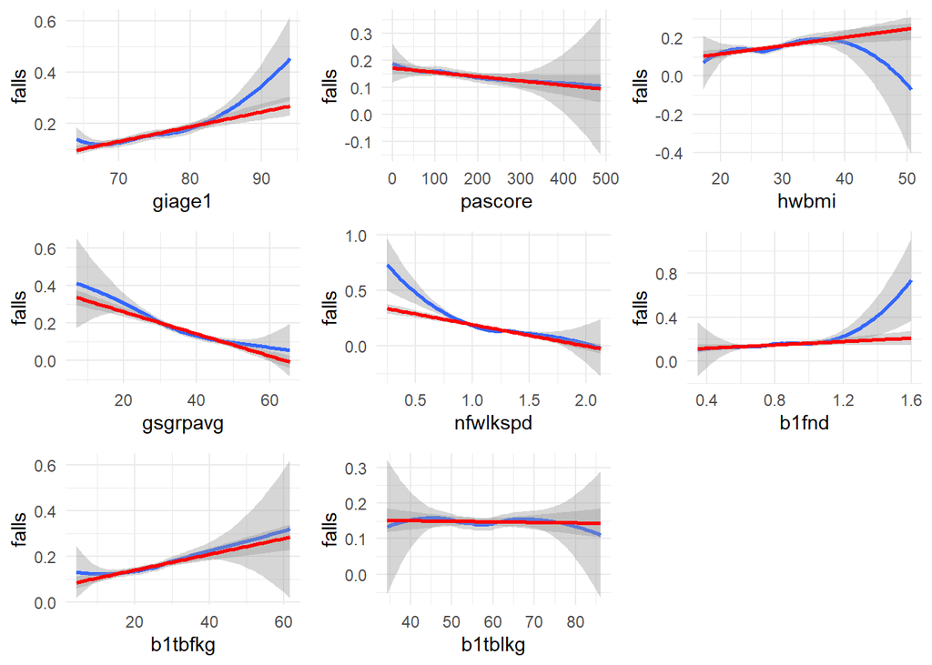

```r
# loess subject age
step3_narm1 = step3_narm1 %>% # #
  arrange(desc(giage1)) %>%
  map_df(rev)
gg1 <-
  ggplot(data = step3_narm1) +
  stat_smooth(mapping = aes(x = giage1, y = falls), method = "loess") +
  stat_smooth(mapping = aes(x = giage1, y = falls), method = "lm", color = "red") +
  theme_minimal()

# loess PACE score
step3_narm1 = step3_narm1 %>%
  arrange(desc(pascore)) %>%
  map_df(rev)
gg2 <-
  ggplot(data = step3_narm1) +
  stat_smooth(mapping = aes(x = pascore, y = falls), method = "loess") +
  stat_smooth(mapping = aes(x = pascore, y = falls), method = "lm", color = "red") +
  theme_minimal()

# loess BMI
step3_narm1 = step3_narm1 %>%
  arrange(desc(hwbmi)) %>%
  map_df(rev)
gg3 <-
  ggplot(data = step3_narm1) +
  stat_smooth(mapping = aes(x = hwbmi, y = falls), method = "loess") +
  stat_smooth(mapping = aes(x = hwbmi, y = falls), method = "lm", color = "red") +
  theme_minimal()

# loess grip strength
step3_narm1 = step3_narm1 %>%
  arrange(desc(gsgrpavg)) %>%
  map_df(rev)
gg4 <-
  ggplot(data = step3_narm1) +
  stat_smooth(mapping = aes(x = gsgrpavg, y = falls), method = "loess") +
  stat_smooth(mapping = aes(x = gsgrpavg, y = falls), method = "lm", color = "red") +
  theme_minimal()

# loess walk speed
step3_narm1 = step3_narm1 %>%
  arrange(desc(nfwlkspd)) %>%
  map_df(rev)
gg5 <-
  ggplot(data = step3_narm1) +
  stat_smooth(mapping = aes(x = nfwlkspd, y = falls), method = "loess") +
  stat_smooth(mapping = aes(x = nfwlkspd, y = falls), method = "lm", color = "red") +
  theme_minimal()

# loess corrected neck BMD
step3_narm1 = step3_narm1 %>%
  arrange(desc(b1fnd)) %>%
  map_df(rev)
gg6 <-
  ggplot(data = step3_narm1) +
  stat_smooth(mapping = aes(x = b1fnd, y = falls), method = "loess") +
  stat_smooth(mapping = aes(x = b1fnd, y = falls), method = "lm", color = "red") +
  theme_minimal()

# loess body fat mass
step3_narm1 = step3_narm1 %>%
  arrange(desc(b1tbfkg)) %>%
  map_df(rev)
gg7 <-
  ggplot(data = step3_narm1) +
  stat_smooth(mapping = aes(x = b1tbfkg, y = falls), method = "loess") +
  stat_smooth(mapping = aes(x = b1tbfkg, y = falls), method = "lm", color = "red") +
  theme_minimal()

# loess body lean mass
step3_narm1 = step3_narm1 %>%
  arrange(desc(b1tblkg)) %>%
  map_df(rev)
gg8 <-
  ggplot(data = step3_narm1) +
  stat_smooth(mapping = aes(x = b1tblkg, y = falls), method = "loess") +
  stat_smooth(mapping = aes(x = b1tblkg, y = falls), method = "lm", color = "red") +
  theme_minimal()

grid.arrange(gg1,
             gg2,
             gg3,
             gg4,
             gg5,
             gg6,
             gg7,
             gg8)
```

### Checking fractional polynomials

We’ll check the fractional polynomials for walk speed, corrected femoral neck bone mineral density, average left/right grip strength, BMI, and subject age.

```r
step4_model$call
```

```
## glm(formula = falls ~ giage1 + mhstrk + mhpark + mhcopd + mharth +
##     pascore + qlh + hwbmi + gsgrpavg + nfwlkspd + b1fnd + b1tbfkg +
##     b1tblkg, family = "binomial", data = step3_narm1)
```

```r
fracpoly_age <- mfp(
  falls ~ fp(giage1, df = 4) +
    mhstrk + mhpark + mhcopd + mharth +
    pascore + qlh + hwbmi + gsgrpavg + nfwlkspd + b1fnd +
    b1tbfkg + b1tblkg, data = step3_narm1,
  family = binomial(),
  alpha = 0.1,
  verbose = T # use ident for age
)
```

```
##
##  Variable    Deviance    Power(s)
## ------------------------------------------------
## Cycle 1
##  gsgrpavg
##              4078.379
##              4037.74     1
##
##
##
##  mharth
##              4058.791
##              4037.74     1
##
##
##
##  mhpark
##              4055.444
##              4037.74     1
##
##
##
##  b1tbfkg
##              4053.122
##              4037.74     1
##
##
##
##  mhcopd
##              4051.007
##              4037.74     1
##
##
##
##  giage1
##              4047.132
##              4037.74     1
##              4036.424    3
##              4032.985    -2 2
##
```

[output cut: 83 more lines]

```
## pascore            pascore
## qlh                    qlh
## hwbmi                hwbmi
## gsgrpavg          gsgrpavg
## nfwlkspd          nfwlkspd
## b1fnd                b1fnd
## b1tbfkg            b1tbfkg
## b1tblkg            b1tblkg
##
##
## Deviance table:
##           Resid. Dev
## Null model    4274.221
## Linear model  4037.74
## Final model   4037.74
```

```r
# frac_PACEscore <- mfp(
#   falls ~ fp(pascore, df = 4) +
#     giage1 + mhstrk + mhpark + mhcopd + mharth +
#     qlh + hwbmi + gsgrpavg + nfwlkspd + b1fnd +
#     b1tbfkg + b1tblkg, data = step3_narm1,
#   family = binomial(),
#   alpha = 0.1,
#   verbose = T # use ident for PACE score
# )

frac_BMI <- mfp(
  falls ~ fp(hwbmi, df = 4) +
    giage1 + mhstrk + pascore + mhpark + mhcopd + mharth +
    qlh + gsgrpavg + nfwlkspd + b1fnd +
    b1tbfkg + b1tblkg, data = step3_narm1,
  family = binomial(),
  alpha = 0.1,
  verbose = T # use ident for hwbmi
)
```

```
##
##  Variable    Deviance    Power(s)
## ------------------------------------------------
## Cycle 1
##  gsgrpavg
##              4078.379
##              4037.74     1
##
##
##
##  mharth
##              4058.791
##              4037.74     1
##
##
##
##  mhpark
##              4055.444
##              4037.74     1
##
##
##
##  b1tbfkg
##              4053.122
##              4037.74     1
##
##
##
##  mhcopd
##              4051.007
##              4037.74     1
##
##
##
##  giage1
##              4047.132
##              4037.74     1
##
##
##
```

[output cut: 83 more lines]

```
## mhcopd            mhcopd
## mharth            mharth
## qlh                  qlh
## gsgrpavg        gsgrpavg
## nfwlkspd        nfwlkspd
## b1fnd              b1fnd
## b1tbfkg          b1tbfkg
## b1tblkg          b1tblkg
##
##
## Deviance table:
##           Resid. Dev
## Null model    4274.221
## Linear model  4037.74
## Final model   4037.74
```

```r
frac_grip <- mfp(
  falls ~ fp(gsgrpavg, df = 4) +
    giage1 + mhstrk + pascore + mhpark + mhcopd + mharth +
    qlh + hwbmi + nfwlkspd + b1fnd +
    b1tbfkg + b1tblkg, data = step3_narm1,
  family = binomial(),
  alpha = 0.1,
  verbose = T # I((gsgrpavg/100)^-2)+I((gsgrpavg/100)^-2*log((gsgrpavg/100)))
)
```

```
##
##  Variable    Deviance    Power(s)
## ------------------------------------------------
## Cycle 1
##  gsgrpavg
##              4078.379
##              4037.74     1
##              4037.156    0.5
##              4031.277    -2 -2
##
##  mharth
##              4052.325
##              4031.277    1
##
##
##
##  mhpark
##              4048.67
##              4031.277    1
##
##
##
##  b1tbfkg
##              4047.745
##              4031.277    1
##
##
##
##  mhcopd
##              4044.216
##              4031.277    1
##
##
##
##  giage1
##              4040.189
##              4031.277    1
##
##
##
```

[output cut: 83 more lines]

```
## mhcopd                                                          mhcopd
## mharth                                                          mharth
## qlh                                                                qlh
## hwbmi                                                            hwbmi
## nfwlkspd                                                      nfwlkspd
## b1fnd                                                            b1fnd
## b1tbfkg                                                        b1tbfkg
## b1tblkg                                                        b1tblkg
##
##
## Deviance table:
##           Resid. Dev
## Null model    4274.221
## Linear model  4037.74
## Final model   4031.277
```

```r
frac_walkspeed <- mfp(
  falls ~ fp(nfwlkspd, df = 4) +
    giage1 + mhstrk + pascore + mhpark + mhcopd + mharth +
    qlh + hwbmi + gsgrpavg + b1fnd +
    b1tbfkg + b1tblkg, data = step3_narm1,
  family = binomial(),
  alpha = 0.1,
  verbose = T # inverse square for nfwlkspd
)
```

```
##
##  Variable    Deviance    Power(s)
## ------------------------------------------------
## Cycle 1
##  gsgrpavg
##              4078.379
##              4037.74     1
##
##
##
##  mharth
##              4058.791
##              4037.74     1
##
##
##
##  mhpark
##              4055.444
##              4037.74     1
##
##
##
##  b1tbfkg
##              4053.122
##              4037.74     1
##
##
##
##  mhcopd
##              4051.007
##              4037.74     1
##
##
##
##  giage1
##              4047.132
##              4037.74     1
##
##
##
```

[output cut: 126 more lines]

```
## mhcopd           mhcopd
## mharth           mharth
## qlh                 qlh
## hwbmi             hwbmi
## gsgrpavg       gsgrpavg
## b1fnd             b1fnd
## b1tbfkg         b1tbfkg
## b1tblkg         b1tblkg
##
##
## Deviance table:
##           Resid. Dev
## Null model    4274.221
## Linear model  4037.74
## Final model   4029.636
```

```r
frac_neckBMD <- mfp(
  falls ~ fp(b1fnd, df = 4) +
    giage1 + mhstrk + pascore + mhpark + mhcopd + mharth +
    qlh + hwbmi + gsgrpavg + nfwlkspd +
    b1tbfkg + b1tblkg, data = step3_narm1,
  family = binomial(),
  alpha = 0.1,
  verbose = T # idnet for b1fnd
)
```

```
##
##  Variable    Deviance    Power(s)
## ------------------------------------------------
## Cycle 1
##  gsgrpavg
##              4078.379
##              4037.74     1
##
##
##
##  mharth
##              4058.791
##              4037.74     1
##
##
##
##  mhpark
##              4055.444
##              4037.74     1
##
##
##
##  b1tbfkg
##              4053.122
##              4037.74     1
##
##
##
##  mhcopd
##              4051.007
##              4037.74     1
##
##
##
##  giage1
##              4047.132
##              4037.74     1
##
##
##
```

[output cut: 83 more lines]

```
## mhcopd       mhcopd
## mharth       mharth
## qlh             qlh
## hwbmi         hwbmi
## gsgrpavg   gsgrpavg
## nfwlkspd   nfwlkspd
## b1tbfkg     b1tbfkg
## b1tblkg     b1tblkg
##
##
## Deviance table:
##           Resid. Dev
## Null model    4274.221
## Linear model  4037.74
## Final model   4037.74
```

```r
frac_fatMass <- mfp(
  falls ~ fp(b1tbfkg, df = 4) +
    giage1 + mhstrk + pascore + mhpark + mhcopd + mharth +
    qlh + hwbmi + gsgrpavg + nfwlkspd +
    b1fnd + b1tblkg, data = step3_narm1,
  family = binomial(),
  alpha = 0.1,
  verbose = T # idnet for b1tbfkg
)
```

```
##
##  Variable    Deviance    Power(s)
## ------------------------------------------------
## Cycle 1
##  gsgrpavg
##              4078.379
##              4037.74     1
##
##
##
##  mharth
##              4058.791
##              4037.74     1
##
##
##
##  mhpark
##              4055.444
##              4037.74     1
##
##
##
##  b1tbfkg
##              4053.122
##              4037.74     1
##              4037.74     1
##              4037.07     2 3
##
##  mhcopd
##              4051.007
##              4037.74     1
##
##
##
##  giage1
##              4047.132
##              4037.74     1
##
##
##
```

[output cut: 83 more lines]

```
## mhcopd              mhcopd
## mharth              mharth
## qlh                    qlh
## hwbmi                hwbmi
## gsgrpavg          gsgrpavg
## nfwlkspd          nfwlkspd
## b1fnd                b1fnd
## b1tblkg            b1tblkg
##
##
## Deviance table:
##           Resid. Dev
## Null model    4274.221
## Linear model  4037.74
## Final model   4037.74
```

```r
frac_fatMass <- mfp(
  falls ~ fp(b1tblkg, df = 4) +
    giage1 + mhstrk + pascore + mhpark + mhcopd + mharth +
    qlh + hwbmi + gsgrpavg + nfwlkspd +
    b1fnd + b1tbfkg, data = step3_narm1,
  family = binomial(),
  alpha = 0.1,
  verbose = T # idnet for b1tblkg
)
```

```
##
##  Variable    Deviance    Power(s)
## ------------------------------------------------
## Cycle 1
##  gsgrpavg
##              4078.379
##              4037.74     1
##
##
##
##  mharth
##              4058.791
##              4037.74     1
##
##
##
##  mhpark
##              4055.444
##              4037.74     1
##
##
##
##  b1tbfkg
##              4053.122
##              4037.74     1
##
##
##
##  mhcopd
##              4051.007
##              4037.74     1
##
##
##
##  giage1
##              4047.132
##              4037.74     1
##
##
##
```

[output cut: 83 more lines]

```
## mhcopd               mhcopd
## mharth               mharth
## qlh                     qlh
## hwbmi                 hwbmi
## gsgrpavg           gsgrpavg
## nfwlkspd           nfwlkspd
## b1fnd                 b1fnd
## b1tbfkg             b1tbfkg
##
##
## Deviance table:
##           Resid. Dev
## Null model    4274.221
## Linear model  4037.74
## Final model   4037.74
```

### Creating transformed variables

```r
step4_narm <- step3_narm1 %>%
  mutate(inv_sq_walk = nfwlkspd^-2) %>%
  mutate(
    grip_trform =
      (gsgrpavg/100)^-2 + ((gsgrpavg/100)^-2 * log(gsgrpavg/100)))
```

### Visualizing transformed variables

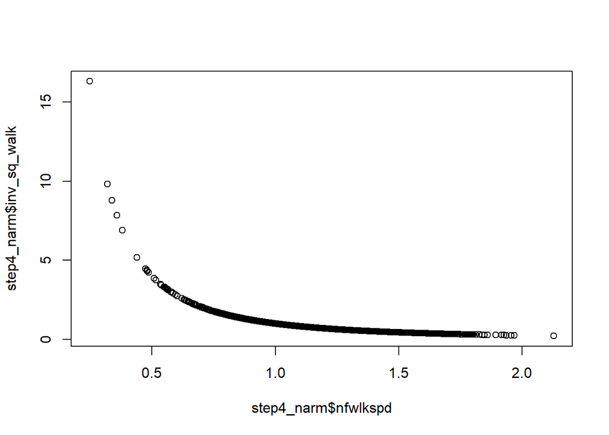

```r
plot(step4_narm$nfwlkspd, step4_narm$inv_sq_walk)
```

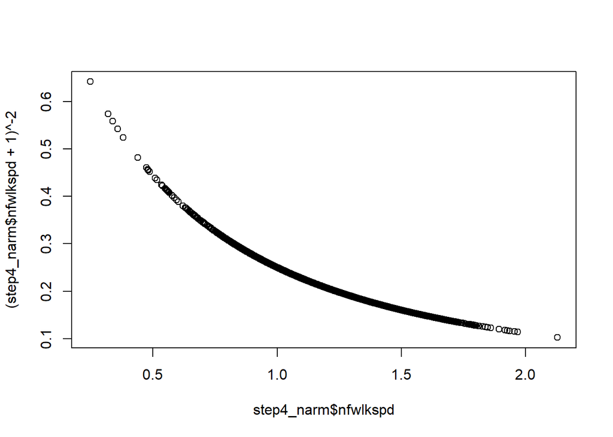

```r
plot(step4_narm$nfwlkspd, (step4_narm$nfwlkspd+1)^-2)
```

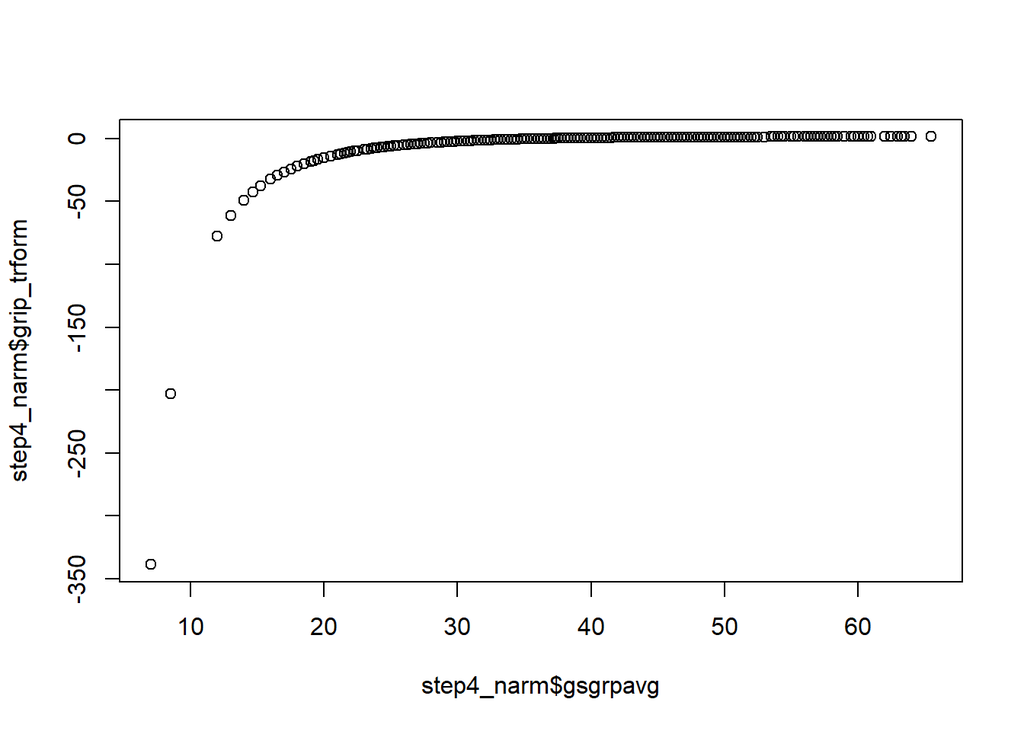

```r
plot(step4_narm$gsgrpavg,step4_narm$grip_trform)
```

From the above plots, we can formulate an offseted transformation of inverse squared walking speed, which decreases the disproportionate values given to small absolute values of walking speed:

```r
step4_narm <- step4_narm %>%
  mutate(offsetinv_sq_walk = (nfwlkspd+1)^-2)
```

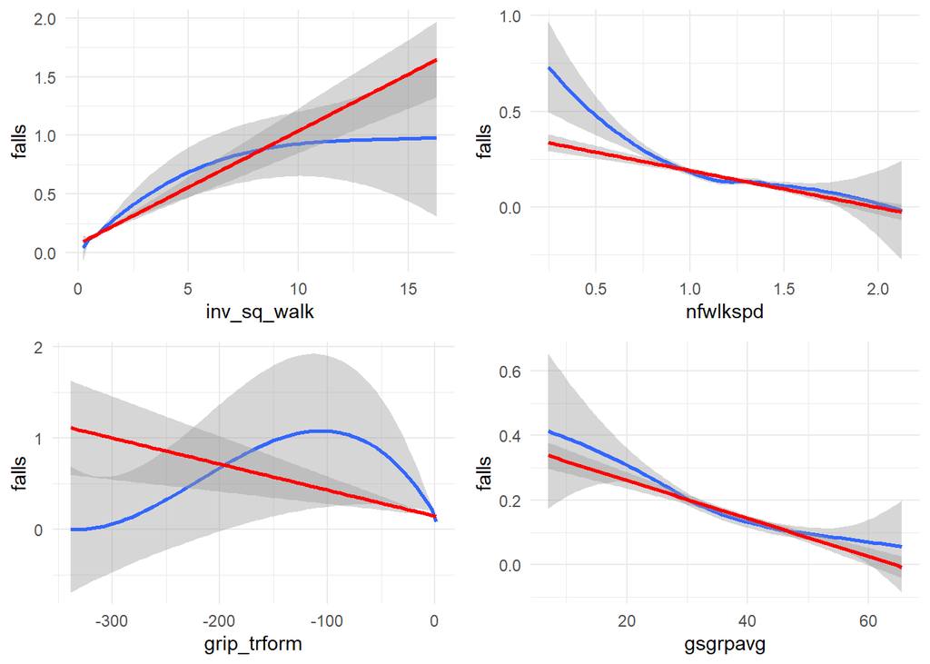

```r
step4_narm = step4_narm %>%
  arrange(desc(inv_sq_walk)) %>%
  map_df(rev)
gg9 <-
  ggplot(data = step4_narm) +
  stat_smooth(mapping = aes(x = inv_sq_walk, y = falls), method = "loess") +
  stat_smooth(mapping = aes(x = inv_sq_walk, y = falls), method = "lm", color = "red") +
  theme_minimal()


step4_narm = step4_narm %>%
  arrange(desc(grip_trform)) %>%
  map_df(rev)
gg10 <-
  ggplot(data = step4_narm) +
  stat_smooth(mapping = aes(x = grip_trform, y = falls), method = "loess") +
  stat_smooth(mapping = aes(x = grip_trform, y = falls), method = "lm", color = "red") +
  theme_minimal()

grid.arrange(gg9, gg5, gg10, gg4)
```

```r
step4_model$call
```

```
## glm(formula = falls ~ giage1 + mhstrk + mhpark + mhcopd + mharth +
##     pascore + qlh + hwbmi + gsgrpavg + nfwlkspd + b1fnd + b1tbfkg +
##     b1tblkg, family = "binomial", data = step3_narm1)
```

```r
summary(step4_model)$coef # without transformations
```

```
##                 Estimate   Std. Error   z value     Pr(>|z|)
## (Intercept) -2.603372408 0.9563516254 -2.722192 6.485052e-03
## giage1       0.025140758 0.0081895108  3.069873 2.141498e-03
## mhstrk       0.301647522 0.1628266514  1.852568 6.394423e-02
## mhpark       1.618930925 0.3697138706  4.378875 1.192934e-05
## mhcopd       0.451069377 0.1204304576  3.745476 1.800521e-04
## mharth       0.384990347 0.0841367768  4.575768 4.744768e-06
## pascore      0.001143792 0.0006300872  1.815291 6.947915e-02
## qlh          0.322746343 0.1153725017  2.797429 5.151114e-03
## hwbmi       -0.073355050 0.0242189021 -3.028835 2.454990e-03
## gsgrpavg    -0.039507594 0.0062236393 -6.347989 2.181476e-10
## nfwlkspd    -0.636315533 0.2103364029 -3.025228 2.484459e-03
## b1fnd        0.984569397 0.3373304990  2.918709 3.514847e-03
## b1tbfkg      0.043484761 0.0110869386  3.922161 8.775821e-05
## b1tblkg      0.018296076 0.0088195514  2.074491 3.803378e-02
```

```r
step5_model1 <- glm(
  formula = falls ~ giage1 + mhstrk + mhpark + mhcopd + mharth +
    pascore + qlh + hwbmi + gsgrpavg + inv_sq_walk + b1fnd +
    b1tbfkg + b1tblkg,
  family = "binomial",
  data = step4_narm)

step5_model2 <- glm(
  formula = falls ~ giage1 + mhstrk + mhpark + mhcopd + mharth +
    pascore + qlh + hwbmi + grip_trform + inv_sq_walk + b1fnd +
    b1tbfkg + b1tblkg,
  family = "binomial",
  data = step4_narm)

step5_model3 <- glm(
  formula = falls ~ giage1 + mhstrk + mhpark + mhcopd + mharth +
    pascore + qlh + hwbmi + gsgrpavg + nfwlkspd + b1fnd +
    b1tbfkg + b1tblkg,
  family = "binomial",
  data = step4_narm)

step5_model4 <- glm(
  formula = falls ~ giage1 + mhstrk + mhpark + mhcopd + mharth +
    pascore + qlh + hwbmi + gsgrpavg + offsetinv_sq_walk + b1fnd +
    b1tbfkg + b1tblkg,
  family = "binomial",
  data = step4_narm)

summary(step5_model1)$coef
```

```
##                 Estimate   Std. Error   z value     Pr(>|z|)
## (Intercept) -3.655476545 0.8622491548 -4.239467 2.240515e-05
## giage1       0.025910809 0.0080776930  3.207699 1.338014e-03
## mhstrk       0.314877369 0.1628795256  1.933192 5.321257e-02
## mhpark       1.608457365 0.3738094170  4.302881 1.685916e-05
## mhcopd       0.458829234 0.1204820610  3.808278 1.399377e-04
## mharth       0.385600207 0.0841637031  4.581550 4.615424e-06
## pascore      0.001190304 0.0006300573  1.889199 5.886516e-02
## qlh          0.310048930 0.1158407517  2.676510 7.439335e-03
## hwbmi       -0.077480518 0.0243399888 -3.183260 1.456267e-03
## gsgrpavg    -0.039688221 0.0062068220 -6.394290 1.612948e-10
## inv_sq_walk  0.329280347 0.0874846580  3.763864 1.673080e-04
## b1fnd        0.991873642 0.3380155264  2.934403 3.341904e-03
## b1tbfkg      0.045946167 0.0111285174  4.128687 3.648404e-05
## b1tblkg      0.018749315 0.0088357703  2.121979 3.383954e-02
```

```r
summary(step5_model2)$coef
```

```
##                  Estimate   Std. Error    z value     Pr(>|z|)
## (Intercept) -5.4122348264 0.8216797017 -6.5867939 4.494255e-11
## giage1       0.0373242258 0.0078957211  4.7271459 2.276976e-06
## mhstrk       0.3385558123 0.1624902667  2.0835452 3.720156e-02
## mhpark       1.7018466026 0.3756791262  4.5300537 5.896871e-06
## mhcopd       0.4468274522 0.1197035101  3.7327849 1.893743e-04
## mharth       0.4312030948 0.0835952970  5.1582219 2.493060e-07
## pascore      0.0008894403 0.0006278547  1.4166340 1.565900e-01
## qlh          0.3209934172 0.1154609104  2.7801047 5.434138e-03
## hwbmi       -0.0541584439 0.0239776520 -2.2587051 2.390174e-02
## grip_trform -0.0059828929 0.0055649152 -1.0751095 2.823257e-01
## inv_sq_walk  0.3822300898 0.0901284942  4.2409461 2.225795e-05
## b1fnd        0.9509848192 0.3368614931  2.8230737 4.756564e-03
## b1tbfkg      0.0457854757 0.0111054038  4.1228105 3.742775e-05
## b1tblkg     -0.0028217370 0.0081707661 -0.3453455 7.298347e-01
```

```r
summary(step5_model3)$coef
```

```
##                 Estimate   Std. Error   z value     Pr(>|z|)
## (Intercept) -2.603372408 0.9563516254 -2.722192 6.485052e-03
## giage1       0.025140758 0.0081895108  3.069873 2.141498e-03
## mhstrk       0.301647522 0.1628266514  1.852568 6.394423e-02
## mhpark       1.618930925 0.3697138706  4.378875 1.192934e-05
## mhcopd       0.451069377 0.1204304576  3.745476 1.800521e-04
## mharth       0.384990347 0.0841367768  4.575768 4.744768e-06
## pascore      0.001143792 0.0006300872  1.815291 6.947915e-02
## qlh          0.322746343 0.1153725017  2.797429 5.151114e-03
## hwbmi       -0.073355050 0.0242189021 -3.028835 2.454990e-03
## gsgrpavg    -0.039507594 0.0062236393 -6.347989 2.181476e-10
## nfwlkspd    -0.636315533 0.2103364029 -3.025228 2.484459e-03
## b1fnd        0.984569397 0.3373304990  2.918709 3.514847e-03
## b1tbfkg      0.043484761 0.0110869386  3.922161 8.775821e-05
## b1tblkg      0.018296076 0.0088195514  2.074491 3.803378e-02
```

```r
summary(step5_model4)$coef
```

```
##                       Estimate   Std. Error   z value     Pr(>|z|)
## (Intercept)       -4.014656409 0.8599357322 -4.668554 3.033270e-06
## giage1             0.024233835 0.0081657444  2.967743 2.999946e-03
## mhstrk             0.299398859 0.1629957140  1.836851 6.623188e-02
## mhpark             1.604294299 0.3714403301  4.319117 1.566546e-05
## mhcopd             0.452475024 0.1205081163  3.754727 1.735308e-04
## mharth             0.382449378 0.0841963251  4.542352 5.562995e-06
## pascore            0.001197172 0.0006302949  1.899384 5.751394e-02
## qlh                0.305943309 0.1158710717  2.640377 8.281386e-03
## hwbmi             -0.076204826 0.0242717658 -3.139649 1.691503e-03
## gsgrpavg          -0.039050897 0.0062202641 -6.278013 3.429280e-10
## offsetinv_sq_walk  3.431448884 0.9186412938  3.735352 1.874526e-04
## b1fnd              0.988708073 0.3375463018  2.929104 3.399411e-03
## b1tbfkg            0.044360126 0.0110904169  3.999861 6.337970e-05
## b1tblkg            0.018584759 0.0088285333  2.105079 3.528444e-02
```

```r
summary(step4_model)$deviance
```

```
## [1] 4037.74
```

```r
summary(step5_model1)$deviance
```

```
## [1] 4029.636
```

```r
summary(step5_model2)$deviance
```

```
## [1] 4069.507
```

```r
summary(step5_model3)$deviance
```

```
## [1] 4037.74
```

```r
summary(step5_model4)$deviance
```

```
## [1] 4033.275
```

### Step 5 model

```r
step5_model <- step5_model1
summary(step5_model)$coef
```

```
##                 Estimate   Std. Error   z value     Pr(>|z|)
## (Intercept) -3.655476545 0.8622491548 -4.239467 2.240515e-05
## giage1       0.025910809 0.0080776930  3.207699 1.338014e-03
## mhstrk       0.314877369 0.1628795256  1.933192 5.321257e-02
## mhpark       1.608457365 0.3738094170  4.302881 1.685916e-05
## mhcopd       0.458829234 0.1204820610  3.808278 1.399377e-04
## mharth       0.385600207 0.0841637031  4.581550 4.615424e-06
## pascore      0.001190304 0.0006300573  1.889199 5.886516e-02
## qlh          0.310048930 0.1158407517  2.676510 7.439335e-03
## hwbmi       -0.077480518 0.0243399888 -3.183260 1.456267e-03
## gsgrpavg    -0.039688221 0.0062068220 -6.394290 1.612948e-10
## inv_sq_walk  0.329280347 0.0874846580  3.763864 1.673080e-04
## b1fnd        0.991873642 0.3380155264  2.934403 3.341904e-03
## b1tbfkg      0.045946167 0.0111285174  4.128687 3.648404e-05
## b1tblkg      0.018749315 0.0088357703  2.121979 3.383954e-02
```

## Step 6: Exploring Interactions

### Creating the interaction models

```r
EMM1 <-
  glm(formula = falls ~ giage1 + mhstrk + mhpark + mhcopd + mharth +
    pascore + qlh + hwbmi + gsgrpavg + inv_sq_walk + b1fnd +
    b1tbfkg + b1tblkg + giage1*mhstrk,    family = "binomial",   data = step4_narm)
EMM2 <-
  glm(formula = falls ~ giage1 + mhstrk + mhpark + mhcopd + mharth +
    pascore + qlh + hwbmi + gsgrpavg + inv_sq_walk + b1fnd +
    b1tbfkg + b1tblkg + giage1*mhpark,    family = "binomial",   data = step4_narm)
EMM3 <-
  glm(formula = falls ~ giage1 + mhstrk + mhpark + mhcopd + mharth +
    pascore + qlh + hwbmi + gsgrpavg + inv_sq_walk + b1fnd +
    b1tbfkg + b1tblkg + giage1*mhcopd,    family = "binomial",   data = step4_narm)
EMM4 <-
  glm(formula = falls ~ giage1 + mhstrk + mhpark + mhcopd + mharth +
    pascore + qlh + hwbmi + gsgrpavg + inv_sq_walk + b1fnd +
    b1tbfkg + b1tblkg + giage1*mharth,    family = "binomial",   data = step4_narm)
EMM5 <-
  glm(formula = falls ~ giage1 + mhstrk + mhpark + mhcopd + mharth +
    pascore + qlh + hwbmi + gsgrpavg + inv_sq_walk + b1fnd +
    b1tbfkg + b1tblkg + giage1*pascore,    family = "binomial",   data = step4_narm)
EMM6 <-
  glm(formula = falls ~ giage1 + mhstrk + mhpark + mhcopd + mharth +
    pascore + qlh + hwbmi + gsgrpavg + inv_sq_walk + b1fnd +
    b1tbfkg + b1tblkg + giage1*qlh,    family = "binomial",   data = step4_narm)
EMM7 <-
  glm(formula = falls ~ giage1 + mhstrk + mhpark + mhcopd + mharth +
    pascore + qlh + hwbmi + gsgrpavg + inv_sq_walk + b1fnd +
    b1tbfkg + b1tblkg + giage1*hwbmi,    family = "binomial",   data = step4_narm)
EMM8 <-
  glm(formula = falls ~ giage1 + mhstrk + mhpark + mhcopd + mharth +
    pascore + qlh + hwbmi + gsgrpavg + inv_sq_walk + b1fnd +
    b1tbfkg + b1tblkg + giage1*gsgrpavg,    family = "binomial",   data = step4_narm)
EMM9 <-
  glm(formula = falls ~ giage1 + mhstrk + mhpark + mhcopd + mharth +
    pascore + qlh + hwbmi + gsgrpavg + inv_sq_walk + b1fnd +
    b1tbfkg + b1tblkg + giage1*inv_sq_walk,    family = "binomial",   data = step4_narm)
EMM10 <-
  glm(formula = falls ~ giage1 + mhstrk + mhpark + mhcopd + mharth +
    pascore + qlh + hwbmi + gsgrpavg + inv_sq_walk + b1fnd +
    b1tbfkg + b1tblkg + giage1*b1fnd,    family = "binomial",   data = step4_narm)
EMM11 <-
  glm(formula = falls ~ giage1 + mhstrk + mhpark + mhcopd + mharth +
    pascore + qlh + hwbmi + gsgrpavg + inv_sq_walk + b1fnd +
    b1tbfkg + b1tblkg + giage1*b1tbfkg,    family = "binomial",   data = step4_narm)
EMM12 <-
  glm(formula = falls ~ giage1 + mhstrk + mhpark + mhcopd + mharth +
    pascore + qlh + hwbmi + gsgrpavg + inv_sq_walk + b1fnd +
    b1tbfkg + b1tblkg + giage1*b1tblkg,    family = "binomial",   data = step4_narm)
EMM13 <-
  glm(formula = falls ~ giage1 + mhstrk + mhpark + mhcopd + mharth +
    pascore + qlh + hwbmi + gsgrpavg + inv_sq_walk + b1fnd +
    b1tbfkg + b1tblkg + mhstrk*mhpark,    family = "binomial",   data = step4_narm)
EMM14 <-
  glm(formula = falls ~ giage1 + mhstrk + mhpark + mhcopd + mharth +
    pascore + qlh + hwbmi + gsgrpavg + inv_sq_walk + b1fnd +
    b1tbfkg + b1tblkg + mhstrk*mhcopd,    family = "binomial",   data = step4_narm)
EMM15 <-
  glm(formula = falls ~ giage1 + mhstrk + mhpark + mhcopd + mharth +
    pascore + qlh + hwbmi + gsgrpavg + inv_sq_walk + b1fnd +
    b1tbfkg + b1tblkg + mhstrk*mharth,    family = "binomial",   data = step4_narm)
EMM16 <-
  glm(formula = falls ~ giage1 + mhstrk + mhpark + mhcopd + mharth +
    pascore + qlh + hwbmi + gsgrpavg + inv_sq_walk + b1fnd +
    b1tbfkg + b1tblkg + mhstrk*pascore,    family = "binomial",   data = step4_narm)
EMM17 <-
  glm(formula = falls ~ giage1 + mhstrk + mhpark + mhcopd + mharth +
    pascore + qlh + hwbmi + gsgrpavg + inv_sq_walk + b1fnd +
    b1tbfkg + b1tblkg + mhstrk*qlh,    family = "binomial",   data = step4_narm)
EMM18 <-
  glm(formula = falls ~ giage1 + mhstrk + mhpark + mhcopd + mharth +
    pascore + qlh + hwbmi + gsgrpavg + inv_sq_walk + b1fnd +
    b1tbfkg + b1tblkg + mhstrk*hwbmi,    family = "binomial",   data = step4_narm)
EMM19 <-
  glm(formula = falls ~ giage1 + mhstrk + mhpark + mhcopd + mharth +
    pascore + qlh + hwbmi + gsgrpavg + inv_sq_walk + b1fnd +
    b1tbfkg + b1tblkg + mhstrk*gsgrpavg,    family = "binomial",   data = step4_narm)
EMM20 <-
  glm(formula = falls ~ giage1 + mhstrk + mhpark + mhcopd + mharth +
    pascore + qlh + hwbmi + gsgrpavg + inv_sq_walk + b1fnd +
    b1tbfkg + b1tblkg + mhstrk*inv_sq_walk,    family = "binomial",   data = step4_narm)
EMM21 <-
  glm(formula = falls ~ giage1 + mhstrk + mhpark + mhcopd + mharth +
    pascore + qlh + hwbmi + gsgrpavg + inv_sq_walk + b1fnd +
    b1tbfkg + b1tblkg + mhstrk*b1fnd,    family = "binomial",   data = step4_narm)
EMM22 <-
  glm(formula = falls ~ giage1 + mhstrk + mhpark + mhcopd + mharth +
    pascore + qlh + hwbmi + gsgrpavg + inv_sq_walk + b1fnd +
    b1tbfkg + b1tblkg + mhstrk*b1tbfkg,    family = "binomial",   data = step4_narm)
EMM23 <-
  glm(formula = falls ~ giage1 + mhstrk + mhpark + mhcopd + mharth +
    pascore + qlh + hwbmi + gsgrpavg + inv_sq_walk + b1fnd +
    b1tbfkg + b1tblkg + mhstrk*b1tblkg,    family = "binomial",   data = step4_narm)
EMM24 <-
  glm(formula = falls ~ giage1 + mhstrk + mhpark + mhcopd + mharth +
    pascore + qlh + hwbmi + gsgrpavg + inv_sq_walk + b1fnd +
    b1tbfkg + b1tblkg + mhpark*mhcopd,    family = "binomial",   data = step4_narm)
EMM25 <-
  glm(formula = falls ~ giage1 + mhstrk + mhpark + mhcopd + mharth +
    pascore + qlh + hwbmi + gsgrpavg + inv_sq_walk + b1fnd +
    b1tbfkg + b1tblkg + mhpark*mharth,    family = "binomial",   data = step4_narm)
EMM26 <-
  glm(formula = falls ~ giage1 + mhstrk + mhpark + mhcopd + mharth +
    pascore + qlh + hwbmi + gsgrpavg + inv_sq_walk + b1fnd +
    b1tbfkg + b1tblkg + mhpark*pascore,    family = "binomial",   data = step4_narm)
EMM27 <-
  glm(formula = falls ~ giage1 + mhstrk + mhpark + mhcopd + mharth +
    pascore + qlh + hwbmi + gsgrpavg + inv_sq_walk + b1fnd +
    b1tbfkg + b1tblkg + mhpark*qlh,    family = "binomial",   data = step4_narm)
EMM28 <-
  glm(formula = falls ~ giage1 + mhstrk + mhpark + mhcopd + mharth +
    pascore + qlh + hwbmi + gsgrpavg + inv_sq_walk + b1fnd +
    b1tbfkg + b1tblkg + mhpark*hwbmi,    family = "binomial",   data = step4_narm)
EMM29 <-
  glm(formula = falls ~ giage1 + mhstrk + mhpark + mhcopd + mharth +
    pascore + qlh + hwbmi + gsgrpavg + inv_sq_walk + b1fnd +
    b1tbfkg + b1tblkg + mhpark*gsgrpavg,    family = "binomial",   data = step4_narm)
EMM30 <-
  glm(formula = falls ~ giage1 + mhstrk + mhpark + mhcopd + mharth +
    pascore + qlh + hwbmi + gsgrpavg + inv_sq_walk + b1fnd +
    b1tbfkg + b1tblkg + mhpark*inv_sq_walk,    family = "binomial",   data = step4_narm)
EMM31 <-
  glm(formula = falls ~ giage1 + mhstrk + mhpark + mhcopd + mharth +
    pascore + qlh + hwbmi + gsgrpavg + inv_sq_walk + b1fnd +
    b1tbfkg + b1tblkg + mhpark*b1fnd,    family = "binomial",   data = step4_narm)
EMM32 <-
  glm(formula = falls ~ giage1 + mhstrk + mhpark + mhcopd + mharth +
    pascore + qlh + hwbmi + gsgrpavg + inv_sq_walk + b1fnd +
    b1tbfkg + b1tblkg + mhpark*b1tbfkg,    family = "binomial",   data = step4_narm)
EMM33 <-
  glm(formula = falls ~ giage1 + mhstrk + mhpark + mhcopd + mharth +
    pascore + qlh + hwbmi + gsgrpavg + inv_sq_walk + b1fnd +
    b1tbfkg + b1tblkg + mhpark*b1tblkg,    family = "binomial",   data = step4_narm)
EMM34 <-
  glm(formula = falls ~ giage1 + mhstrk + mhpark + mhcopd + mharth +
    pascore + qlh + hwbmi + gsgrpavg + inv_sq_walk + b1fnd +
    b1tbfkg + b1tblkg + mhcopd*mharth,    family = "binomial",   data = step4_narm)
EMM35 <-
  glm(formula = falls ~ giage1 + mhstrk + mhpark + mhcopd + mharth +
    pascore + qlh + hwbmi + gsgrpavg + inv_sq_walk + b1fnd +
    b1tbfkg + b1tblkg + mhcopd*pascore,    family = "binomial",   data = step4_narm)
EMM36 <-
  glm(formula = falls ~ giage1 + mhstrk + mhpark + mhcopd + mharth +
    pascore + qlh + hwbmi + gsgrpavg + inv_sq_walk + b1fnd +
    b1tbfkg + b1tblkg + mhcopd*qlh,    family = "binomial",   data = step4_narm)
EMM37 <-
  glm(formula = falls ~ giage1 + mhstrk + mhpark + mhcopd + mharth +
    pascore + qlh + hwbmi + gsgrpavg + inv_sq_walk + b1fnd +
    b1tbfkg + b1tblkg + mhcopd*hwbmi,    family = "binomial",   data = step4_narm)
EMM38 <-
  glm(formula = falls ~ giage1 + mhstrk + mhpark + mhcopd + mharth +
    pascore + qlh + hwbmi + gsgrpavg + inv_sq_walk + b1fnd +
    b1tbfkg + b1tblkg + mhcopd*gsgrpavg,    family = "binomial",   data = step4_narm)
EMM39 <-
  glm(formula = falls ~ giage1 + mhstrk + mhpark + mhcopd + mharth +
    pascore + qlh + hwbmi + gsgrpavg + inv_sq_walk + b1fnd +
    b1tbfkg + b1tblkg + mhcopd*inv_sq_walk,    family = "binomial",   data = step4_narm)
EMM40 <-
  glm(formula = falls ~ giage1 + mhstrk + mhpark + mhcopd + mharth +
    pascore + qlh + hwbmi + gsgrpavg + inv_sq_walk + b1fnd +
    b1tbfkg + b1tblkg + mhcopd*b1fnd,    family = "binomial",   data = step4_narm)
EMM41 <-
  glm(formula = falls ~ giage1 + mhstrk + mhpark + mhcopd + mharth +
    pascore + qlh + hwbmi + gsgrpavg + inv_sq_walk + b1fnd +
    b1tbfkg + b1tblkg + mhcopd*b1tbfkg,    family = "binomial",   data = step4_narm)
EMM42 <-
  glm(formula = falls ~ giage1 + mhstrk + mhpark + mhcopd + mharth +
    pascore + qlh + hwbmi + gsgrpavg + inv_sq_walk + b1fnd +
    b1tbfkg + b1tblkg + mhcopd*b1tblkg,    family = "binomial",   data = step4_narm)
EMM43 <-
  glm(formula = falls ~ giage1 + mhstrk + mhpark + mhcopd + mharth +
    pascore + qlh + hwbmi + gsgrpavg + inv_sq_walk + b1fnd +
    b1tbfkg + b1tblkg + mharth*pascore,    family = "binomial",   data = step4_narm)
EMM44 <-
  glm(formula = falls ~ giage1 + mhstrk + mhpark + mhcopd + mharth +
    pascore + qlh + hwbmi + gsgrpavg + inv_sq_walk + b1fnd +
    b1tbfkg + b1tblkg + mharth*qlh,    family = "binomial",   data = step4_narm)
EMM45 <-
  glm(formula = falls ~ giage1 + mhstrk + mhpark + mhcopd + mharth +
    pascore + qlh + hwbmi + gsgrpavg + inv_sq_walk + b1fnd +
    b1tbfkg + b1tblkg + mharth*hwbmi,    family = "binomial",   data = step4_narm)
EMM46 <-
  glm(formula = falls ~ giage1 + mhstrk + mhpark + mhcopd + mharth +
    pascore + qlh + hwbmi + gsgrpavg + inv_sq_walk + b1fnd +
    b1tbfkg + b1tblkg + mharth*gsgrpavg,    family = "binomial",   data = step4_narm)
EMM47 <-
  glm(formula = falls ~ giage1 + mhstrk + mhpark + mhcopd + mharth +
    pascore + qlh + hwbmi + gsgrpavg + inv_sq_walk + b1fnd +
    b1tbfkg + b1tblkg + mharth*inv_sq_walk,    family = "binomial",   data = step4_narm)
EMM48 <-
  glm(formula = falls ~ giage1 + mhstrk + mhpark + mhcopd + mharth +
    pascore + qlh + hwbmi + gsgrpavg + inv_sq_walk + b1fnd +
    b1tbfkg + b1tblkg + mharth*b1fnd,    family = "binomial",   data = step4_narm)
EMM49 <-
  glm(formula = falls ~ giage1 + mhstrk + mhpark + mhcopd + mharth +
    pascore + qlh + hwbmi + gsgrpavg + inv_sq_walk + b1fnd +
    b1tbfkg + b1tblkg + mharth*b1tbfkg,    family = "binomial",   data = step4_narm)
EMM50 <-
  glm(formula = falls ~ giage1 + mhstrk + mhpark + mhcopd + mharth +
    pascore + qlh + hwbmi + gsgrpavg + inv_sq_walk + b1fnd +
    b1tbfkg + b1tblkg + mharth*b1tblkg,    family = "binomial",   data = step4_narm)
EMM51 <-
  glm(formula = falls ~ giage1 + mhstrk + mhpark + mhcopd + mharth +
    pascore + qlh + hwbmi + gsgrpavg + inv_sq_walk + b1fnd +
    b1tbfkg + b1tblkg + pascore*qlh,    family = "binomial",   data = step4_narm)
EMM52 <-
  glm(formula = falls ~ giage1 + mhstrk + mhpark + mhcopd + mharth +
    pascore + qlh + hwbmi + gsgrpavg + inv_sq_walk + b1fnd +
    b1tbfkg + b1tblkg + pascore*hwbmi,    family = "binomial",   data = step4_narm)
EMM53 <-
  glm(formula = falls ~ giage1 + mhstrk + mhpark + mhcopd + mharth +
    pascore + qlh + hwbmi + gsgrpavg + inv_sq_walk + b1fnd +
    b1tbfkg + b1tblkg + pascore*gsgrpavg,    family = "binomial",   data = step4_narm)
EMM54 <-
  glm(formula = falls ~ giage1 + mhstrk + mhpark + mhcopd + mharth +
    pascore + qlh + hwbmi + gsgrpavg + inv_sq_walk + b1fnd +
    b1tbfkg + b1tblkg + pascore*inv_sq_walk,    family = "binomial",   data = step4_narm)
```

```r
EMM55 <-
  glm(formula = falls ~ giage1 + mhstrk + mhpark + mhcopd + mharth +
    pascore + qlh + hwbmi + gsgrpavg + inv_sq_walk + b1fnd +
    b1tbfkg + b1tblkg + pascore*b1fnd,    family = "binomial",   data = step4_narm)
EMM56 <-
  glm(formula = falls ~ giage1 + mhstrk + mhpark + mhcopd + mharth +
    pascore + qlh + hwbmi + gsgrpavg + inv_sq_walk + b1fnd +
    b1tbfkg + b1tblkg + pascore*b1tbfkg,    family = "binomial",   data = step4_narm)
EMM57 <-
  glm(formula = falls ~ giage1 + mhstrk + mhpark + mhcopd + mharth +
    pascore + qlh + hwbmi + gsgrpavg + inv_sq_walk + b1fnd +
    b1tbfkg + b1tblkg + pascore*b1tblkg,    family = "binomial",   data = step4_narm)
EMM58 <-
  glm(formula = falls ~ giage1 + mhstrk + mhpark + mhcopd + mharth +
    pascore + qlh + hwbmi + gsgrpavg + inv_sq_walk + b1fnd +
    b1tbfkg + b1tblkg + qlh*hwbmi,    family = "binomial",   data = step4_narm)
EMM59 <-
  glm(formula = falls ~ giage1 + mhstrk + mhpark + mhcopd + mharth +
    pascore + qlh + hwbmi + gsgrpavg + inv_sq_walk + b1fnd +
    b1tbfkg + b1tblkg + qlh*gsgrpavg,    family = "binomial",   data = step4_narm)
EMM60 <-
  glm(formula = falls ~ giage1 + mhstrk + mhpark + mhcopd + mharth +
    pascore + qlh + hwbmi + gsgrpavg + inv_sq_walk + b1fnd +
    b1tbfkg + b1tblkg + qlh*inv_sq_walk,    family = "binomial",   data = step4_narm)
EMM61 <-
  glm(formula = falls ~ giage1 + mhstrk + mhpark + mhcopd + mharth +
    pascore + qlh + hwbmi + gsgrpavg + inv_sq_walk + b1fnd +
    b1tbfkg + b1tblkg + qlh*b1fnd,    family = "binomial",   data = step4_narm)
EMM62 <-
  glm(formula = falls ~ giage1 + mhstrk + mhpark + mhcopd + mharth +
    pascore + qlh + hwbmi + gsgrpavg + inv_sq_walk + b1fnd +
    b1tbfkg + b1tblkg + qlh*b1tbfkg,    family = "binomial",   data = step4_narm)
EMM63 <-
  glm(formula = falls ~ giage1 + mhstrk + mhpark + mhcopd + mharth +
    pascore + qlh + hwbmi + gsgrpavg + inv_sq_walk + b1fnd +
    b1tbfkg + b1tblkg + qlh*b1tblkg,    family = "binomial",   data = step4_narm)
EMM64 <-
  glm(formula = falls ~ giage1 + mhstrk + mhpark + mhcopd + mharth +
    pascore + qlh + hwbmi + gsgrpavg + inv_sq_walk + b1fnd +
    b1tbfkg + b1tblkg + hwbmi*gsgrpavg,    family = "binomial",   data = step4_narm)
EMM65 <-
  glm(formula = falls ~ giage1 + mhstrk + mhpark + mhcopd + mharth +
    pascore + qlh + hwbmi + gsgrpavg + inv_sq_walk + b1fnd +
    b1tbfkg + b1tblkg + hwbmi*inv_sq_walk,    family = "binomial",   data = step4_narm)
EMM66 <-
  glm(formula = falls ~ giage1 + mhstrk + mhpark + mhcopd + mharth +
    pascore + qlh + hwbmi + gsgrpavg + inv_sq_walk + b1fnd +
    b1tbfkg + b1tblkg + hwbmi*b1fnd,    family = "binomial",   data = step4_narm)
EMM67 <-
  glm(formula = falls ~ giage1 + mhstrk + mhpark + mhcopd + mharth +
    pascore + qlh + hwbmi + gsgrpavg + inv_sq_walk + b1fnd +
    b1tbfkg + b1tblkg + hwbmi*b1tbfkg,    family = "binomial",   data = step4_narm)
EMM68 <-
  glm(formula = falls ~ giage1 + mhstrk + mhpark + mhcopd + mharth +
    pascore + qlh + hwbmi + gsgrpavg + inv_sq_walk + b1fnd +
    b1tbfkg + b1tblkg + hwbmi*b1tblkg,    family = "binomial",   data = step4_narm)
EMM69 <-
  glm(formula = falls ~ giage1 + mhstrk + mhpark + mhcopd + mharth +
    pascore + qlh + hwbmi + gsgrpavg + inv_sq_walk + b1fnd +
    b1tbfkg + b1tblkg + gsgrpavg*inv_sq_walk,    family = "binomial",   data = step4_narm)
EMM70 <-
  glm(formula = falls ~ giage1 + mhstrk + mhpark + mhcopd + mharth +
    pascore + qlh + hwbmi + gsgrpavg + inv_sq_walk + b1fnd +
    b1tbfkg + b1tblkg + gsgrpavg*b1fnd,    family = "binomial",   data = step4_narm)
EMM71 <-
  glm(formula = falls ~ giage1 + mhstrk + mhpark + mhcopd + mharth +
    pascore + qlh + hwbmi + gsgrpavg + inv_sq_walk + b1fnd +
    b1tbfkg + b1tblkg + gsgrpavg*b1tbfkg,    family = "binomial",   data = step4_narm)
EMM72 <-
  glm(formula = falls ~ giage1 + mhstrk + mhpark + mhcopd + mharth +
    pascore + qlh + hwbmi + gsgrpavg + inv_sq_walk + b1fnd +
    b1tbfkg + b1tblkg + gsgrpavg*b1tblkg,    family = "binomial",   data = step4_narm)
EMM73 <-
  glm(formula = falls ~ giage1 + mhstrk + mhpark + mhcopd + mharth +
    pascore + qlh + hwbmi + gsgrpavg + inv_sq_walk + b1fnd +
    b1tbfkg + b1tblkg + inv_sq_walk*b1fnd,    family = "binomial",   data = step4_narm)
EMM75 <-
  glm(formula = falls ~ giage1 + mhstrk + mhpark + mhcopd + mharth +
    pascore + qlh + hwbmi + gsgrpavg + inv_sq_walk + b1fnd +
    b1tbfkg + b1tblkg + inv_sq_walk*b1tbfkg,    family = "binomial",   data = step4_narm)
EMM76 <-
  glm(formula = falls ~ giage1 + mhstrk + mhpark + mhcopd + mharth +
    pascore + qlh + hwbmi + gsgrpavg + inv_sq_walk + b1fnd +
    b1tbfkg + b1tblkg + inv_sq_walk*b1tblkg,    family = "binomial",   data = step4_narm)
EMM77 <-
  glm(formula = falls ~ giage1 + mhstrk + mhpark + mhcopd + mharth +
    pascore + qlh + hwbmi + gsgrpavg + inv_sq_walk + b1fnd +
    b1tbfkg + b1tblkg + b1fnd*b1tbfkg,    family = "binomial",   data = step4_narm)
EMM74 <-
  glm(formula = falls ~ giage1 + mhstrk + mhpark + mhcopd + mharth +
    pascore + qlh + hwbmi + gsgrpavg + inv_sq_walk + b1fnd +
    b1tbfkg + b1tblkg + b1fnd*b1tblkg,    family = "binomial",   data = step4_narm)
EMM78 <-
  glm(formula = falls ~ giage1 + mhstrk + mhpark + mhcopd + mharth +
    pascore + qlh + hwbmi + gsgrpavg + inv_sq_walk + b1fnd +
    b1tbfkg + b1tblkg + b1tbfkg*b1tblkg,    family = "binomial",   data = step4_narm)

EMM_list <- list(
  EMM1,
  EMM2,
  EMM3,
  EMM4,
  EMM5,
  EMM6,
  EMM7,
  EMM8,
  EMM9,
  EMM10,
  EMM11,
  EMM12,
  EMM13,
  EMM14,
  EMM15,
  EMM16,
  EMM17,
  EMM18,
  EMM19,
  EMM20,
  EMM21,
  EMM22,
  EMM23,
  EMM24,
  EMM25,
  EMM26,
  EMM27,
  EMM28,
  EMM29,
  EMM30,
  EMM31,
  EMM32,
  EMM33,
  EMM34,
  EMM35,
  EMM36,
  EMM37,
  EMM38,
  EMM39,
  EMM40,
  EMM41,
  EMM42,
  EMM43,
  EMM44,
  EMM45,
  EMM46,
  EMM47,
  EMM48,
  EMM49,
  EMM50,
  EMM51,
  EMM52,
  EMM53,
  EMM54,
  EMM55,
  EMM56,
  EMM57,
  EMM58,
  EMM59,
  EMM60,
  EMM61,
  EMM62,
  EMM63,
  EMM64,
  EMM65,
  EMM66,
  EMM67,
  EMM68,
  EMM69,
  EMM70,
  EMM71,
  EMM72,
  EMM73,
  EMM74,
  EMM75,
  EMM76,
  EMM77,
  EMM78) # 400 lines of nonsense
```

### Finding statistically significant EMM

```r
which(unlist(map(.x = EMM_list,
    .f = function(x){
      summary(x)$coef[15,1] > 0.1
    })))
```

```
## [1] 17 20 24 25 30 39 48 61 73
```

```r
v_pval <- unlist(map(.x = EMM_list,
    .f = function(x){
      summary(x)$coef[15,1]
    }))

v_test <- unlist(map(.x = EMM_list,
    .f = function(x){
      summary(x)$coef[15,1] > 0.1
    }))

v_terms <- unlist(map(.x = EMM_list,
    .f = function(x){
      rownames(summary(x)$coef)[15]
    }))

df_EMM <- data.frame(
  v_pval,
  v_test
)
rownames(df_EMM) <- v_terms
df_EMM
```

```
##                             v_pval v_test
## giage1:mhstrk         3.077075e-04  FALSE
## giage1:mhpark         4.441974e-02  FALSE
## giage1:mhcopd         2.647677e-02  FALSE
## giage1:mharth        -1.774848e-02  FALSE
## giage1:pascore       -1.288882e-05  FALSE
## giage1:qlh           -3.723410e-02  FALSE
## giage1:hwbmi         -5.796533e-04  FALSE
## giage1:gsgrpavg      -2.340870e-03  FALSE
## giage1:inv_sq_walk    1.627530e-02  FALSE
## giage1:b1fnd          7.805004e-04  FALSE
## giage1:b1tbfkg       -3.444632e-04  FALSE
## giage1:b1tblkg       -4.993912e-04  FALSE
## mhstrk:mhpark        -6.046888e-02  FALSE
## mhstrk:mhcopd        -3.843598e-03  FALSE
## mhstrk:mharth        -5.162830e-01  FALSE
## mhstrk:pascore       -3.291577e-03  FALSE
## mhstrk:qlh            5.342856e-01   TRUE
## mhstrk:hwbmi         -3.825790e-02  FALSE
## mhstrk:gsgrpavg      -1.093581e-02  FALSE
## mhstrk:inv_sq_walk    3.915672e-01   TRUE
## mhstrk:b1fnd         -7.033287e-01  FALSE
## mhstrk:b1tbfkg       -1.737786e-02  FALSE
## mhstrk:b1tblkg       -1.976545e-02  FALSE
## mhpark:mhcopd         1.241152e+00   TRUE
## mhpark:mharth         5.965834e-01   TRUE
## mhpark:pascore       -1.769477e-02  FALSE
## mhpark:qlh           -1.785505e-01  FALSE
## mhpark:hwbmi         -9.419156e-02  FALSE
## mhpark:gsgrpavg       2.687024e-02  FALSE
## mhpark:inv_sq_walk    1.525909e+00   TRUE
## mhpark:b1fnd         -2.273769e+00  FALSE
## mhpark:b1tbfkg        1.875983e-02  FALSE
## mhpark:b1tblkg       -4.476684e-02  FALSE
## mhcopd:mharth        -7.149877e-02  FALSE
## mhcopd:pascore       -2.224044e-03  FALSE
## mhcopd:qlh            3.154201e-02  FALSE
## mhcopd:hwbmi          1.698593e-02  FALSE
## mhcopd:gsgrpavg      -2.121380e-02  FALSE
## mhcopd:inv_sq_walk    2.974181e-01   TRUE
```

[output cut: 24 more lines]

```
## hwbmi:gsgrpavg        6.357874e-04  FALSE
## hwbmi:inv_sq_walk    -2.731919e-03  FALSE
## hwbmi:b1fnd          -2.715472e-02  FALSE
## hwbmi:b1tbfkg         1.642859e-04  FALSE
## hwbmi:b1tblkg        -8.193786e-04  FALSE
## gsgrpavg:inv_sq_walk -1.808709e-02  FALSE
## gsgrpavg:b1fnd       -2.128056e-02  FALSE
## gsgrpavg:b1tbfkg      4.134400e-04  FALSE
## gsgrpavg:b1tblkg      1.077405e-03  FALSE
## inv_sq_walk:b1fnd     2.920345e-01   TRUE
## b1fnd:b1tblkg        -4.212955e-02  FALSE
## inv_sq_walk:b1tbfkg   2.012397e-03  FALSE
## inv_sq_walk:b1tblkg  -9.821502e-03  FALSE
## b1fnd:b1tbfkg         3.516991e-03  FALSE
## b1tbfkg:b1tblkg      -4.093231e-04  FALSE
```

```r
length(rownames(df_EMM))
```

```
## [1] 78
```

```r
length(unique(rownames(df_EMM)))
```

```
## [1] 78
```

### Examining number of subject in each interacting group

```r
length(step4_narm[step4_narm$mhcopd == 1 & step4_narm$mhpark == 1,]$id)
```

```
## [1] 4
```

```r
step4_narm[step4_narm$mhcopd == 1 & step4_narm$mhpark == 1,]
```

```
## # A tibble: 4 x 32
##   id     site  giage1 mhdiab mhstrk mhpark mhcopd mharth mhcancer pascore
##   <chr>  <chr>  <dbl>  <dbl>  <dbl>  <dbl>  <dbl>  <dbl>    <dbl>   <dbl>
## 1 BI0249 BI        71      0      0      1      1      1        0   108.
## 2 SD8239 SD        72      0      0      1      1      1        0    69.6
## 3 PA3345 PA        76      0      0      1      1      0        1   105.
## 4 SD8183 SD        76      0      0      1      1      1        1    82.8
## # ... with 22 more variables: qlhealth <dbl>, hwbmi <dbl>, gsgrpavg <dbl>,
## #   nfwlkspd <dbl>, b1fnd <dbl>, b1tbfkg <dbl>, b1tblkg <dbl>, mhfalln2 <dbl>,
## #   st_1 <dbl>, st_2 <dbl>, st_3 <dbl>, st_4 <dbl>, st_5 <dbl>, falls <dbl>,
## #   qlh2 <dbl>, qlh3 <dbl>, qlh4 <dbl>, qlh5 <dbl>, qlh <dbl>,
## #   inv_sq_walk <dbl>, grip_trform <dbl>, offsetinv_sq_walk <dbl>
```

```r
length(step4_narm[step4_narm$mharth == 1 & step4_narm$mhpark == 1,]$id)
```

```
## [1] 14
```

```r
step4_narm[step4_narm$mharth == 1 & step4_narm$mhpark == 1,]
```

```
## # A tibble: 14 x 32
##    id     site  giage1 mhdiab mhstrk mhpark mhcopd mharth mhcancer pascore
##    <chr>  <chr>  <dbl>  <dbl>  <dbl>  <dbl>  <dbl>  <dbl>    <dbl>   <dbl>
##  1 MN1504 MN        82      0      1      1      0      1        0    75.7
##  2 MN1592 MN        75      0      0      1      0      1        0   141.
##  3 PI5075 PI        74      0      0      1      0      1        1   120.
##  4 BI0249 BI        71      0      0      1      1      1        0   108.
##  5 BI0179 BI        69      0      0      1      0      1        0   146
##  6 MN2133 MN        75      0      0      1      0      1        0   186
##  7 PO7306 PO        79      0      0      1      0      1        1    67.7
##  8 MN1795 MN        70      0      0      1      0      1        0   173.
##  9 MN1637 MN        74      0      0      1      0      1        0   180.
## 10 MN2239 MN        73      0      0      1      0      1        0    16.4
## 11 SD8239 SD        72      0      0      1      1      1        0    69.6
## 12 SD8183 SD        76      0      0      1      1      1        1    82.8
## 13 PI4987 PI        72      0      0      1      0      1        0   128.
## 14 MN1911 MN        70      0      0      1      0      1        1   181.
## # ... with 22 more variables: qlhealth <dbl>, hwbmi <dbl>, gsgrpavg <dbl>,
## #   nfwlkspd <dbl>, b1fnd <dbl>, b1tbfkg <dbl>, b1tblkg <dbl>, mhfalln2 <dbl>,
## #   st_1 <dbl>, st_2 <dbl>, st_3 <dbl>, st_4 <dbl>, st_5 <dbl>, falls <dbl>,
## #   qlh2 <dbl>, qlh3 <dbl>, qlh4 <dbl>, qlh5 <dbl>, qlh <dbl>,
## #   inv_sq_walk <dbl>, grip_trform <dbl>, offsetinv_sq_walk <dbl>
```

There are 4 and 14 subjects (in our reduced dataset) that have both Parkinson’s and a history of COPD and arthritis, respectively. Clearly, that is too few subjects for this interaction term to make sense. We can assess these interactions using the liklihood ratio test to compare them to the model produced by step 5:

### EMM17

```r
lrtest(EMM17,step5_model)
```

```
## Likelihood ratio test
##
## Model 1: falls ~ giage1 + mhstrk + mhpark + mhcopd + mharth + pascore +
##     qlh + hwbmi + gsgrpavg + inv_sq_walk + b1fnd + b1tbfkg +
##     b1tblkg + mhstrk * qlh
## Model 2: falls ~ giage1 + mhstrk + mhpark + mhcopd + mharth + pascore +
##     qlh + hwbmi + gsgrpavg + inv_sq_walk + b1fnd + b1tbfkg +
##     b1tblkg
##   #Df  LogLik Df  Chisq Pr(>Chisq)
## 1  15 -2013.7
## 2  14 -2014.8 -1 2.3385     0.1262
```

```r
summary(EMM17)$coefficients[15,4]
```

```
## [1] 0.1250471
```

This doesn’t meet our criterion, $\alpha = 0.05$.

### EMM20

```r
lrtest(EMM20,step5_model)
```

```
## Likelihood ratio test
##
## Model 1: falls ~ giage1 + mhstrk + mhpark + mhcopd + mharth + pascore +
##     qlh + hwbmi + gsgrpavg + inv_sq_walk + b1fnd + b1tbfkg +
##     b1tblkg + mhstrk * inv_sq_walk
## Model 2: falls ~ giage1 + mhstrk + mhpark + mhcopd + mharth + pascore +
##     qlh + hwbmi + gsgrpavg + inv_sq_walk + b1fnd + b1tbfkg +
##     b1tblkg
##   #Df  LogLik Df  Chisq Pr(>Chisq)
## 1  15 -2014.1
## 2  14 -2014.8 -1 1.5001     0.2207
```

```r
summary(EMM20)$coefficients[15,4]
```

```
## [1] 0.2261003
```

This doesn’t meet our criterion, $\alpha = 0.05$.

### `mhpark:mhcopd`

```r
lrtest(EMM24,step5_model)
```

```
## Likelihood ratio test
##
## Model 1: falls ~ giage1 + mhstrk + mhpark + mhcopd + mharth + pascore +
##     qlh + hwbmi + gsgrpavg + inv_sq_walk + b1fnd + b1tbfkg +
##     b1tblkg + mhpark * mhcopd
## Model 2: falls ~ giage1 + mhstrk + mhpark + mhcopd + mharth + pascore +
##     qlh + hwbmi + gsgrpavg + inv_sq_walk + b1fnd + b1tbfkg +
##     b1tblkg
##   #Df  LogLik Df  Chisq Pr(>Chisq)
## 1  15 -2014.3
## 2  14 -2014.8 -1 1.0851     0.2976
```

```r
summary(EMM24)$coefficients[15,4]
```

```
## [1] 0.3241368
```

This doesn’t meet our criterion, $\alpha = 0.05$.

### `mhpark:mharth`

```r
lrtest(EMM25,step5_model)
```

```
## Likelihood ratio test
##
## Model 1: falls ~ giage1 + mhstrk + mhpark + mhcopd + mharth + pascore +
##     qlh + hwbmi + gsgrpavg + inv_sq_walk + b1fnd + b1tbfkg +
##     b1tblkg + mhpark * mharth
## Model 2: falls ~ giage1 + mhstrk + mhpark + mhcopd + mharth + pascore +
##     qlh + hwbmi + gsgrpavg + inv_sq_walk + b1fnd + b1tbfkg +
##     b1tblkg
##   #Df  LogLik Df  Chisq Pr(>Chisq)
## 1  15 -2014.5
## 2  14 -2014.8 -1 0.6162     0.4324
```

```r
summary(EMM25)$coefficients[15,4]
```

```
## [1] 0.4375495
```

This doesn’t meet our criterion, $\alpha = 0.05$.

### EMM30

```r
lrtest(EMM30,step5_model)
```

```
## Likelihood ratio test
##
## Model 1: falls ~ giage1 + mhstrk + mhpark + mhcopd + mharth + pascore +
##     qlh + hwbmi + gsgrpavg + inv_sq_walk + b1fnd + b1tbfkg +
##     b1tblkg + mhpark * inv_sq_walk
## Model 2: falls ~ giage1 + mhstrk + mhpark + mhcopd + mharth + pascore +
##     qlh + hwbmi + gsgrpavg + inv_sq_walk + b1fnd + b1tbfkg +
##     b1tblkg
##   #Df  LogLik Df  Chisq Pr(>Chisq)
## 1  15 -2013.7
## 2  14 -2014.8 -1 2.2973     0.1296
```

```r
summary(EMM30)$coefficients[15,4]
```

```
## [1] 0.2117856
```

This doesn’t meet our criterion, $\alpha = 0.05$.

### EMM39

```r
lrtest(EMM39,step5_model)
```

```
## Likelihood ratio test
##
## Model 1: falls ~ giage1 + mhstrk + mhpark + mhcopd + mharth + pascore +
##     qlh + hwbmi + gsgrpavg + inv_sq_walk + b1fnd + b1tbfkg +
##     b1tblkg + mhcopd * inv_sq_walk
## Model 2: falls ~ giage1 + mhstrk + mhpark + mhcopd + mharth + pascore +
##     qlh + hwbmi + gsgrpavg + inv_sq_walk + b1fnd + b1tbfkg +
##     b1tblkg
##   #Df  LogLik Df  Chisq Pr(>Chisq)
## 1  15 -2014.1
## 2  14 -2014.8 -1 1.4193     0.2335
```

```r
summary(EMM39)$coefficients[15,4]
```

```
## [1] 0.2378462
```

This doesn’t meet our criterion, $\alpha = 0.05$.

### `mharth:b1fnd`

```r
lrtest(EMM48,step5_model)
```

```
## Likelihood ratio test
##
## Model 1: falls ~ giage1 + mhstrk + mhpark + mhcopd + mharth + pascore +
##     qlh + hwbmi + gsgrpavg + inv_sq_walk + b1fnd + b1tbfkg +
##     b1tblkg + mharth * b1fnd
## Model 2: falls ~ giage1 + mhstrk + mhpark + mhcopd + mharth + pascore +
##     qlh + hwbmi + gsgrpavg + inv_sq_walk + b1fnd + b1tbfkg +
##     b1tblkg
##   #Df  LogLik Df  Chisq Pr(>Chisq)
## 1  15 -2013.4
## 2  14 -2014.8 -1 2.9054    0.08828 .
## ---
## Signif. codes:  0 '***' 0.001 '**' 0.01 '*' 0.05 '.' 0.1 ' ' 1
```

```r
summary(EMM48)$coefficients[15,4]
```

```
## [1] 0.08908384
```

This doesn’t meet our criterion, $\alpha = 0.05$.

### EMM61

```r
lrtest(EMM61,step5_model)
```

```
## Likelihood ratio test
##
## Model 1: falls ~ giage1 + mhstrk + mhpark + mhcopd + mharth + pascore +
##     qlh + hwbmi + gsgrpavg + inv_sq_walk + b1fnd + b1tbfkg +
##     b1tblkg + qlh * b1fnd
## Model 2: falls ~ giage1 + mhstrk + mhpark + mhcopd + mharth + pascore +
##     qlh + hwbmi + gsgrpavg + inv_sq_walk + b1fnd + b1tbfkg +
##     b1tblkg
##   #Df  LogLik Df  Chisq Pr(>Chisq)
## 1  15 -2014.7
## 2  14 -2014.8 -1 0.2877     0.5917
```

```r
summary(EMM61)$coefficients[15,4]
```

```
## [1] 0.5914099
```

This doesn’t meet our criterion, $\alpha = 0.05$.

### EMM73

```r
lrtest(EMM73,step5_model)
```

```
## Likelihood ratio test
##
## Model 1: falls ~ giage1 + mhstrk + mhpark + mhcopd + mharth + pascore +
##     qlh + hwbmi + gsgrpavg + inv_sq_walk + b1fnd + b1tbfkg +
##     b1tblkg + inv_sq_walk * b1fnd
## Model 2: falls ~ giage1 + mhstrk + mhpark + mhcopd + mharth + pascore +
##     qlh + hwbmi + gsgrpavg + inv_sq_walk + b1fnd + b1tbfkg +
##     b1tblkg
##   #Df  LogLik Df  Chisq Pr(>Chisq)
## 1  15 -2014.7
## 2  14 -2014.8 -1 0.2328     0.6294
```

```r
summary(EMM73)$coefficients[15,4]
```

```
## [1] 0.6323184
```

This doesn’t meet our criterion, $\alpha = 0.05$.

### Preliminary final model

None of our EMM models passed the liklihood ratio test; therefore the preliminary final model is the one identified from step 5:

```r
preliminary_final_model <- step5_model
as.data.frame(summary(preliminary_final_model)$coef)
```

```
##                 Estimate   Std. Error   z value     Pr(>|z|)
## (Intercept) -3.655476545 0.8622491548 -4.239467 2.240515e-05
## giage1       0.025910809 0.0080776930  3.207699 1.338014e-03
## mhstrk       0.314877369 0.1628795256  1.933192 5.321257e-02
## mhpark       1.608457365 0.3738094170  4.302881 1.685916e-05
## mhcopd       0.458829234 0.1204820610  3.808278 1.399377e-04
## mharth       0.385600207 0.0841637031  4.581550 4.615424e-06
## pascore      0.001190304 0.0006300573  1.889199 5.886516e-02
## qlh          0.310048930 0.1158407517  2.676510 7.439335e-03
## hwbmi       -0.077480518 0.0243399888 -3.183260 1.456267e-03
## gsgrpavg    -0.039688221 0.0062068220 -6.394290 1.612948e-10
## inv_sq_walk  0.329280347 0.0874846580  3.763864 1.673080e-04
## b1fnd        0.991873642 0.3380155264  2.934403 3.341904e-03
## b1tbfkg      0.045946167 0.0111285174  4.128687 3.648404e-05
## b1tblkg      0.018749315 0.0088357703  2.121979 3.383954e-02
```

```r
# pass Wald test for alpha = 0.05
(summary(preliminary_final_model)$coef[,4]) < 0.05
```

```
## (Intercept)      giage1      mhstrk      mhpark      mhcopd      mharth
##        TRUE        TRUE       FALSE        TRUE        TRUE        TRUE
##     pascore         qlh       hwbmi    gsgrpavg inv_sq_walk       b1fnd
##       FALSE        TRUE        TRUE        TRUE        TRUE        TRUE
##     b1tbfkg     b1tblkg
##        TRUE        TRUE
```

```r
# pass Wald test for alpha = 0.10
(summary(preliminary_final_model)$coef[,4]) < 0.1
```

```
## (Intercept)      giage1      mhstrk      mhpark      mhcopd      mharth
##        TRUE        TRUE        TRUE        TRUE        TRUE        TRUE
##     pascore         qlh       hwbmi    gsgrpavg inv_sq_walk       b1fnd
##        TRUE        TRUE        TRUE        TRUE        TRUE        TRUE
##     b1tbfkg     b1tblkg
##        TRUE        TRUE
```

# Checking the Fit of the Preliminary Final Model

## The Hosmer-Lemeshow test

For the above model, there are several continuous variables; therefore $J\approx n$, and therefor the assumptions of the Pearson and Deviance Residuals tests (i.e. that the test statistic follows a $\chi^2_{J-(p+1)}$ distribution) do not hold. Therefore we will use the Hosmer-Lemeshow approach, as implemented in the ResourceSelection package:

```r
n <- length(step4_narm$falls)
n1 <- sum(step4_narm$falls)
g <- max(10,min(n1/2, (n-n1)/2, 2+8^(n/1000)^2))
hoslem.test(step4_narm$falls, fitted(preliminary_final_model), g=g)
```

```
##
##  Hosmer and Lemeshow goodness of fit (GOF) test
##
## data:  step4_narm$falls, fitted(preliminary_final_model)
## X-squared = 349.32, df = 375.5, p-value = 0.83
```

The moderate p-value reported above suggests that the model fits fairly well. Note that the g value was increased due to large sample size.

## Assessing discriminative ability

To assess the discriminative ability of the preliminary final model we can compute the AUROC:

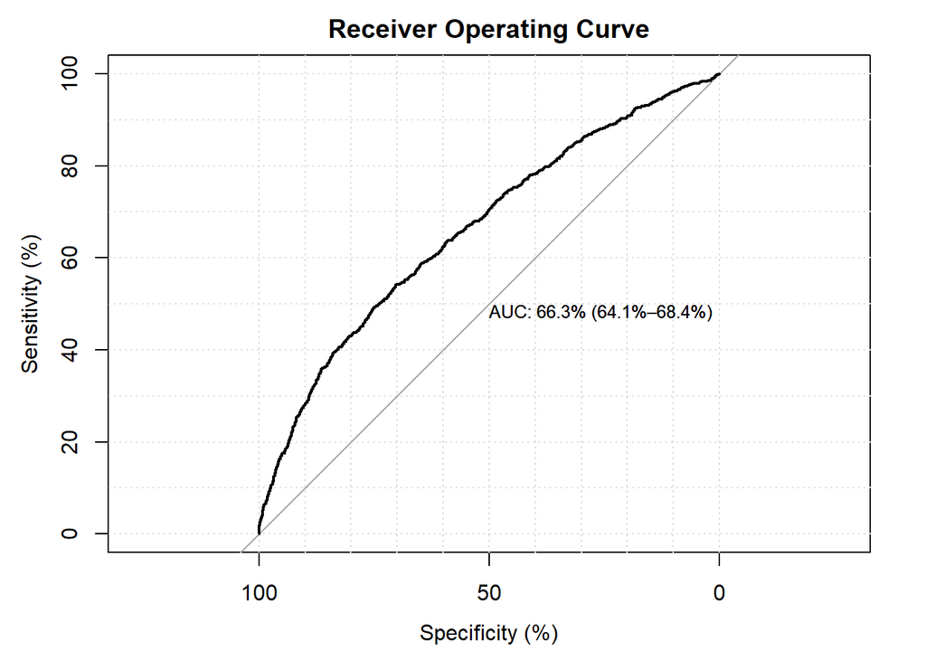

```
##          auc lower 95% CI upper 95% CI
##     66.27690     64.11134     68.44246
## attr(,"interpret")
## [1] "auc = 0.5       --> useless"   "0.7 < auc < 0.8 --> good"
## [3] "0.8 < auc < 0.9 --> excellent"
```

```r
gof(x = preliminary_final_model, lpotROC = TRUE)$auc
```

As reported above, AUROC of the preliminary final model is 66.3% (64.1%, 68.4%). The reported valyes being less than 70% is somewhat concerning, but the model may be adequate for some purposes.

## Logistic Regression diagnostics

### R2

We can compute the pseudo-$R^2$ statistic (the McFadden $R^2$ statistic from the DescTools package):

```r
PseudoR2(preliminary_final_model)
```

```
##   McFadden
## 0.05722328
```

Considering that this $R^2$ statistic is often quite small compared to those reported in linear regression, the value reported above does not necessarily indicate adequate fit. The model does not reach the threashold of 0.2, which has been described as a ‘moderately strong model’.

### AIC & BIC

```r
AIC(preliminary_final_model)
```

```
## [1] 4057.636
```

```r
BIC(preliminary_final_model)
```

```
## [1] 4149.132
```

These values can be used to compare to another candidate model using the same data. If such a model existed, a difference of three or more in AIC would be meaningful.

### Graphical Assessment

We can use the ‘plpt’ command from the LogisticDx package, including the change in chi-square residuals vs pi-hat, change in deviance vs pi-hat, change in beta vs pi-hat,change in chi-square residuals vs pi-hat:

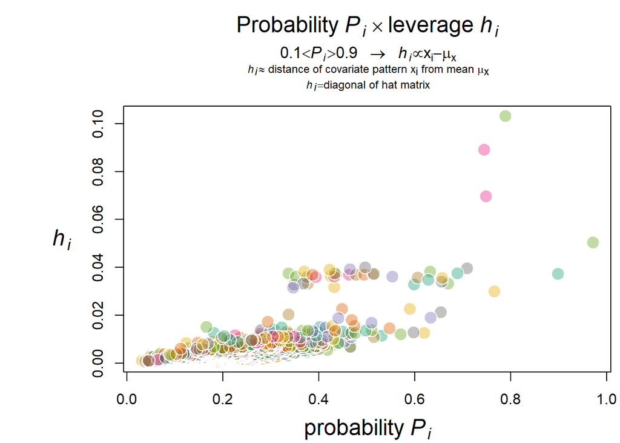

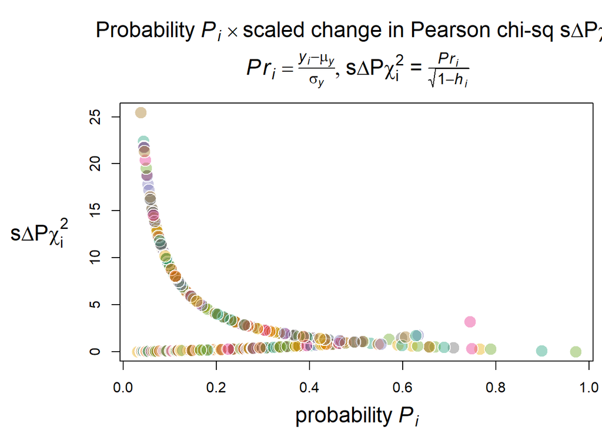

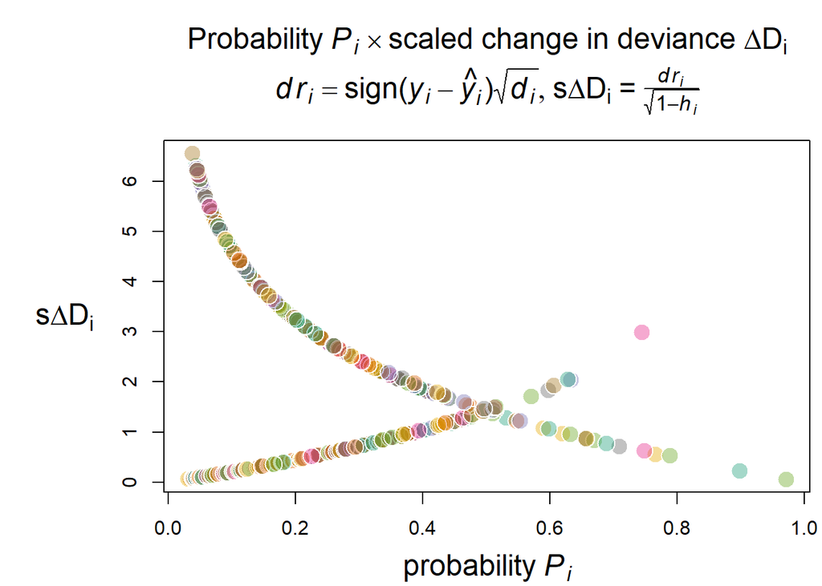

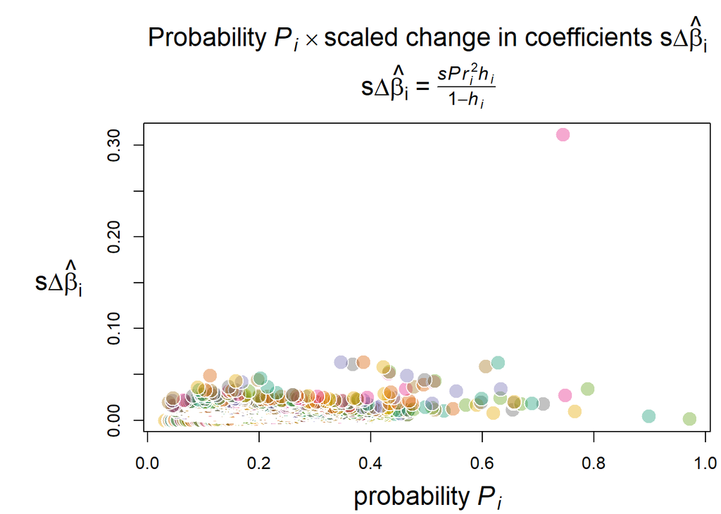

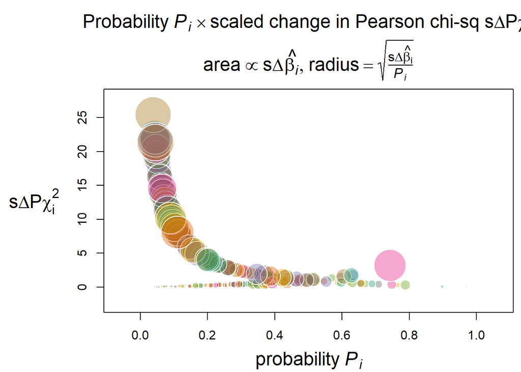

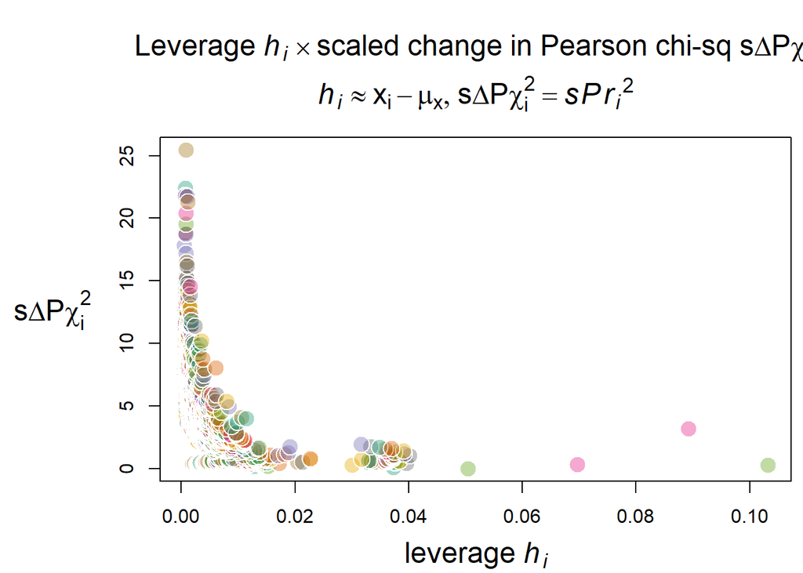

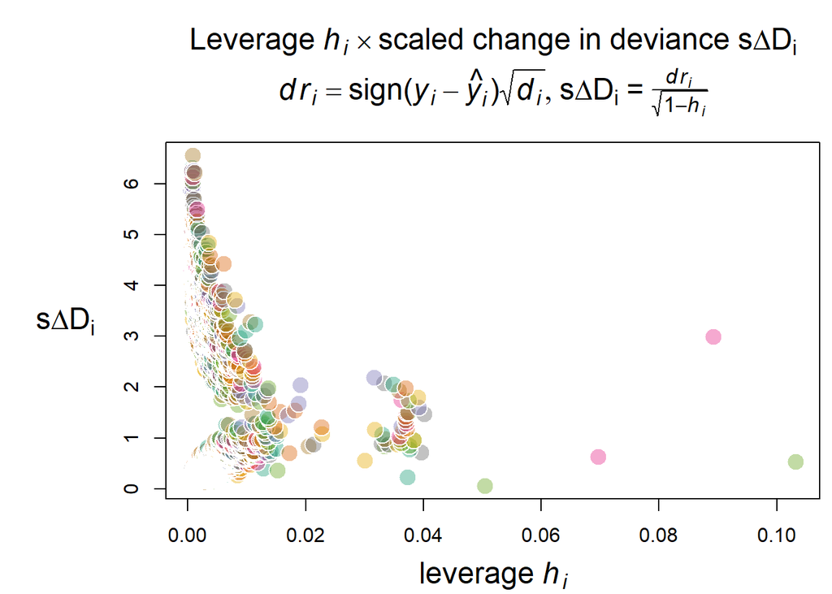

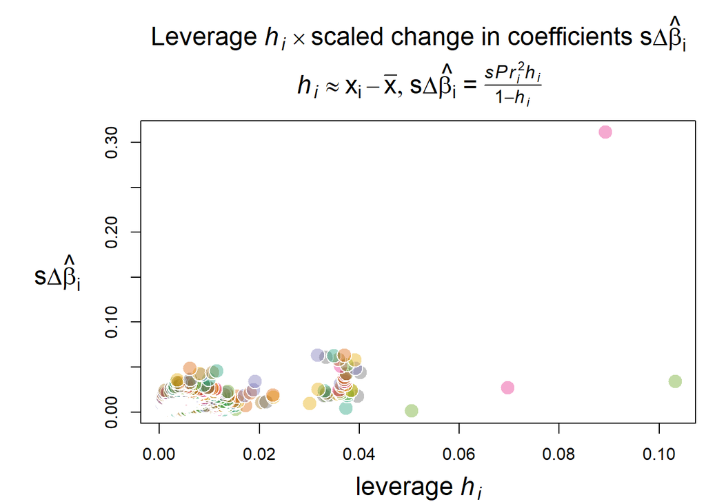

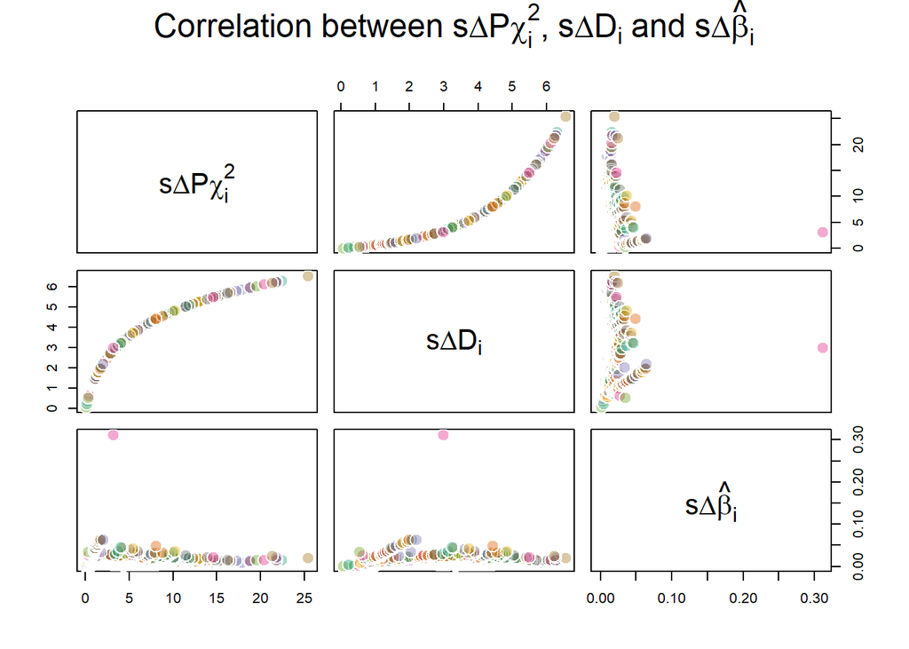

```r
plot(preliminary_final_model, devNew = FALSE)
```

This suggests one main result:

- The consistent presence of four outliers and one rather severe outlier in several of the plots suggests that their removal may improve the model.

### Numerical Assessment

The LogisticDx package provides the dx function for computing diagnostics of our logistic regression model. We will use this to look for influencial outliers; however our influencial outliers have a change in Pearson chi-sq closer to 15:

```r
diag <- dx(preliminary_final_model)
outlier <- diag[which(diag$h>0.05)]
outlier
```

```
##    (Intercept) giage1 mhstrk mhpark mhcopd mharth   pascore qlh    hwbmi
## 1:           1     75      0      0      0      1  40.21429   1 27.84372
## 2:           1     81      0      0      0      1 127.78571   0 37.87878
## 3:           1     73      0      0      0      1 136.00000   0 31.07845
## 4:           1     77      0      0      0      1 104.57143   1 33.23531
##    gsgrpavg inv_sq_walk     b1fnd  b1tbfkg  b1tblkg y         P n      yhat
## 1:     36.5   16.301406 0.8374081 20.40021 50.52593 1 0.9709247 1 0.9709247
## 2:     25.0    7.830669 1.0266128 27.23861 63.06787 1 0.7473776 1 0.7473776
## 3:     33.0    9.828225 0.6522009 28.16036 57.16411 1 0.7882817 1 0.7882817
## 4:     31.0    8.781344 0.7813811 18.13544 64.52979 0 0.7434641 1 0.7434641
##            Pr         dr          h        sPr        sdr     dChisq       dDev
## 1:  0.1730492  0.2429255 0.05036835  0.1775792  0.2492847 0.03153436 0.06214284
## 2:  0.5813878  0.7631314 0.06965246  0.6027585  0.7911826 0.36331776 0.62596988
## 3:  0.5182490  0.6897822 0.10319766  0.5472554  0.7283894 0.29948852 0.53055113
## 4: -1.7023775 -1.6495372 0.08919896 -1.7837916 -1.7284243 3.18191259 2.98745050
##          dBhat
## 1: 0.001672579
## 2: 0.027200561
## 3: 0.034463016
## 4: 0.311619436
```

```r
hoslem.test(step4_narm$falls, fitted(step5_model4), g=10)
```

```
##
##  Hosmer and Lemeshow goodness of fit (GOF) test
##
## data:  step4_narm$falls, fitted(step5_model4)
## X-squared = 13.908, df = 8, p-value = 0.0842
```

```r
PseudoR2(step5_model4)
```

```
##  McFadden
## 0.0563718
```

```r
AIC(step5_model4)
```

```
## [1] 4061.275
```

```r
BIC(step5_model4)
```

```
## [1] 4152.771
```

Although the AIC & BIC of this model are slightly better, the Hosmer-Lemeshow and pesudo-$R^2$ values are worse. We can proceed by completing the proposed censoring of observations above:

## Creating a new model with censored outliers

Censoring the outliers:

```r
step7_narm <- subset(step4_narm, id != 'PA3753')
step7_narm <- subset(step7_narm, id != 'PI5413')
step7_narm <- subset(step7_narm, id != 'PO7441')
step7_narm <- subset(step7_narm, id != 'PI5436')
```

Creating the censored model:

```r
step7_model1 <- glm(
  formula = falls ~ giage1 + mhstrk + mhpark + mhcopd + mharth +
    pascore + qlh + hwbmi + gsgrpavg + inv_sq_walk + b1fnd +
    b1tbfkg + b1tblkg,
  family = "binomial",
  data = step7_narm)

summary(step7_model1)$coef
```

```
##                 Estimate   Std. Error   z value     Pr(>|z|)
## (Intercept) -3.670468171 0.8630827296 -4.252742 2.111688e-05
## giage1       0.025699153 0.0081243470  3.163227 1.560307e-03
## mhstrk       0.311450873 0.1630566525  1.910078 5.612321e-02
## mhpark       1.600554604 0.3741526404  4.277812 1.887394e-05
## mhcopd       0.457077427 0.1205354113  3.792059 1.494032e-04
## mharth       0.384421000 0.0841813663  4.566581 4.957443e-06
## pascore      0.001193856 0.0006305183  1.893452 5.829782e-02
## qlh          0.315580723 0.1161938933  2.715984 6.607917e-03
## hwbmi       -0.076700285 0.0243744118 -3.146754 1.650936e-03
## gsgrpavg    -0.039625837 0.0062150523 -6.375785 1.820282e-10
## inv_sq_walk  0.346976688 0.1043442014  3.325309 8.832067e-04
## b1fnd        0.984188232 0.3382128419  2.909967 3.614668e-03
## b1tbfkg      0.045086242 0.0111614751  4.039452 5.357625e-05
## b1tblkg      0.019065542 0.0088366672  2.157549 3.096292e-02
```

### Checking the fit

For the above model, there are several continuous variables; therefore $J\approx n$, and therefor the assumptions of the Pearson and Deviance Residuals tests (i.e. that the test statistic follows a $\chi^2_{J-(p+1)}$ distribution) do not hold. Therefore we will use the Hosmer-Lemeshow approach, as implemented in the ResourceSelection package:

```r
n <- length(step7_narm$falls)
n1 <- sum(step7_narm$falls)
g <- max(10,min(n1/2, (n-n1)/2, 2+8^(n/1000)^2))
hoslem.test(step7_narm$falls, fitted(step7_model1), g=g)
```

```
##
##  Hosmer and Lemeshow goodness of fit (GOF) test
##
## data:  step7_narm$falls, fitted(step7_model1)
## X-squared = 403.09, df = 374, p-value = 0.1442
```

The moderate p-value reported above is adequately large, but only slightly better than that of the preliminary final. model. To assess the discriminative ability of the preliminary final model we can compute the AUROC:

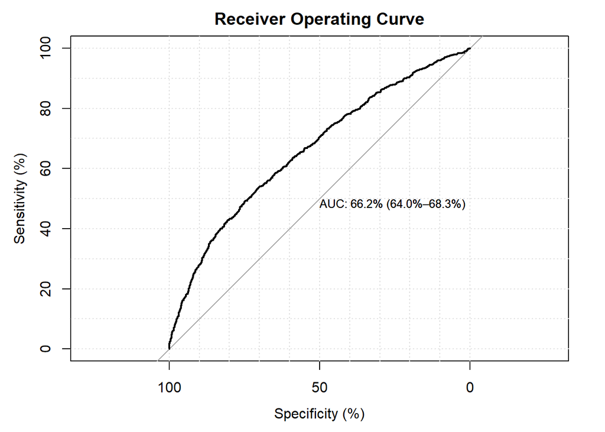

```
##          auc lower 95% CI upper 95% CI
##     66.15480     63.98589     68.32371
## attr(,"interpret")
## [1] "auc = 0.5       --> useless"   "0.7 < auc < 0.8 --> good"
## [3] "0.8 < auc < 0.9 --> excellent"
```

```r
gof(x = step7_model1, lpotROC = TRUE, g=g+1)$auc
```

We can compute the pseudo-$R^2$ statistic (the McFadden $R^2$ statistic from the DescTools package):

```r
PseudoR2(step7_model1)
```

```
##   McFadden
## 0.05552766
```

Considering that this $R^2$ statistic is often quite small compared to those reported in linear regression, the value reported above does not necessarily indicate adequate fit. The model does not reach the threashold of 0.2, which has been described as a ‘moderately strong model’. It is slightly worse than the $R^2$ for the previous model.

### AIC & BIC

```r
AIC(step7_model1)
```

```
## [1] 4053.755
```

```r
BIC(step7_model1)
```

```
## [1] 4145.24
```

### Graphical Assessment

We can use the ‘plot’ command from the LogisticDx package, including the change in chi-square residuals vs pi-hat, change in deviance vs pi-hat, change in beta vs pi-hat,change in chi-square residuals vs pi-hat:

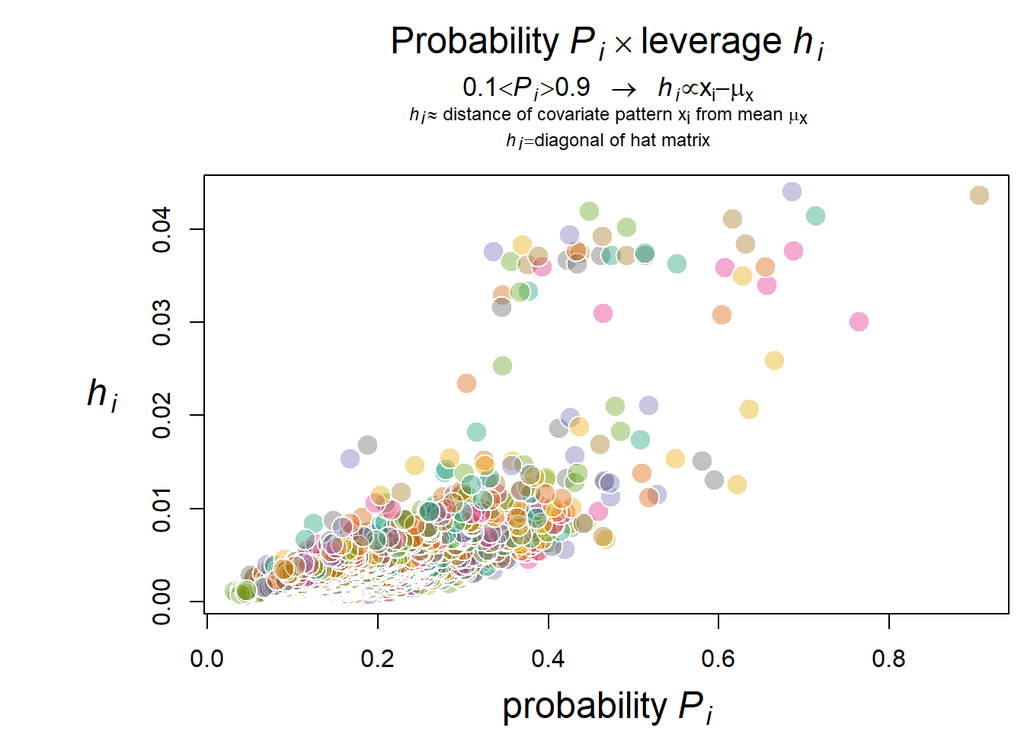

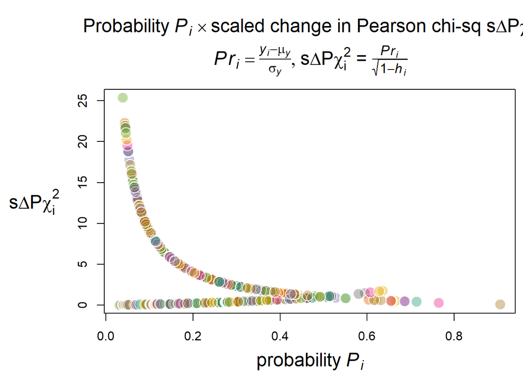

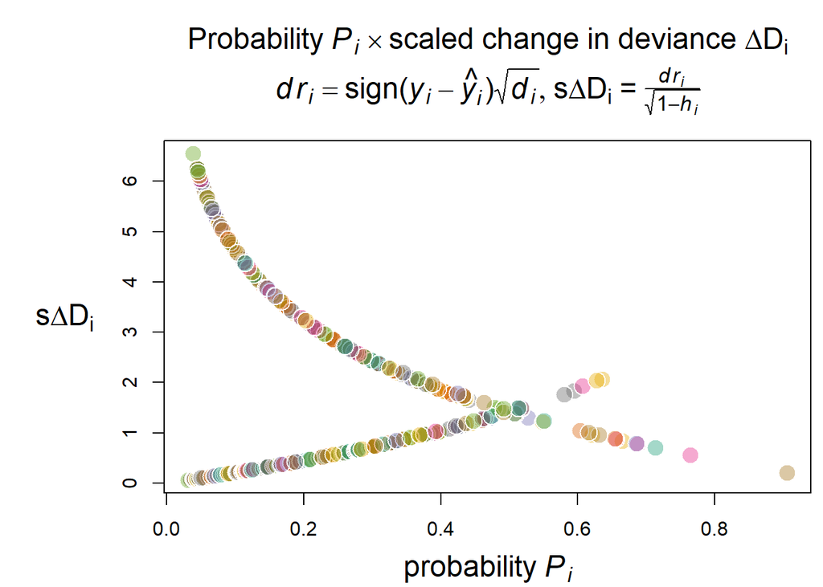

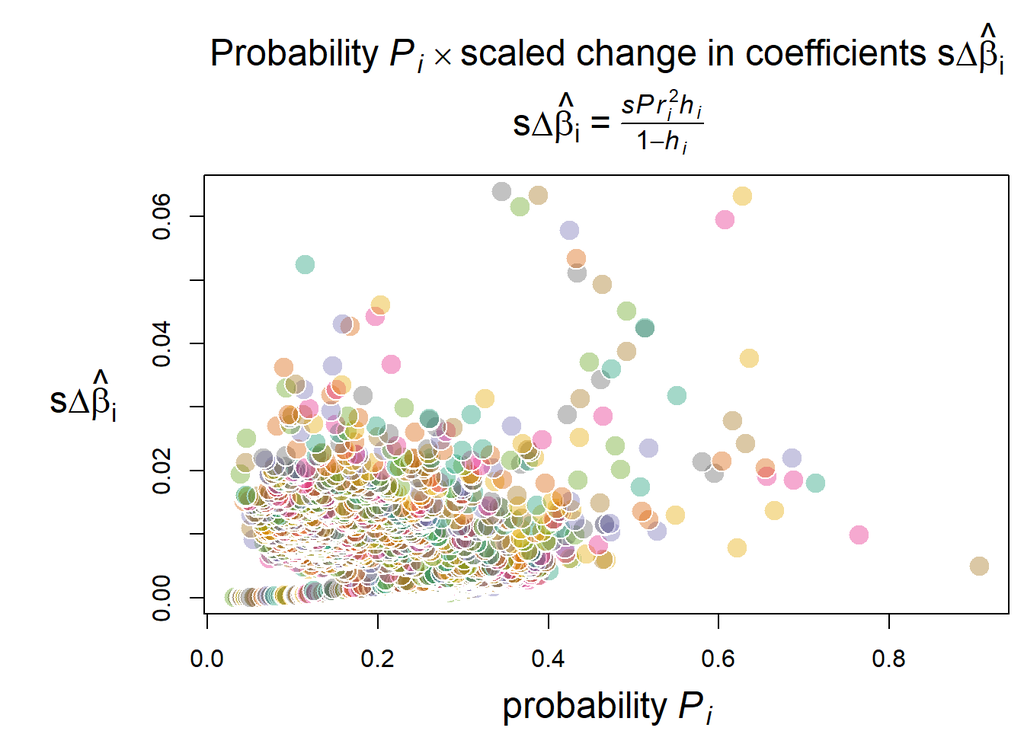

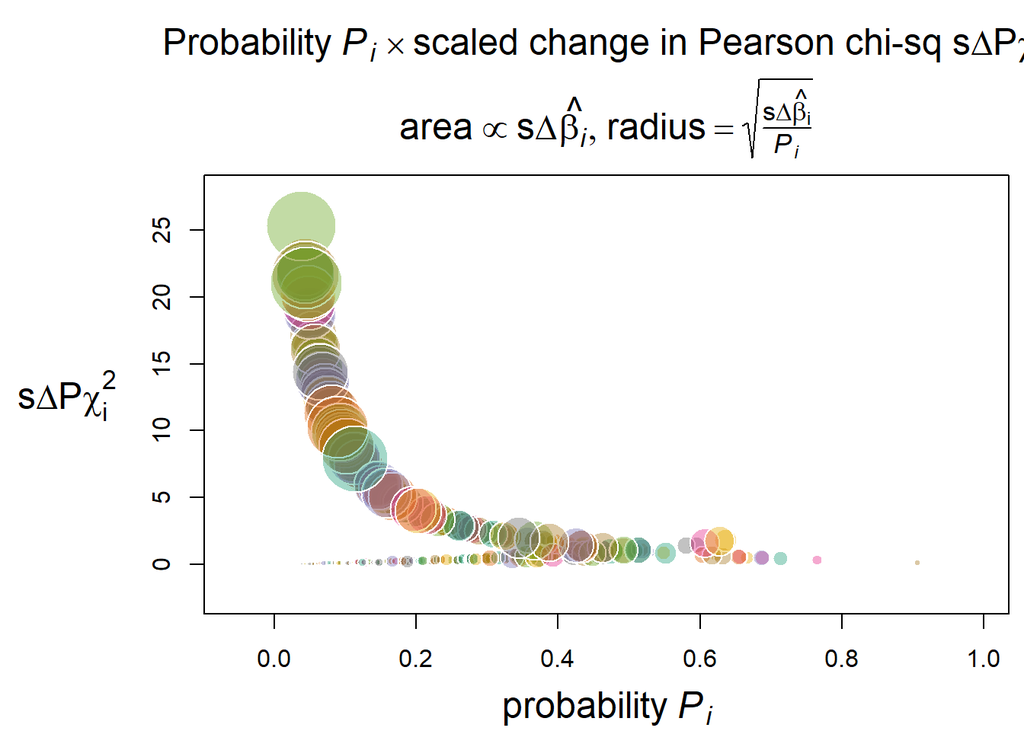

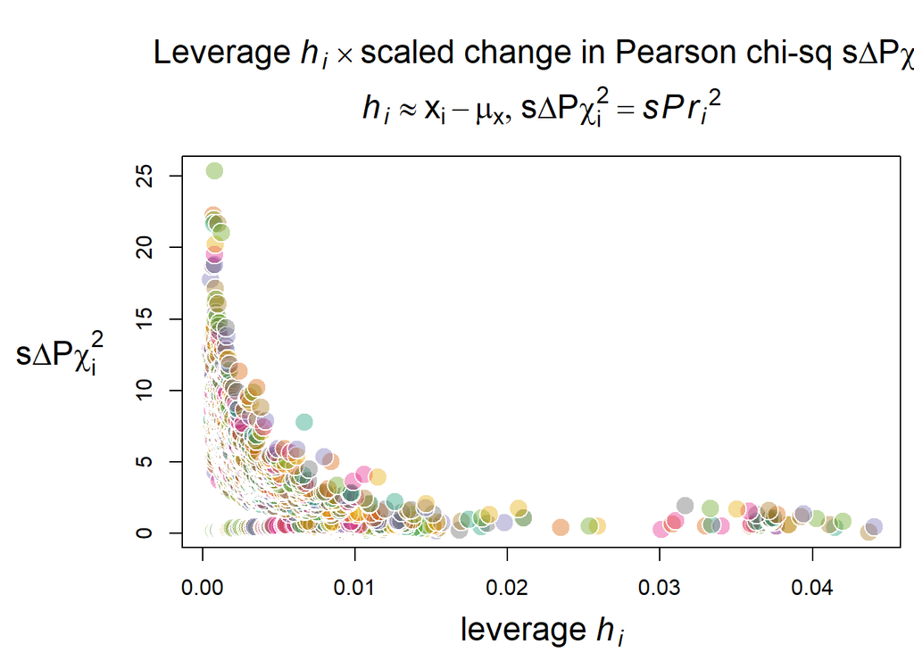

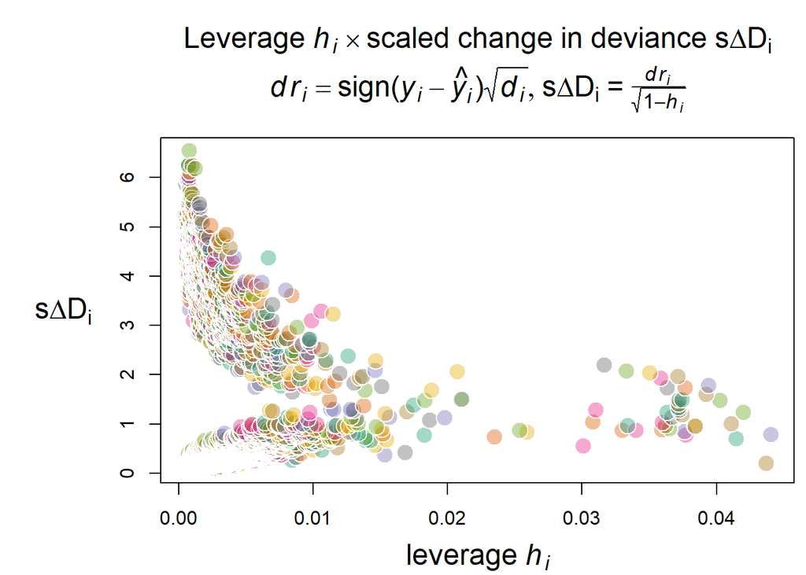

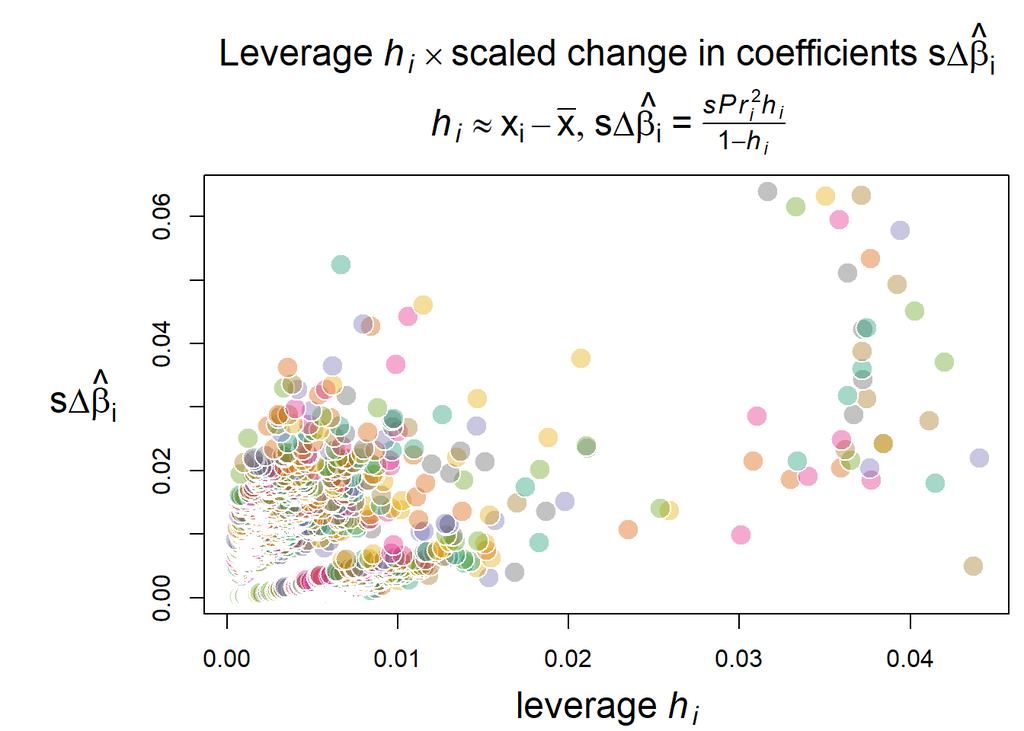

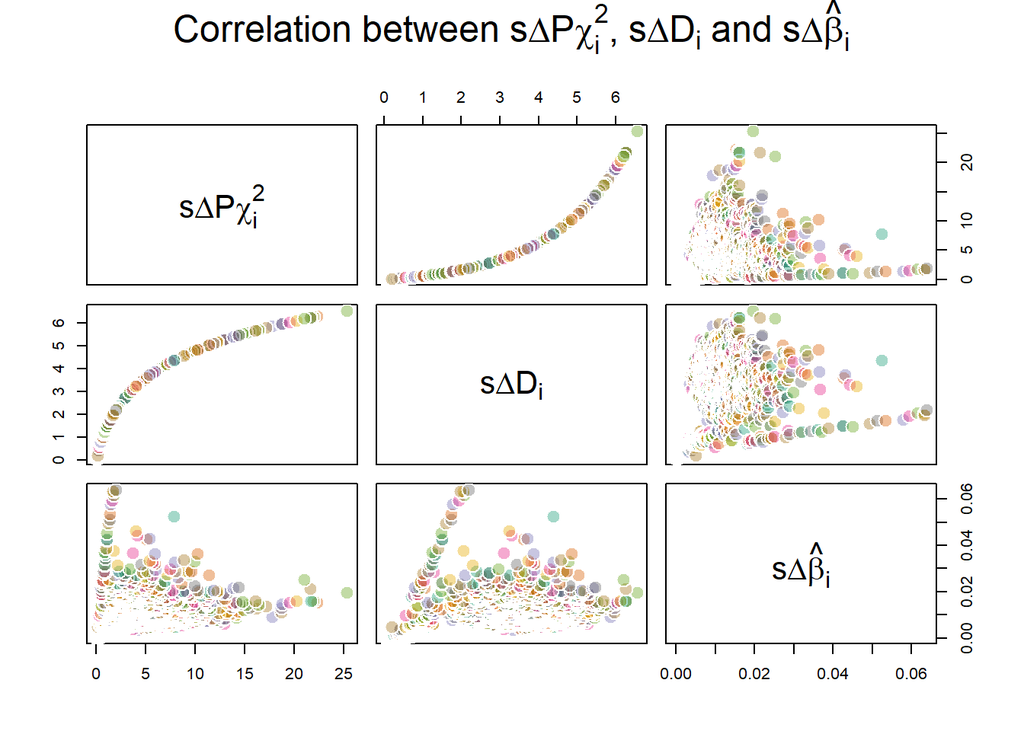

```r
plot(step7_model1, devNew = FALSE)
```

This suggests one main result:

- Outliers still exist in the dataset, but the ones with the strongest influence on the model have been removed.

### Numerical Assessment

The LogisticDx package provides the dx function for computing diagnostics of our logistic regression model. We will use this to look for influencial outliers; however our influencial outliers have a change in Pearson chi-sq closer to 15:

```r
diag <- dx(step7_model1)
outlier <- diag[which(diag$h>0.05)]
outlier
```

```
## Empty data.table (0 rows and 26 cols): (Intercept),giage1,mhstrk,mhpark,mhcopd,mharth...
```

This shows that no new outliers have arisen after changes to the model after removing influencial outliers.

## Final Model

The model with outliers removed does not perform substantially better than the previous model. Therefore we can use the preliminary final model as the final model:

```r
final_model <- preliminary_final_model
```

# Results

## Betas for final model

```r
tbl_regression(final_model,
               label = list(giage1 ~ "Age"
#                            ,mhdiab ~ "Diabetes"
                            ,mhstrk ~ "Stroke"
                            ,mhpark ~ "Parkinsons"
                            ,mhcopd ~ "COPD"
                            ,mharth ~ "Arthritis or Gout"
#                            ,mhcancer ~ "Cancer"
                            ,pascore ~ "PASE Score"
                            ,qlh ~ "Subjective Health Rating"
                            ,hwbmi ~ "Body Mass Index"
                            ,b1tbfkg ~ "Total Body Fat"
                            ,b1tblkg ~ "Lean Body Mass"
                            ,gsgrpavg ~ "Average Grip Strength"
                            ,inv_sq_walk ~ "Inverse Square Walking Speed"
                            ,b1fnd ~ "Corrected Femoral Neck BMD"
                            ),
               exponentiate = FALSE)
```

| **Characteristic** | **log(OR)**<sup>1</sup> | **95% CI**<sup>1</sup> | **p-value** |
| --- | --- | --- | --- |
| Age | 0.03 | 0.01, 0.04 | 0.001 |
| Stroke | 0.31 | -0.01, 0.63 | 0.053 |
| Parkinsons | 1.6 | 0.87, 2.3 | <0.001 |
| COPD | 0.46 | 0.22, 0.69 | <0.001 |
| Arthritis or Gout | 0.39 | 0.22, 0.55 | <0.001 |
| PASE Score | 0.00 | 0.00, 0.00 | 0.059 |
| Subjective Health Rating | 0.31 | 0.08, 0.53 | 0.007 |
| Body Mass Index | -0.08 | -0.13, -0.03 | 0.001 |
| Average Grip Strength | -0.04 | -0.05, -0.03 | <0.001 |
| Inverse Square Walking Speed | 0.33 | 0.17, 0.51 | <0.001 |
| Corrected Femoral Neck BMD | 1.0 | 0.33, 1.7 | 0.003 |
| Total Body Fat | 0.05 | 0.02, 0.07 | <0.001 |
| Lean Body Mass | 0.02 | 0.00, 0.04 | 0.034 |

<sup>*1*</sup> OR = Odds Ratio, CI = Confidence Interval

## OR Calculate all of them

```r
tbl_regression(final_model,
               label = list(giage1 ~ "Age"
#                            ,mhdiab ~ "Diabetes"
                            ,mhstrk ~ "Stroke"
                            ,mhpark ~ "Parkinsons"
                            ,mhcopd ~ "COPD"
                            ,mharth ~ "Arthritis or Gout"
#                            ,mhcancer ~ "Cancer"
                            ,pascore ~ "PASE Score"
                            ,qlh ~ "Subjective Health Rating"
                            ,hwbmi ~ "Body Mass Index"
                            ,b1tbfkg ~ "Total Body Fat"
                            ,b1tblkg ~ "Lean Body Mass"
                            ,gsgrpavg ~ "Average Grip Strength"
                            ,inv_sq_walk ~ "Inverse Square Walking Speed"
                            ,b1fnd ~ "Corrected Femoral Neck BMD"
                            ),
               exponentiate = TRUE)
```

| **Characteristic** | **OR**<sup>1</sup> | **95% CI**<sup>1</sup> | **p-value** |
| --- | --- | --- | --- |
| Age | 1.03 | 1.01, 1.04 | 0.001 |
| Stroke | 1.37 | 0.99, 1.87 | 0.053 |
| Parkinsons | 5.00 | 2.38, 10.4 | <0.001 |
| COPD | 1.58 | 1.25, 2.00 | <0.001 |
| Arthritis or Gout | 1.47 | 1.25, 1.73 | <0.001 |
| PASE Score | 1.00 | 1.00, 1.00 | 0.059 |
| Subjective Health Rating | 1.36 | 1.08, 1.71 | 0.007 |
| Body Mass Index | 0.93 | 0.88, 0.97 | 0.001 |
| Average Grip Strength | 0.96 | 0.95, 0.97 | <0.001 |
| Inverse Square Walking Speed | 1.39 | 1.18, 1.66 | <0.001 |
| Corrected Femoral Neck BMD | 2.70 | 1.39, 5.22 | 0.003 |
| Total Body Fat | 1.05 | 1.02, 1.07 | <0.001 |
| Lean Body Mass | 1.02 | 1.00, 1.04 | 0.034 |

<sup>*1*</sup> OR = Odds Ratio, CI = Confidence Interval

## Table 1 patient characteristics

```r
MrOs_check <- MrOs %>%  # why did this break?
    dplyr::select(falls, giage1, mhstrk, mhpark, mhcopd, mharth, pascore, qlh, hwbmi, gsgrpavg, nfwlkspd, b1fnd, b1tbfkg, b1tblkg)
MrOs_check$censored <- complete.cases(MrOs_check)
MrOs_check$censored2 <- ifelse(MrOs_check$censored == FALSE, "Excluded", "Included")
#MrOs$censored <- ifelse(MrOs$mhfalln2 == NA,1,0)
#sum(MrOs$censored)
#tbl_summary(step7_narm)
```

```r
MrOs_check %>%  # why did this break?
    dplyr::select(falls, giage1, mhstrk, mhpark, mhcopd, mharth, pascore, qlh, hwbmi, gsgrpavg, nfwlkspd, b1fnd, b1tbfkg, b1tblkg, censored2)%>%
    tbl_summary(by = censored2, missing = "no",
    statistic = list(all_continuous() ~ "{mean}",
                     all_categorical() ~ "{n} / {N} ({p}%)"),
    label = list(falls ~ "More than one fall"
                 ,giage1 ~ "Age"
                 ,mhstrk ~ "Stroke"
                 ,mhpark ~ "Parkinsons"
                 ,mhcopd ~ "COPD"
                 ,mharth ~ "Arthritis or Gout"
                 ,pascore ~ "PASE Score"
                 ,qlh ~ "Subjective Health Rating"
                 ,hwbmi ~ "Body Mass Index"
                 ,gsgrpavg ~ "Average Grip Strength"
                 ,nfwlkspd ~ "Walking Speed"
                 ,b1fnd ~ "Corrected Femoral Neck BMD"
                 ,b1tbfkg ~ "Total Body Fat"
                 ,b1tblkg ~ "Lean Body Mass"
    ),
    ) %>% add_p() %>% add_overall() %>%
  modify_caption("**Table 1. Patient Characteristics**") %>%
  bold_labels()
```

**Table 1. Patient Characteristics**

| **Characteristic** | **Overall**, N = 5,994<sup>1</sup> | **Excluded**, N = 902<sup>1</sup> | **Included**, N = 5,092<sup>1</sup> | **p-value**<sup>2</sup> |
| --- | --- | --- | --- | --- |
| More than one fall | 786 / 5,224 (15%) | 31 / 132 (23%) | 755 / 5,092 (15%) | 0.006 |
| Age | 73.7 | 76.6 | 73.1 | <0.001 |
| Stroke | 344 / 5,994 (5.7%) | 88 / 902 (9.8%) | 256 / 5,092 (5.0%) | <0.001 |
| Parkinsons | 52 / 5,994 (0.9%) | 20 / 902 (2.2%) | 32 / 5,092 (0.6%) | <0.001 |
| COPD | 640 / 5,994 (11%) | 142 / 902 (16%) | 498 / 5,092 (9.8%) | <0.001 |
| Arthritis or Gout | 2,847 / 5,994 (47%) | 494 / 902 (55%) | 2,353 / 5,092 (46%) | <0.001 |
| PASE Score | 146 | 126 | 150 | <0.001 |
| Subjective Health Rating | 857 / 5,992 (14%) | 245 / 900 (27%) | 612 / 5,092 (12%) | <0.001 |
| Body Mass Index | 27.4 | 27.1 | 27.4 | <0.001 |
| Average Grip Strength | 39 | 34 | 39 | <0.001 |
| Walking Speed | 1.20 | 1.09 | 1.22 | <0.001 |
| Corrected Femoral Neck BMD | 0.78 | 0.76 | 0.79 | <0.001 |
| Total Body Fat | 22 | 21 | 22 | <0.001 |
| Lean Body Mass | 57 | 55 | 57 | <0.001 |

<sup>*1*</sup> n / N (%); Mean <sup>*2*</sup> Pearson's Chi-squared test; Wilcoxon rank sum test

Calculate p-values for differences between outcomes in each exposure group

# References

1. Hothorn T, Zeileis A, Farebrother (pan.f) RW, Cummins (pan.f) C, Millo G, Mitchell D. Lmtest: Testing Linear Regression Models.; 2020. Accessed April 30, 2021. https://CRAN.R-project.org/package=lmtest
2. Hu B, Shao J, Palta M. PSEUDO-R2 IN LOGISTIC REGRESSION MODEL. :14.
3. Signorell A. Tools for Descriptive Statistics [R Package DescTools Version 0.99.41]. Comprehensive R Archive Network (CRAN); 2021. Accessed June 6, 2021. https://CRAN.R-project.org/package=DescTools
4. Sjoberg D. Gtsummary: Presentation-Ready Data Summary and Analytic Result Tables [R Package Gtsummary Version 1.4.1]. Comprehensive R Archive Network (CRAN); 2021. Accessed May 20, 2021. https://CRAN.R-project.org/package=gtsummary
5. Solymos P, Keim J, Lele S. Resource Selection (Probability) Functions for Use-Availability Data [R Package ResourceSelection Version 0.3-5]. Comprehensive R Archive Network (CRAN); 2019. Accessed June 6, 2021. https://CRAN.R-project.org/package=ResourceSelection
[^1]: OHSU-PSU School of Public Health
[^2]: OHSU-PSU School of Public Health
[^3]: OHSU-PSU School of Public Health
[^4]: OHSU-PSU School of Public Health
[^5]: OHSU-PSU School of Public Health